# EcoTox - ToMEx 2

Scott Coffin

2026-11-04

#Setup

This markdown script produces (nearly) all of the figures, tables, and data in the Coffin et al. (2025) publication. Before running this script, ensure that the ‘scripts/monte carlo/EcoTox_MonteCarlo.Rmd’ script has first been run. That script produces the monte-carlo aligned dataset, which is used in the PSSD++ code below. I have separated these two scripts due to the massive amount of time that the other script takes to run. Due to the size of the dataset produced (>100 MB), it is not feasible to upload that to Github, so the user will need to run this locally if they would like to recreate the analysis in the publication.

## 0.1 Libraries

```r
source("utils/functions.R")
source("utils/vivo_functions.R") # ssd_eligible(): in vitro records never reach an SSD
source("utils/alignment_functions.R")
```

```
## Alignment function and dependencies loaded!
```

### 0.1.1 Data Import

### 0.1.2 Data Cleanup

A large number of values is getting filtered out during alignments. This should not be the case. We can debug by looking at missing values for the parameters that are relevant to alignments.

```r
aoc_simple <- aoc_z %>%
   filter(!environment %in% c("Terrestrial", "Not Reported"),
         Group != "Bacterium",
         Group != "Plant",
         effect.metric != "HONEC",
         exp_type_f == "Particle Only",
         tier_zero_tech_f == "Red Criteria Passed",
         tier_zero_risk_f == "Red Criteria Passed", #All thresholds must pass technical and risk red criteria
         risk.13 != 0 #Drop studies that received a score of 0 for endpoints criteria (this also drops studies that have not yet been scored) - KEEP THIS AFTER THE RED CRITERIA FILTERS
         ) %>%
  ungroup()

# for polydisperse data, we need the particle.surface.area.um2.min and max to be filled out. For monodisperse data, just the particle.surface.area.um2 is needed.

aoc_simple_check <- aoc_simple %>%
   mutate(data_available = case_when(
    # Condition for polydisperse: particle.surface.area.um2.min and .max cannot be NA
    polydispersity == "polydisperse" & !is.na(particle.surface.area.um2.min) & !is.na(particle.surface.area.um2.max) ~ TRUE,
    # Condition for monodisperse: particle.surface.area.um2 cannot be NA
    polydispersity == "monodisperse" & !is.na(particle.surface.area.um2) ~ TRUE,
    # Otherwise, data is not available according to the criteria
    TRUE ~ FALSE
  )) %>%
  drop_na(dose.particles.mL.master)

aoc_simple_check %>%
  filter(!data_available)
```

```
## # A tibble: 2 × 187
##   rowid       source doi   article fed   tech.a1 tech.a2 tech.a3 tech.a4 tech.a5
##   <chr>       <fct>  <chr>   <dbl> <fct>   <dbl>   <dbl>   <dbl>   <dbl>   <dbl>
## 1 c199436c-8… ToMEx… 10.1…     165 Yes         2       2       2       2       2
## 2 e40f864a-9… ToMEx… 10.1…     165 Yes         2       2       2       2       2
## # ℹ 177 more variables: tech.a6 <dbl>, tech.1 <dbl>, tech.2 <dbl>,
## #   tech.3 <dbl>, tech.4 <dbl>, tech.5 <dbl>, tech.6 <dbl>, tech.7 <dbl>,
## #   tech.8 <dbl>, tech.9 <dbl>, tech.10 <dbl>, tech.11 <dbl>, tech.12 <dbl>,
## #   risk.b1 <dbl>, risk.13 <dbl>, risk.14 <dbl>, risk.15 <dbl>, risk.16 <dbl>,
## #   risk.17 <dbl>, risk.18 <dbl>, risk.19 <dbl>, risk.20 <dbl>,
## #   technical.quality <dbl>, risk.quality <dbl>, authors <chr>, year <dbl>,
## #   Species <fct>, Group <fct>, environment <fct>, life_f <fct>, …
```

# 1 ERM/SSD Calculations

The following script utilizes the above equations to calculate *a priori* effect thresholds for each of the ERM of interest for each species in the database, then calculates species sensitivity distributions using each ERM.

*Data Filtering by Quality*

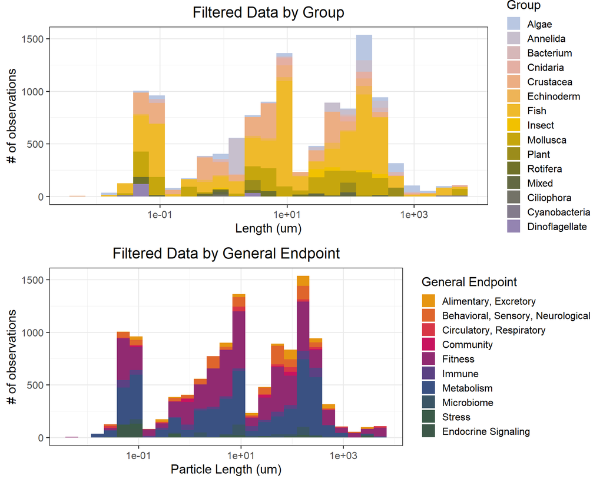

```r
## First filter data with global filters
aoc_intermediate <- aoc_z %>%
  #Remove 26C temperature treatment data from Jaimukar et al. 2018
  filter(!(article == 42 & media.temp == 26)) %>%
  mutate(max.size.ingest.um = 1000 * max.size.ingest.mm) #makes it less confusing below


#### Ecologically Relevant Metric calculations ####
#examine available data as histogram
Group_size <- aoc_intermediate %>%
  ggplot(aes(x = size.length.um.used.for.conversions, fill = Group)) +
  geom_histogram(bins = 25) +
  scale_fill_manual(values = cal_palette(name = "superbloom1", type = "continuous", n = 15)) +
  labs(title = "Filtered Data by Group") +
  ylab("# of observations")+
  xlab("Length (um)") +
  theme.type +
  scale_x_log10()

endpoint_size <- aoc_intermediate %>%
  ggplot(aes(x = size.length.um.used.for.conversions, fill = lvl1_f)) +
  geom_histogram(bins = 25) +
   scale_fill_manual(name = "General Endpoint", values = cal_palette(name = "superbloom3", type = "continuous", n = 15)) +
  xlab("Particle Length (um)") +
  ylab("# of observations")+
  labs(title = "Filtered Data by General Endpoint") +
  theme.type +
  scale_x_log10()

#arrange histograms
grid.arrange(Group_size, endpoint_size)
```

### 1.0.1 Alignment

#### 1.0.1.1 Parameters

```r
R.ave.water.marine <- 0.77 # average length to width ratio of microplastics in marine environment (Kooi et al. 2021)
H_W_ratio.water.marine = 0.77 # H:W ratio across all environments/particle types
R.ave.water.freshwater <- 0.67 # average length to width ratio of microplastics in freshwater environment (Kooi et al. 2021)
H_W_ratio.water.freshwater = 0.67 # H:W ratio across all environments/particle types
R.ave.sediment.marine <- 0.75 # average length to width ratio of microplastics in marine environment (Kooi et al. 2021)
H_W_ratio.sediment.marine = 0.75 # H:W ratio across all environments/particle types
R.ave.sediment.freshwater <- 0.70 # average length to width ratio of microplastics in freshwater environment (Kooi et al.
# 2021)
H_W_ratio.sediment.freshwater = 0.70 # H:W ratio across all environments/particle types

p.ave.marine = 1.10 #average density in marine surface water
alpha.marine = 2.07 #table s4 for marine surface water. length
a.sa.marine = 1.50 #marine surface area power law
a.v.marine = 1.48 #a_V for marine surface water volume
a.m.marine = 1.32 # upper limit fora_m for mass for marine surface water in table S4
a.ssa.marine = 1.98 # A_SSA for marine surface water

p.ave.freshwater = 1.04 #average density in freshwater surface water
alpha.freshwater = 2.64 #table s4 for freshwater surface water. length
a.sa.freshwater = 2.00 #freshwater surface area power law
a.v.freshwater = 1.68 #a_V for freshwater surface water volume
a.m.freshwater = 1.65 # upper limit fora_m for mass for freshwater surface water in table S4
a.ssa.freshwater = 2.71 # A_SSA for freshwater surface water

beta_log10_body_length = 0.9341 # Jâms, et al 2020 Nature paper
body_length_intercept = 1.1200 # Jâms, et al 2020 Nature paper

#join alpha values for each data point
aoc_intermediate_alphas <- aoc_intermediate %>%
   # define environment-specific alpha parameters #
    mutate(alpha = case_when(environment == "Marine" ~ alpha.marine,
                             environment == "Freshwater" ~ alpha.freshwater),
           a.sa = case_when(environment == "Marine" ~ a.sa.marine,
                            environment == "Freshwater" ~ a.sa.freshwater),
           a.v = case_when(environment == "Marine" ~ a.v.marine,
                            environment == "Freshwater" ~ a.v.freshwater),
           a.m = case_when(environment == "Marine" ~ a.m.marine,
                           environment == "Freshwater" ~ a.m.freshwater),
           a.ssa = case_when(environment == "Marine" ~ a.ssa.marine,
                           environment == "Freshwater" ~ a.ssa.freshwater),
           R.ave = case_when(environment == "Marine" ~ R.ave.water.marine,
                             environment == "Freshwater" ~ R.ave.water.freshwater),
           H_W_ratio = case_when(environment == "Marine" ~ H_W_ratio.water.marine,
                             environment == "Freshwater" ~ H_W_ratio.water.freshwater),
           p.ave = case_when(environment == "Marine" ~ p.ave.marine,
                             environment == "Freshwater" ~ p.ave.freshwater)
           )
```

#### 1.0.1.2 Functions

```r
###function to derive correction factor (CF) from Koelmans et al (equation 2)
CFfnx = function(a, #default alpha from Koelmans et al (2020)
                 x2D, #set detault values to convert ranges to (1-5,000 um) #5mm is upper defuault
                 x1D, #1 um is lower default size
                 x2M, x1M){
  CF = (x2D^(1-a)-x1D^(1-a))/(x2M^(1-a)-x1M^(1-a))
  return(CF)}

#### equations for mu_x_poly (note that there are three depending on certain alphas for limits of equation)
mux_polyfnx<- function(a.x, x_UL, x_LL) {
  # Validate inputs
  if (length(a.x) != length(x_UL) || length(a.x) != length(x_LL)) {
    stop("a.x, x_UL, and x_LL must have the same length.")
  }

  # Initialize result vector
  mux.poly <- numeric(length(a.x))

  # Loop through each element to handle row-by-row logic
  for (i in seq_along(a.x)) {
    if (is.na(a.x[i]) || is.na(x_UL[i]) || is.na(x_LL[i])) {
      # Handle NA values
      mux.poly[i] <- NA
    } else if (a.x[i] == 1) {
      # Special case: a.x == 1
      if (x_UL[i] > 0 && x_LL[i] > 0) {
        mux.poly[i] <- (x_UL[i] - x_LL[i]) / log(x_UL[i] / x_LL[i])
      } else {
        mux.poly[i] <- NA  # Invalid input for log
      }
    } else if (a.x[i] == 2) {
      # Special case: a.x == 2
      epsilon <- 1e-10  # Small value to avoid division by zero
      if (x_UL[i] > 0 && x_LL[i] > 0) {
        mux.poly[i] <- log(x_UL[i] / x_LL[i]) /
          ((x_LL[i] + epsilon)^-1 - (x_UL[i] + epsilon)^-1)
      } else {
        mux.poly[i] <- NA  # Invalid input for log
      }
    } else {
      # General case: a.x != 1 and a.x != 2
      if (x_UL[i] > 0 && x_LL[i] > 0) {
        mux.poly[i] <- ((1 - a.x[i]) / (2 - a.x[i])) *
          ((x_UL[i]^(2 - a.x[i]) - x_LL[i]^(2 - a.x[i])) /
             (x_UL[i]^(1 - a.x[i]) - x_LL[i]^(1 - a.x[i])))
      } else {
        mux.poly[i] <- NA  # Invalid input for power calculations
      }
    }
  }

  # Return the result
  return(mux.poly)
}

#max ingestible specific surface area
SSAfnx = function(sa, #surface area, calcaulted elsewhere
                  m){ #mass, calculated elsewhere
  SSA = sa/m
    return(SSA)}

#max ingestible specific surface area
SSA.inversefnx = function(sa, #surface area, calcaulted elsewhere
                  m){ #mass, calculated elsewhere
  SSA.inverse = m / sa
    return(SSA.inverse)}
```

#### 1.0.1.3 Calculate

```r
align_data <- function(df,
                       x1M_set_input = 1, #um lower size for all alignments
                       x1D_set_input = 1, #um lower size for all alignments
                       x2D_set_input = 5000, #um
                       upper.tissue.trans.size.um_input = 88,
                       R.ave.marine_input = 0.77, # average length to width ratio of microplastics in marine environment (Kooi et al. 2021)
                       H_W_ratio.marine_input = 0.77, # H:W ratio assumed same as width:length ratio (Kooi et al. 2021)
                       R.ave.freshwater_input = 0.67, # average length to width ratio of microplastics in freshwater environment (Kooi et al. 2021)
                       H_W_ratio.freshwater_input = 0.67, # H:W ratio assumed same as width:length ratio (Kooi et al. 2021)
                       R.ave.sediment.marine_input = 0.75, # average length to width ratio of microplastics in marine environment (Kooi et al. 2021)
                       R.ave.sediment.freshwater_input = 0.70, # average length to width ratio of microplastics in freshwater environment (Kooi et al. 2021)
                       p.ave.marine_input = 1.10, #average density in marine surface water
                       alpha.marine_input = 2.07, #table s4 for marine surface water. length
                       a.sa.marine_input = 1.50, #marine surface area power law
                       a.v.marine_input = 1.48, #a_V for marine surface water volume
                       a.m.marine_input = 1.32, # upper limit fora_m for mass for marine surface water in table S4
                       a.ssa.marine_input = 1.98, # A_SSA for marine surface water
                       p.ave.freshwater_input = 1.04, #average density in freshwater surface water
                       alpha.freshwater_input = 2.64, #table s4 for freshwater surface water. length
                       a.sa.freshwater_input = 2.00, #freshwater surface area power law
                       a.v.freshwater_input = 1.68, #a_V for freshwater surface water volume
                       a.m.freshwater_input = 1.65, # upper limit fora_m for mass for freshwater surface water in table S4
                       a.ssa.freshwater_input = 2.71, # A_SSA for freshwater surface water
                       beta_log10_body_length_input = 0.9341, # Jâms, et al 2020 Nature paper
                       body_length_intercept_input = 1.1200, # Jâms, et al 2020 Nature paper
                       particle_count_source = c("mass", "database") # mass-dosed tests (0.4.1)
                       ){ #10 #um #set size for x2M)
  particle_count_source <- match.arg(particle_count_source)

  # Check if columns exist and conditionally create them
    if (!"dose.mg.kg.sed.measured" %in% names(df)) {
      df <- df %>%
        mutate(dose.mg.kg.sed.measured = measured.dose.mg.kg.sediment)
    }

  if (!"dose.mg.kg.sed.nominal" %in% names(df)) {
    df <- df %>%
      mutate(dose.mg.kg.sed.nominal = nominal.dose.mg.kg.sediment)
  }

  if (!"dose.particles.kg.sed.nominal" %in% names(df)) {
    df <- df %>%
      mutate(dose.particles.kg.sed.nominal = nominal.dose.particles.kg.sediment)
  }

  if (!"environment" %in% names(df)){
    df <- df %>%
      mutate(environment = env_f)
    }

  # dose columns used to recompute particle counts of mass-dosed tests
  for (col in c("dose.mg.L.master", "density.g.cm3")) {
    if (!col %in% names(df)) df[[col]] <- NA_real_
  }
  if (!"dose.particles.mL.master.converted.reported" %in% names(df)) {
    df$dose.particles.mL.master.converted.reported <- NA_character_
  }
  # reported particle widths (mm), used for fiber diameters
  for (col in c("size.width.min.mm.measured", "size.width.min.mm.nominal",
                "size.width.max.mm.measured", "size.width.max.mm.nominal")) {
    if (!col %in% names(df)) df[[col]] <- NA_real_
  }

  df <- df %>%
    ungroup() %>%  #if data grouped - bad things happen
    #assign user  input values
    mutate(x1M_set = x1M_set_input,
           x1D_set = x1D_set_input,
           x2D_set = x2D_set_input,
           upper.tissue.trans.size.um  = upper.tissue.trans.size.um_input,
           beta_log10_body_length = beta_log10_body_length_input,
           body_length_intercept = body_length_intercept_input,
           H_W_ratio.marine = H_W_ratio.marine_input,
           H_W_ratio.freshwater = H_W_ratio.freshwater_input,
           R.ave.marine = R.ave.marine_input,
           R.ave.freshwater = R.ave.freshwater_input,
           R.ave.sediment.marine = R.ave.sediment.marine_input,
           R.ave.sediment.freshwater = R.ave.sediment.freshwater_input,
           p.ave.marine = p.ave.marine_input,
           alpha.marine = alpha.marine_input,
           a.sa.marine = a.sa.marine_input,
           a.v.marine = a.v.marine_input,
           a.m.marine = a.m.marine_input,
           a.ssa.marine = a.ssa.marine_input,
           p.ave.freshwater = p.ave.freshwater_input,
           alpha.freshwater = alpha.freshwater_input,
           a.sa.freshwater = a.sa.freshwater_input,
           a.v.freshwater = a.v.freshwater_input,
           a.m.freshwater = a.m.freshwater_input,
           a.ssa.freshwater = a.ssa.freshwater_input)

# calculate ERM for each species
aoc_final <- df %>%
  # define environment-specific alpha parameters #
    mutate(alpha = case_when(environment == "Marine" ~ alpha.marine,
                             environment == "Freshwater" ~ alpha.freshwater),
           a.sa = case_when(environment == "Marine" ~ a.sa.marine,
                            environment == "Freshwater" ~ a.sa.freshwater),
           a.v = case_when(environment == "Marine" ~ a.v.marine,
                            environment == "Freshwater" ~ a.v.freshwater),
           a.m = case_when(environment == "Marine" ~ a.m.marine,
                           environment == "Freshwater" ~ a.m.freshwater),
           a.ssa = case_when(environment == "Marine" ~ a.ssa.marine,
                           environment == "Freshwater" ~ a.ssa.freshwater),
           R.ave = case_when(environment == "Marine" ~ R.ave.marine,
                             environment == "Freshwater" ~ R.ave.freshwater),
           H_W_ratio = case_when(environment == "Marine" ~ H_W_ratio.marine,
                             environment == "Freshwater" ~ H_W_ratio.freshwater),
           p.ave = case_when(environment == "Marine" ~ p.ave.marine,
                             environment == "Freshwater" ~ p.ave.freshwater)
           ) %>%
```

```r
  ###############################################################################
  ###### Determine bioaccesible fractions for polydisperse particle mixtures ####
######################################################################################
# define upper size length for ingestion
  mutate(x2M_ingest = case_when(is.na(max.size.ingest.um) ~ NA_real_, #unknown mouth size: excluded from food dilution (no 5 mm default)
                                max.size.ingest.um <= x2D_set ~ max.size.ingest.um,
                                max.size.ingest.um > x2D_set ~ x2D_set
                                )) %>%  #set to 5,000 as upper limit or max size ingest, whichever is smaller
  # define upper size length for Translocation
#set to 88um for upper limit or max size ingest, whichever is smaller
mutate(x2M_trans = case_when(is.na(max.size.ingest.um) ~ upper.tissue.trans.size.um,
                             max.size.ingest.um  <= upper.tissue.trans.size.um ~  max.size.ingest.um,
                             max.size.ingest.um  > upper.tissue.trans.size.um ~ upper.tissue.trans.size.um)) %>%
  # tag ingestible/translocatable for monodisperse
      mutate(ingestible = case_when(
      polydispersity == "monodisperse" & size.length.um.used.for.conversions <= x2M_ingest ~ "ingestible",
      polydispersity == "monodisperse" & size.length.um.used.for.conversions > x2M_ingest ~ "not ingestible"),
      translocatable = case_when(
        polydispersity == "monodisperse" & size.length.um.used.for.conversions <= x2M_trans ~ "translocatable",
        polydispersity == "monodisperse" & size.length.um.used.for.conversions > x2M_trans ~ "not translocatable")) %>%

  ## assign whether polydisperse data are partially, fully, or not bioavailable
  mutate(ingestible_poly = case_when(
    polydispersity == "polydisperse" & size.length.max.um.used.for.conversions <= x2M_ingest & size.length.min.um.used.for.conversions <= x2M_ingest ~ "ingestible (all)",
    polydispersity == "polydisperse" & size.length.max.um.used.for.conversions > x2M_ingest & size.length.min.um.used.for.conversions <= x2M_ingest ~ "ingestible (some)",
    polydispersity == "polydisperse" & size.length.max.um.used.for.conversions > x2M_ingest & size.length.min.um.used.for.conversions > x2M_ingest ~ "not ingestible"),
    translocatable_poly = case_when(
    polydispersity == "polydisperse" & size.length.max.um.used.for.conversions <= x2M_trans & size.length.min.um.used.for.conversions <= x2M_trans ~ "translocatable (all)",
    polydispersity == "polydisperse" & size.length.max.um.used.for.conversions > x2M_trans & size.length.min.um.used.for.conversions <= x2M_trans ~ "translocatable (some)",
    polydispersity == "polydisperse" & size.length.max.um.used.for.conversions > x2M_trans & size.length.min.um.used.for.conversions > x2M_trans ~ "not translocatable")
      ) %>%
  # For the partially ingestible/translocatable study, we prepare this data for alignment using a two-step process, in which we first re-calculate #   # the effect concentration (particles/volume) using the Correction Factor equation (Koelmans et al. 2019):
  ####### STEP 1: Re-Calculate Dose  for ingestible/translocatable fractions ####
 # correct for partially translocatable particles
  mutate(CF_bioavailable_trans = case_when(translocatable_poly == "translocatable (some)" ~ CFfnx(a = alpha,
                                                                                                  x1D = size.length.min.um.used.for.conversions,
                                                                                                  x2D = x2M_trans,
                                                                                                  x1M = size.length.min.um.used.for.conversions,
                                                                                                  x2M = size.length.max.um.used.for.conversions),
                                           T ~ 1)) %>% # all other cases retain original dose
  # now correct the dosage (will be fraction )
  mutate(dose.particles.mL.trans = case_when(translocatable_poly == "translocatable (some)" ~ CF_bioavailable_trans * dose.particles.mL.master,
                                             T ~ dose.particles.mL.master)) %>%
  # correct for partially ingestible particles
    mutate(CF_bioavailable_ingest = case_when(ingestible_poly == "ingestible (some)" ~ CFfnx(a = alpha,
                                                                                             x1D = size.length.min.um.used.for.conversions,
                                                                                             x2D = x2M_ingest,
                                                                                             x1M = size.length.min.um.used.for.conversions,
                                                                                             x2M = size.length.max.um.used.for.conversions),
                                              T ~ 1)) %>%
  mutate(dose.particles.mL.ingest = case_when(ingestible_poly == "ingestible (some)" ~ CF_bioavailable_ingest * dose.particles.mL.master,
                                             T ~ dose.particles.mL.master)) %>%

  ##### STEP 2: re-assign the min/max sizes of the particle distributions to those that are actually bioavailable within the exposure mixture,             ## labelling them accordingly for use in translocation or food dilution-associated ERM calculations.
  ##### ----- LENGTH ------ ###
  # no need to correct monodisperse. Min for polydispserse remains same #
    ## polydisperse ##
  mutate(size.length.max.um.trans = case_when(translocatable_poly == "translocatable (some)" ~ x2M_trans,
                                              T ~ size.length.max.um.used.for.conversions),
         size.length.max.um.ingest = case_when(ingestible_poly == "ingestible (some)" ~ x2M_ingest,
                                               T ~ size.length.max.um.used.for.conversions)) %>%
  ##### ----- WIDTH ------ ###
  ## Fiber diameter (um), the same rule for every fiber dimension: the reported
  ## minimum/maximum width (measured, else nominal), else the reported width,
  ## else 15 um (Kooi et al. 2021). The database's size.width.{min,max}.um.used.for.conversions
  ## are not measurements (the ToMEx tidying sets them to R.ave x length).
  mutate(fiber.width.min.um = coalesce(size.width.min.mm.measured * 1000, size.width.min.mm.nominal * 1000,
                                       size.width.um.used.for.conversions, 15),
         fiber.width.max.um = coalesce(size.width.max.mm.measured * 1000, size.width.max.mm.nominal * 1000,
                                       size.width.um.used.for.conversions, 15)) %>%
   ## Monodisperse ##
     mutate(size.width.um.used.for.conversions = case_when(
        # 15 um fiber default, never wider than long
        is.na(size.width.um.used.for.conversions) & shape_f == "Fiber" ~ pmin(15, size.length.um.used.for.conversions),
        is.na(size.width.um.used.for.conversions) & shape_f == "Sphere" ~ size.length.um.used.for.conversions, # W = L for spheres
        is.na(size.width.um.used.for.conversions) & shape_f == "Fragment" ~ size.length.um.used.for.conversions * R.ave, #use average width:length ratio for fragments
        is.na(size.width.um.used.for.conversions) & shape_f == "Not Reported" ~ size.length.um.used.for.conversions * R.ave, #Assume fragment
        T ~ size.width.um.used.for.conversions # if available, use as-is
      )) %>%
  ### Polydisperse ###
  # Widths follow the (bioaccessible) lengths: W = L for spheres; the environment's
  # width:length ratio for fragments and unreported shapes (Kooi et al. 2021); the
  # fiber diameter, never wider than the fiber is long. Other shapes keep the width supplied.
    mutate(size.width.min.um.used.for.conversions = case_when(
      shape_f == "Sphere" ~ size.length.min.um.used.for.conversions,
      shape_f == "Fiber" ~ pmin(fiber.width.min.um, size.length.min.um.used.for.conversions),
      shape_f %in% c("Fragment", "Not Reported") ~ R.ave * size.length.min.um.used.for.conversions,
      TRUE ~ size.width.min.um.used.for.conversions)) %>%
  ### Max depends on ingest/trans limits ###
  # TRANS #
    mutate(size.width.max.um.trans = case_when(
    shape_f == "Sphere" ~ size.length.max.um.trans,
    shape_f == "Fiber" ~ pmin(fiber.width.max.um, size.length.max.um.trans),
    shape_f %in% c("Fragment", "Not Reported") ~ size.length.max.um.trans * R.ave,
    TRUE ~ size.width.max.um.used.for.conversions
    )) %>%
  # INGEST #
   mutate(size.width.max.um.ingest = case_when(
    shape_f == "Sphere" ~ size.length.max.um.ingest,
    shape_f == "Fiber" ~ pmin(fiber.width.max.um, size.length.max.um.ingest),
    shape_f %in% c("Fragment", "Not Reported") ~ size.length.max.um.ingest * R.ave,
    TRUE ~ size.width.max.um.used.for.conversions
    )) %>%
  ###### ------ HEIGHT ----- #####
 ## Monodisperse ##
#estimate height based on shape (data doesn't exist in ToMEx for monodisperse, because never reported)
      mutate(size.height.um.used.for.conversions = case_when(
        shape_f == "Sphere" ~ size.length.um.used.for.conversions, # if spherical, height = length
        shape_f != "Sphere" ~ size.width.um.used.for.conversions * H_W_ratio # if not spherical, height = width * H:W ratio
      )) %>%
  ### Polydisperse ##
  ## Min is always same ##
 mutate(size.height.min.um.used.for.conversions = case_when(
    shape_f == "Sphere" ~ size.length.min.um.used.for.conversions, # if spherical, height = length
    shape_f != "Sphere" ~ size.width.min.um.used.for.conversions * H_W_ratio # if not spherical, height = width * H:W ratio
    )) %>%  # environment AND average height to width ratio (kooi et al 2021)
  # trans #
   mutate(size.height.max.um.trans = case_when(
    shape_f == "Sphere" ~ size.width.max.um.trans, # if spherical, height = length
    shape_f != "Sphere" ~ size.width.max.um.trans * H_W_ratio # if not spherical, height = width * H:W ratio
    )) %>%
  # Ingest #
    mutate(size.height.max.um.ingest = case_when(
    shape_f == "Sphere" ~ size.width.max.um.ingest, # if spherical, height = length
    shape_f != "Sphere" ~ size.width.max.um.ingest * H_W_ratio # if not spherical, height = width * H:W ratio
    )) %>%
  ############ ------ Volume ------ ##########
  ###### re-calculate size, surface area, volume, mass based on user-defined R.ave ####
  #### Monodisperse ##
      # calculate volume for monodisperse particles #
      mutate(particle.volume.um3 = volumefnx(R = R.ave, H_W_ratio = H_W_ratio,
                                             length = size.length.um.used.for.conversions,
                                             width = size.width.um.used.for.conversions,
                                             height = size.height.um.used.for.conversions
      )) %>%
  #### Polydisperse ##
  mutate(particle.volume.um3.min = volumefnx(R = R.ave, H_W_ratio = H_W_ratio,
                                                 length = size.length.min.um.used.for.conversions,
                                                 width = size.width.min.um.used.for.conversions,
                                                 height = size.height.min.um.used.for.conversions)) %>%
  ### Trans ##
      # calculate min and max volume when polydisperse particles are used (being sure to use ingestion-restricted sizes)
       # calculate max volume when polydisperse particles are used (translocation-limited)
  mutate(particle.volume.um3.max.trans = volumefnx(R = R.ave, H_W_ratio = H_W_ratio,
                                                   length = size.length.max.um.trans,
                                                   width = size.width.max.um.trans,
                                                   height = size.height.max.um.trans)) %>%
  ### Ingest  ##
 # calculate max volume when polydisperse particles are used (ingestlocation-limited)
  mutate(particle.volume.um3.max.ingest = volumefnx(R = R.ave, H_W_ratio = H_W_ratio,
```

```r
                                                   length = size.length.max.um.ingest,
                                                   width = size.width.max.um.ingest,
                                                   height = size.height.max.um.ingest)) %>%
  ############ ------ Surface Area ------ ##########
      # calculate surface are for monodisperse particles
      mutate(particle.surface.area.um2 = SAfnx(length = size.length.um.used.for.conversions,
                                               width = size.width.um.used.for.conversions,
                                               height = size.height.um.used.for.conversions,
                                               R = R.ave,
                                               H_W_ratio = H_W_ratio)) %>%
  ##### Polydisperse ###
  # calculate min/max SA for polydisperse mixtures (being sure to use translocation/ingestion-restricted polydisperse upper sizes)
      mutate(particle.surface.area.um2.min = SAfnx(length = size.length.min.um.used.for.conversions,
                                                   width = size.width.min.um.used.for.conversions,
                                                   height = size.height.min.um.used.for.conversions,
                                                   R = R.ave,
                                                   H_W_ratio = H_W_ratio)) %>%
  ### Trans ##
        mutate(particle.surface.area.um2.max.trans = SAfnx(R = R.ave,
                                                     H_W_ratio = H_W_ratio,
                                                     length = size.length.max.um.trans,
                                                     width = size.width.max.um.trans,
                                                     height = size.height.max.um.trans)) %>%
   ### Ingest ###
      mutate(particle.surface.area.um2.max.ingest =  SAfnx(R = R.ave,
                                                     H_W_ratio = H_W_ratio,
                                                     length = size.length.max.um.ingest,
                                                     width = size.width.max.um.ingest,
                                                     height = size.height.max.um.ingest)) %>%
  #calculate mass for monodisperse particles
  mutate(mass.per.particle.mg = massfnx(v = particle.volume.um3, p = density.g.cm3) * 1e-3) %>%   #equation uses g/cm3
  #calculate minimum and maximum mass or polydisperse particles
      mutate(mass.per.particle.mg.min = massfnx(v = particle.volume.um3.min, p = density.g.cm3) * 1e-3) %>% #equation uses g/cm3
  # Trans
      mutate(mass.per.particle.mg.max.trans = massfnx(v = particle.volume.um3.max.trans, p = density.g.cm3) * 1e-3) %>%   #equation uses g/cm3
  # Ingest
      mutate(mass.per.particle.mg.max.ingest = massfnx(v = particle.volume.um3.max.ingest, p = density.g.cm3) * 1e-3) %>%   #equation uses g/cm3
    ## Particle concentration of tests dosed by mass (PSSDplusplus 0.4.1; mirrors
    ## align_data(particle_count_source = "mass")). The database converted mg/L to
    ## particles with its own geometry (H:W 0.67; a polydisperse material as one
    ## particle of the midpoint length); the count must follow from the mass and the
    ## mean particle mass under this alignment's geometry and size distribution, so
    ## the aligned volume dose equals mass / density. The bioaccessible doses are
    ## then recomputed from it.
    mutate(
      .w_max_full = case_when(
        shape_f == "Sphere" ~ size.length.max.um.used.for.conversions,
        shape_f == "Fiber" ~ pmin(fiber.width.max.um, size.length.max.um.used.for.conversions),
        TRUE ~ R.ave * size.length.max.um.used.for.conversions
      ),
      .h_max_full = if_else(shape_f == "Sphere", size.length.max.um.used.for.conversions,
                            .w_max_full * H_W_ratio),
      .v_max_full = volumefnx(length = size.length.max.um.used.for.conversions,
                              width = .w_max_full, height = .h_max_full),
      .mean_v_full = case_when(
        polydispersity != "polydisperse" ~ particle.volume.um3,
        TRUE ~ mux_polyfnx(a.x = a.v, x_LL = particle.volume.um3.min, x_UL = .v_max_full)
      ),
      mean.mass.per.particle.mg = massfnx(v = .mean_v_full, p = density.g.cm3) * 1e-3,
      .count_from_mass = particle_count_source == "mass" &
        as.character(dose.particles.mL.master.converted.reported) %in% "converted" &
        !is.na(dose.mg.L.master) & is.finite(mean.mass.per.particle.mg) & mean.mass.per.particle.mg > 0,
      dose.particles.mL.master = if_else(.count_from_mass,
                                         dose.mg.L.master / mean.mass.per.particle.mg / 1000,
                                         dose.particles.mL.master),
      dose.particles.mL.trans = case_when(
        translocatable_poly == "translocatable (some)" ~ CF_bioavailable_trans * dose.particles.mL.master,
        TRUE ~ dose.particles.mL.master
      ),
      dose.particles.mL.ingest = case_when(
        ingestible_poly == "ingestible (some)" ~ CF_bioavailable_ingest * dose.particles.mL.master,
        TRUE ~ dose.particles.mL.master
      )
    ) %>%
    select(-.w_max_full, -.h_max_full, -.v_max_full, -.mean_v_full, -.count_from_mass) %>%
   ################################################################
  ########################## ALIGNMENTS ##########################
###################################################################
mutate(mu.p.mono = 1) %>% #mu_x_mono is always 1 for particles to particles
  #### TISSUE TRANSLOCATION ####
 # calculate effect threshold for particles
  mutate(EC_mono_p.particles.mL_trans = dose.particles.mL.trans) %>%
  mutate(mu.p.poly_trans = mux_polyfnx(a.x = alpha,
                                       x_UL= x2M_trans, #upper translocatable size limit (width of particle)
                                       x_LL = x1M_set)) %>%
  # polydisperse effect threshold for particles
  mutate(EC_poly_p.particles.mL_trans = (EC_mono_p.particles.mL_trans * mu.p.mono)/mu.p.poly_trans) %>%
   #calculate CF_bio for all conversions
  mutate(CF_bio_trans = CFfnx(x1M = x1M_set,#lower size bin
                              x2M = x2M_trans, #upper translocatable
                              x1D = x1D_set, #default
                              x2D = x2D_set,  #default
                              a = alpha)) %>%
  ## Calculate environmentally relevant effect threshold for particles
  mutate(EC_env_p.particles.mL_trans = EC_poly_p.particles.mL_trans * CF_bio_trans) %>%  #aligned particle effect concentraiton (1-5000 um)
```

```r
  #### Surface area ERM ####
##--- environmental calculations ---###
  #calculate lower translocatable surface area
  mutate(x_LL_sa_trans = SAfnx(length = x1D_set,
                               width = x1D_set,
                               height = x1D_set),
  #calculate upper translocatable surface area using spherical assumption
         x_UL_sa_trans = SAfnx(length = x2M_trans,
                               width = x2M_trans,
                               height = x2M_trans)) %>%
  #calculate mu_x_poly (env) for surface area
  mutate(mu.sa.poly_trans = mux_polyfnx(a.sa, x_UL_sa_trans, x_LL_sa_trans)) %>%

  ##--- laboratory calculations ---###
  ## define mu_x_mono OR mu_x_poly (lab) for alignment to ERM  #
  #(note that if mixed particles were used, a different equation must be used)
  mutate(mu.sa.mono.trans = case_when(
    polydispersity == "monodisperse" ~ particle.surface.area.um2, # use reported surface area in monodisperse
    polydispersity == "polydisperse" ~  mux_polyfnx(a.x = a.sa,
                                                    x_LL = particle.surface.area.um2.min,
                                                    x_UL = particle.surface.area.um2.max.trans))) %>%

   #calculate polydisperse effect concentration for surface area (particles/mL)
  mutate(EC_poly_sa.particles.mL_trans = (EC_mono_p.particles.mL_trans * mu.sa.mono.trans)/mu.sa.poly_trans) %>%
  #calculate environmentally realistic effect threshold
  mutate(EC_env_sa.particles.mL_trans = EC_poly_sa.particles.mL_trans * CF_bio_trans) %>%

  ##### FOOD DILUTION ####
 # calculate effect threshold for particles
  mutate(EC_mono_p.particles.mL_ingest = dose.particles.mL.ingest) %>%
  mutate(mu.p.poly_ingest = mux_polyfnx(a.x = alpha, #alpha for particles
                                        x_UL= x2M_ingest, #upper ingestible size limit
                                        x_LL = x1M_set)) %>%
  # polydisperse effect threshold for particles
  mutate(EC_poly_p.particles.mL_ingest = (EC_mono_p.particles.mL_ingest * mu.p.mono)/mu.p.poly_ingest) %>%
   #calculate CF_bio for all conversions
  mutate(CF_bio_ingest = CFfnx(x1M = x1M_set,#lower size bin
                               x2M = x2M_ingest, #upper ingestible length
                               x1D = x1D_set, #default
                               x2D = x2D_set,  #default upper size range
                               a = alpha)) %>%
  ## Calculate environmentally relevant effect threshold for particles
  mutate(EC_env_p.particles.mL_ingest = EC_poly_p.particles.mL_ingest * CF_bio_ingest) %>%  #aligned particle effect concentraiton (1-5000 um)
  #### volume ERM ####
##--- environmental calculations ---###
  #calculate lower ingestible volume (assumed spherical)
  mutate(x_LL_v_ingest = volumefnx(length = x1D_set,
                                     width = x1D_set,
                                     height = x1D_set),
         # max ingestible volume assumed to be spherical
           x_UL_v_ingest = volumefnx(length = x2M_ingest,
                                     width = x2M_ingest,
                                     height = x2M_ingest)) %>%
  # calculate mu.v.poly
  mutate(mu.v.poly_ingest = mux_polyfnx(a.v, x_UL_v_ingest, x_LL_v_ingest)) %>%
  ##--- laboratory calculations ---###
  ## define mu_x_mono OR mu_x_poly (lab) for alignment to ERM  #
  #(note that if mixed particles were used, a different equation must be used)
  mutate(mu.v.mono.ingest = case_when(
    polydispersity == "monodisperse" ~ particle.volume.um3, # use reported volume in monodisperse
    polydispersity == "polydisperse" ~ mux_polyfnx(a.x = a.v,
                                                   x_LL = particle.volume.um3.min,
                                                   x_UL = particle.volume.um3.max.ingest))) %>%

  #calculate polydisperse effect concentration for volume (particles/mL)
  mutate(EC_poly_v.particles.mL_ingest = (EC_mono_p.particles.mL_ingest * mu.v.mono.ingest)/mu.v.poly_ingest) %>%
    #calculate environmentally realistic effect threshold
  mutate(EC_env_v.particles.mL_ingest = EC_poly_v.particles.mL_ingest * CF_bio_ingest) %>%

   ###### CLEANUP #####
 mutate(translocatable = ifelse(size.length.um.used.for.conversions > x2M_trans,
                                   "not translocatable",
                                   "translocatable")) %>%
    mutate(ingestible = ifelse(size.length.um.used.for.conversions > x2M_ingest,
                               "not ingestible",
                               "ingestible")) %>%
  ## collapse poly/mono bioavailbilities
     mutate(
    ingestible = case_when(
      !is.na(ingestible_poly) ~ ingestible_poly,
      T ~ ingestible),
    translocatable = case_when(
      !is.na(translocatable_poly) ~ translocatable_poly,
      T ~ translocatable)) %>%
    #rowwise() %>%
    mutate(unique_id = row_number()) %>%
  ##### EASY ID ###
  mutate(particles.mL.ox.stress = EC_env_sa.particles.mL_trans,
         particles.mL.food.dilution = EC_env_v.particles.mL_ingest) %>%
  mutate(particles.mL.food.dilution = case_when(
    Group == "Algae" ~ NA,
    T ~ particles.mL.food.dilution
    )) %>%
  # ensure particles are within valid range
  filter(size.length.um.used.for.conversions >= x1D_set) %>%
  select(-fiber.width.min.um, -fiber.width.max.um)

aoc_final
}
```

###### 1.0.1.3.0.1 Save Aligned dataset

```r
#saveRDS(aoc_final,"G:/My Drive/MooreInstitute/Projects/ToMEx2.0_EcoToxRisk/data/output/aoc_final.RDS")

## dataset for thresholds (in vivo only: every SSD below derives from aoc_final)
aoc_final <- aoc_intermediate_alphas %>%
  ssd_eligible() %>%
  filter(!environment %in% c("Terrestrial", "Not Reported"),
         Group != "Bacterium",
         Group != "Plant",
         effect.metric != "HONEC")

# save dataset for quality score hypothesis testing below
aoc_aligned_no_filters <- align_data(aoc_final)

#write to csv
write.csv(aoc_aligned_no_filters,
          "../data/output/aoc_aligned_no_filters.csv",
          row.names = FALSE)

saveRDS(aoc_aligned_no_filters,
        "../data/output/aoc_aligned_no_filters.RDS")
```

```r
#### define function for SSD generation for tier 1 ####
SSD_function_t1 <- function(filtered.data, hcxlcl){
  set.seed(99)
  #data collapse
collapsed <- filtered.data %>%
  group_by(Species, Group) %>%
  summarize(Conc = quantile(dose_new, 0.25))

 if(n_distinct(collapsed$Species) > 5){
#fit distributions
dists <- ssd_fit_dists(collapsed, left = "Conc", dists = c( "llogis",
                                                            "lnorm",
                                                            #"lnorm_lnorm",
                                                            #"weibull",
                                                            "lgumbel" ,
                                                            "gamma"#,
                                                           #"burrIII3"
                                                            ),
                       computable = FALSE, silent = FALSE)
autoplot(dists)

#use average distribution with weighthing based on AICC
preds <- predict(dists, average = TRUE,
                 ic = "aicc",
                 nboot = nboot, ci= TRUE)
#report HC metrics of interest
hc5lcl <- c(preds$lcl[hcxlcl]) #CI05
 } else {
hc5lcl <- NA
 }

#values to extract
print(hc5lcl)
}

#### define function for SSD generation for tier 2 ####
SSD_function_t2 <- function(filtered.data, hcx){
  set.seed(99)
  #data collapse
collapsed <- filtered.data %>%
  group_by(Species, Group) %>%
  summarize(Conc = quantile(dose_new, 0.25))

 if(n_distinct(collapsed$Species) > 5){
#fit distributions
dists <- ssd_fit_dists(collapsed, left = "Conc",
                       dists = c( "llogis",
                                  "lnorm",
                                  "gamma",
                                  #"weibull",
                                  "lgumbel"
                                  ), computable = FALSE, silent = FALSE)
#use average distribution with weighthing based on AICC
preds <- predict(dists, average = TRUE,
                 ic = "aicc",
                 nboot = nboot, ci= TRUE)
#report HC metrics of interest
hcx_est <- c(preds$est[hcx]) #HC5
hcx05cl <- c(preds$lcl[hcx]) #CI05
hcx95cl <- c(preds$ucl[hcx]) #CI95
#values to extract
list(hcx_est = hcx_est,
     hcx05cl = hcx05cl,
     hcx95cl = hcx95cl)
 } else {
list(hcx_est = NA,
     hcx05cl = NA,
     hcx95cl = NA)
 }
}

#### define function for SSD generation for tiers 3 and 4 ####
SSD_function_t3_4 <- function(filtered.data, hcx){
  set.seed(99)
  #data collapse
collapsed <- filtered.data %>%
  #filter specific things for tiers 3 and 4
   filter(risk.13 != 1,
         bio_f %in% c("Organism", "Population")) %>%
  group_by(Species, Group) %>%
  summarize(Conc = quantile(dose_new, 0.50))
#fit distributions
 if(n_distinct(collapsed$Species) > 5){
dists <- ssd_fit_dists(collapsed, left = "Conc", dists = c( "llogis",
                                                            "lnorm", #"burrIII3",
                                                            "gamma",
                                                           # "weibull",
                                                            "lgumbel"), computable = FALSE, silent = FALSE)
#use average distribution with weighthing based on AICC
preds <- predict(dists, average = TRUE,
                 ic = "aicc",
                 nboot = nboot, ci= TRUE)
#report HC metrics of interest
hcx_est <- c(preds$est[hcx]) #HC5
hcx05cl <- c(preds$lcl[hcx]) #CI05
hcx95cl <- c(preds$ucl[hcx]) #CI95
#values to extract
list(hcx_est = hcx_est,
     hcx05cl = hcx05cl,
     hcx95cl = hcx95cl)
 } else {
  list(hcx_est = NA,
     hcx05cl = NA,
     hcx95cl = NA)
}
}

SSD_function_t1_v1 <- SSD_function_t1
SSD_function_t2_v1 <- SSD_function_t2
SSD_function_t3_4_v1 <- SSD_function_t3_4
# save alt versions for call below (bc we use slightly different outputs for MC analysis, which have the same names)
```

##### 1.0.1.3.1 Base Thresholds (using marine alphas for freshwater and marine species combined)

```r
#### STEP 1 ###
## first filter data as desired
#filter out risk criteria (not done above)#
aoc_risk_paper <- aoc_final %>%
  drop_na(effect.metric) %>%
   filter(
     tier_zero_tech_f == "Red Criteria Passed",
         tier_zero_risk_f == "Red Criteria Passed", #All thresholds must pass technical and risk red criteria
         risk.13 != 0 #Drop studies that received a score of 0 for endpoints criteria (this also drops studies that have not yet been)
   )
   ## not applying this, as was not included in original framework
 # distinct(Species, doi, dose.particles.mL.master, poly_f, shape_f, .keep_all = T)

#### STEP 2 ###
### align data using function defined above ####
## just use marine values for everything
aoc_marine_alphas_aligned <- align_data(df = aoc_risk_paper,
                                        alpha.freshwater_input = 2.07,
                                        a.sa.freshwater_input = 1.5,
                                        a.v.freshwater_input  = 1.48,
                                        a.m.freshwater_input = 1.32,
                                        a.ssa.freshwater_input = 1.98,
                                        R.ave.freshwater_input = 0.77,
                                        H_W_ratio.freshwater_input = 0.77,
                                        p.ave.freshwater_input = 1.1)


#### STEP 3 - Run SSDs ###
derive_thresholds <- function(aligned_data){

aligned_data <- aligned_data %>%  mutate(AF.total = af.time * af.noec)

####---- TISSUE TRANSLOCATION ------#####
filtered.data.small.default_t1.2 <- aligned_data %>%
          mutate(dose_new = particles.mL.ox.stress / AF.total) %>%
         drop_na(dose_new) %>% #this removes NA effect metrics
  mutate(dose_new = dose_new * 1000) %>% #convert particles/mL to particles/L
  filter(dose_new > 0) %>%
  filter(size.length.um.used.for.conversions >= x1D_set, # upper size: bioaccessibility labels (partially bioaccessible polydisperse records stay)
         translocatable != "not translocatable",
         shape_f != "Not Reported",
         poly_f != "Not Reported",
         !environment %in% c("Terrestrial", "Not Reported"),
         Group != "Bacterium",
         Group != "Plant",
         effect.metric != "HONEC")

filtered.data.small.default_t3.4 <- filtered.data.small.default_t1.2 %>%
 filter(risk.13 != 1,
         bio_f %in% c("Organism", "Population"))

# get thresholds
small.default.t1 <- SSD_function_t1_v1(filtered.data = filtered.data.small.default_t1.2, hcxlcl = 5)
small.default.t2 <- SSD_function_t2_v1(filtered.data = filtered.data.small.default_t1.2, hcx = 5)
small.default.t3 <- SSD_function_t3_4_v1(filtered.data = filtered.data.small.default_t3.4, hcx = 5)
small.default.t4 <- SSD_function_t3_4_v1(filtered.data = filtered.data.small.default_t3.4, hcx = 10)

####---- Food Dilution ------#####
filtered.data.large.default_t1.2 <- aligned_data %>%
   # remove algae, as food dilution MOE doesn't make sense for algae
  filter(Group != "Algae") %>%
         mutate(dose_new = particles.mL.food.dilution / AF.total) %>%
         drop_na(dose_new) %>%
         mutate(dose_new = dose_new * 1000) %>% #convert particles/mL to particles/L
  filter(dose_new > 0) %>%
  filter(size.length.um.used.for.conversions >= x1D_set, # upper size: bioaccessibility labels (partially bioaccessible polydisperse records stay)
         ingestible != "not ingestible",
         poly_f != "Not Reported",
         shape_f != "Not Reported",
         !environment %in% c("Terrestrial", "Not Reported"),
         Group != "Bacterium",
         Group != "Plant",
         effect.metric != "HONEC")

filtered.data.large.default_t3.4 <- filtered.data.large.default_t1.2 %>%
 filter(risk.13 != 1,
         bio_f %in% c("Organism", "Population"))

# get thresholds
large.default.t1 <- SSD_function_t1_v1(filtered.data = filtered.data.large.default_t1.2, hcxlcl = 5)
large.default.t2 <- SSD_function_t2_v1(filtered.data = filtered.data.large.default_t1.2, hcx = 5)
large.default.t3 <- SSD_function_t3_4_v1(filtered.data = filtered.data.large.default_t3.4, hcx = 5)
large.default.t4 <- SSD_function_t3_4_v1(filtered.data = filtered.data.large.default_t3.4, hcx = 10)

base_thresholds <- tibble(
  "Tier" = c('Tier1', 'Tier2', 'Tier3', 'Tier4'),
  "Tissue Translocation (Default)" = c(small.default.t1, small.default.t2$hcx_est, small.default.t3$hcx_est, small.default.t4$hcx_est),
  "Food Dilution (Default)" = c(large.default.t1, large.default.t2$hcx_est, large.default.t3$hcx_est, large.default.t4$hcx_est),  "Tissue Translocation (5th %)" = c(NA, small.default.t2$hcx05cl, small.default.t3$hcx05cl, small.default.t4$hcx05cl),
  "Tissue Translocation (95th %)" = c(NA, small.default.t2$hcx95cl, small.default.t3$hcx95cl, small.default.t4$hcx95cl),
  "Food Dilution (5th %)" = c(NA, large.default.t2$hcx05cl, large.default.t3$hcx05cl, large.default.t4$hcx05cl),
  "Food Dilution (95th %)" = c(NA, large.default.t2$hcx95cl, large.default.t3$hcx95cl, large.default.t4$hcx95cl))

return(list(
  data = list(
    filtered.data.small.default_t1.2 = filtered.data.small.default_t1.2,
    filtered.data.small.default_t3.4 = filtered.data.small.default_t3.4,
    filtered.data.large.default_t1.2 = filtered.data.large.default_t1.2,
    filtered.data.large.default_t3.4 = filtered.data.large.default_t3.4
      ),
  base_thresholds = base_thresholds
))
}

## apply function
marine_alpha_thresholds <- derive_thresholds(aligned_data = aoc_marine_alphas_aligned)
```

```
## [1] 3.390172
```

```
## [1] 0.02084634
```

```r
saveRDS(marine_alpha_thresholds, "../data/output/marine_alpha_thresholds.rds")

marine_alpha_thresholds$base_thresholds
```

```
## # A tibble: 4 × 7
##   Tier  Tissue Translocation (De…¹ Food Dilution (Defau…² Tissue Translocation…³
##   <chr>                      <dbl>                  <dbl>                  <dbl>
## 1 Tier1                       3.39                 0.0208                  NA
## 2 Tier2                      24.1                  0.225                    3.66
## 3 Tier3                     708.                   6.77                   200.
## 4 Tier4                    1945.                  38.3                    440.
## # ℹ abbreviated names: ¹`Tissue Translocation (Default)`,
## #   ²`Food Dilution (Default)`, ³`Tissue Translocation (5th %)`
## # ℹ 3 more variables: `Tissue Translocation (95th %)` <dbl>,
## #   `Food Dilution (5th %)` <dbl>, `Food Dilution (95th %)` <dbl>
```

```r
marine_alpha_thresholds$base_thresholds %>%
  mutate_if(is.numeric, ~signif(., 2)) %>%
  mutate(across(where(is.numeric), ~scales::comma(.))) %>%
  mutate("Food (Marine/Fresh)" = paste0(`Food Dilution (Default)`, " (", `Food Dilution (5th %)`, " to ", `Food Dilution (95th %)`,")"),
         "Tissue (Marine/Fresh)" = paste0(`Tissue Translocation (Default)`, " (", `Tissue Translocation (5th %)`, " to ", `Tissue Translocation (95th %)`,")")) %>%
  select(Tier, "Food (Marine/Fresh)", "Tissue (Marine/Fresh)")
```

```
## # A tibble: 4 × 3
##   Tier  `Food (Marine/Fresh)` `Tissue (Marine/Fresh)`
##   <chr> <chr>                 <chr>
## 1 Tier1 0.02 (NA to NA)       3 (NA to NA)
## 2 Tier2 0.22 (0.0 to 10)      24 (4 to 270)
## 3 Tier3 6.80 (1.4 to 270)     710 (200 to 4,500)
## 4 Tier4 38.00 (5.5 to 1,300)  1,900 (440 to 12,000)
```

#### 1.0.1.4 Inspect dataframes feeding SSDs

##### 1.0.1.4.1 Summarized

```r
marine_alpha_thresholds$data$filtered.data.small.default_t1.2 %>%
   group_by(Species, Group) %>%
      summarise(geomeanEffect = exp(mean(log(dose_new))),
                minConcEffect = min(dose_new), meanConcEffect = mean(dose_new, na.rm = T),
                medianConcEffect = median(dose_new, na.rm = T), SDConcEffect = sd(dose_new, na.rm = T),
                MaxConcEffect = max(dose_new),
                CI95_LCL = meanConcEffect - 1.96 * sd(dose_new) / sqrt(n()),
                firstQuartileConcEffect = quantile(dose_new, 0.25, na.rm = TRUE),
                CI95_UCL = meanConcEffect + 1.96 * sd(dose_new) / sqrt(n()),
                thirdQuartileConcEffect = quantile(dose_new, 0.75),
                CountEffect = n(),
                MinEffectType = lvl1_f[which.min(dose_new)],
                Minlvl2EffectType = lvl2_f[which.min(dose_new)],
                MinEnvironment = environment[which.min(dose_new)],
                MinDoi = doi[which.min(dose_new)],
                MinLifeStage = life_f[which.min(dose_new)],
                Mininvitro.invivo = vivo_f[which.min(dose_new)]) %>%   #set concentration to minimum observed effect
  arrange(desc(minConcEffect))
```

```
## # A tibble: 25 × 19
## # Groups:   Species [25]
##    Species     Group geomeanEffect minConcEffect meanConcEffect medianConcEffect
##    <fct>       <fct>         <dbl>         <dbl>          <dbl>            <dbl>
##  1 Paracentro… Echi…    292863602.    226851171.     302468228.       302468228.
##  2 Chlorella … Algae    474620134.    102253808.     715776656.      1022538081.
##  3 Karenia mi… Algae    182575909.     40825214.     428664751.       428664751.
##  4 Raphidocel… Algae     26616405.      9988802.      69840537.         9988802.
##  5 Skeletonem… Algae      7815112.      7815112.       7815112.         7815112.
##  6 Strombidiu… Cili…      6000972.      4243328.       6364992.         6364992.
##  7 Parvocalan… Crus…      4005246.      4005246.       4005246.         4005246.
##  8 Danio rerio Fish        224952.       224952.        224952.          224952.
##  9 Tripneuste… Echi…       262705.       214498.        268122.          268122.
## 10 Tigriopus … Crus…       333952.       149348.        448044.          448044.
## # ℹ 15 more rows
## # ℹ 13 more variables: SDConcEffect <dbl>, MaxConcEffect <dbl>, CI95_LCL <dbl>,
## #   firstQuartileConcEffect <dbl>, CI95_UCL <dbl>,
## #   thirdQuartileConcEffect <dbl>, CountEffect <int>, MinEffectType <fct>,
## #   Minlvl2EffectType <fct>, MinEnvironment <fct>, MinDoi <chr>,
## #   MinLifeStage <fct>, Mininvitro.invivo <fct>
```

```r
marine_alpha_thresholds$data$filtered.data.small.default_t1.2 %>%
   group_by(Species, Group, environment) %>%
  summarize(n_studies = n_distinct(doi),
            n_PODs = n_distinct(dose.particles.mL.master)) %>%
  arrange(desc(n_PODs))
```

```
## # A tibble: 25 × 5
## # Groups:   Species, Group [25]
##    Species                   Group     environment n_studies n_PODs
##    <fct>                     <fct>     <fct>           <int>  <int>
##  1 Daphnia magna             Crustacea Freshwater          6     28
##  2 Ceriodaphnia dubia        Crustacea Freshwater          3     17
##  3 Daphnia pulex             Crustacea Freshwater          2      8
##  4 Hyalella azteca           Crustacea Freshwater          1      7
##  5 Moina macrocopa           Crustacea Freshwater          1      7
##  6 Mytilus galloprovincialis Mollusca  Marine              2      6
##  7 Oryzias latipes           Fish      Freshwater          1      4
##  8 Raphidocelis subcapitata  Algae     Freshwater          1      4
##  9 Brachionus plicatilis     Rotifera  Marine              1      3
## 10 Chlorella pyrenoidosa     Algae     Freshwater          1      3
## # ℹ 15 more rows
```

##### 1.0.1.4.2 Full datatable

###### 1.0.1.4.2.1 Food Dilution

```r
marine_alpha_thresholds$data$filtered.data.large.default_t1.2 %>%
  mutate(dose_new_particles_mL = dose_new / 1000) %>%
  dplyr::select(Group, Species, environment,
                dose_new,
                dose_new_particles_mL,
                AF.total,
                particles.mL.food.dilution,
                #dose_new,
                dose.particles.mL.ingest,
                EC_env_v.particles.mL_ingest, EC_poly_v.particles.mL_ingest,
                EC_mono_p.particles.mL_ingest, mu.v.mono.ingest,
                 size.height.max.um.ingest,
                    size.width.max.um.ingest,
                    size.length.max.um.ingest,
                particle.volume.um3.min, particle.volume.um3.max,
                R.ave, p.ave, alpha,
                mu.v.poly_ingest,
                x2M_ingest, EC_poly_p.particles.mL_ingest,  CF_bio_ingest ,
                effect.metric, acute.chronic_f,
                max.size.ingest.um, body.length.cm,
                lvl1_f, lvl2_f,
                poly_f, shape_f, size.length.um.used.for.conversions,
                size.length.min.um.used.for.conversions,
                size.length.max.um.used.for.conversions,
                size.width.um.used.for.conversions,
                particle.surface.area.um2,  particle.volume.um3,  mass.per.particle.mg, density.g.cm3,
                polydispersity,
                doi, authors, year
                ) %>%
        mutate_if(is.numeric, ~signif(., 3)) %>%
  arrange(dose_new_particles_mL) #%>%
```

```
## # A tibble: 345 × 44
##    Group    Species          environment dose_new dose_new_particles_mL AF.total
##    <fct>    <fct>            <fct>          <dbl>                 <dbl>    <dbl>
##  1 Mollusca Mytilus gallopr… Marine      0.000569           0.000000569       20
##  2 Mollusca Mytilus gallopr… Marine      0.000569           0.000000569       20
##  3 Mollusca Mytilus gallopr… Marine      0.000569           0.000000569       20
##  4 Mollusca Mytilus gallopr… Marine      0.000569           0.000000569       20
##  5 Mollusca Mytilus gallopr… Marine      0.000569           0.000000569       20
##  6 Mollusca Mytilus gallopr… Marine      0.00114            0.00000114        10
##  7 Mollusca Mytilus gallopr… Marine      0.00569            0.00000569        20
##  8 Mollusca Mytilus gallopr… Marine      0.0114             0.0000114         10
##  9 Mollusca Mytilus gallopr… Marine      0.0569             0.0000569         20
## 10 Mollusca Pinctada margar… Marine      0.248              0.000248           2
## # ℹ 335 more rows
## # ℹ 38 more variables: particles.mL.food.dilution <dbl>,
## #   dose.particles.mL.ingest <dbl>, EC_env_v.particles.mL_ingest <dbl>,
## #   EC_poly_v.particles.mL_ingest <dbl>, EC_mono_p.particles.mL_ingest <dbl>,
## #   mu.v.mono.ingest <dbl>, size.height.max.um.ingest <dbl>,
## #   size.width.max.um.ingest <dbl>, size.length.max.um.ingest <dbl>,
## #   particle.volume.um3.min <dbl>, particle.volume.um3.max <dbl>, …
```

```r
  #filter(grepl("Oncorhynchus", Species))
```

###### 1.0.1.4.2.2 Tissue Trans

```r
marine_alpha_thresholds$data$filtered.data.small.default_t1.2 %>%
  mutate(dose_new_particles_mL = dose_new / 1000) %>%
  dplyr::select(Group, Species, environment,
                dose_new,
                dose_new_particles_mL,
                AF.total,
                particles.mL.ox.stress,
                #dose_new,
                dose.particles.mL.trans,
                EC_env_sa.particles.mL_trans, EC_poly_sa.particles.mL_trans,
                EC_mono_p.particles.mL_trans, mu.sa.mono.trans,
                 size.height.max.um.trans,
                    size.width.max.um.trans,
                    size.length.max.um.trans,
                particle.volume.um3.min, particle.volume.um3.max,
                R.ave, p.ave, alpha,
                mu.sa.poly_trans,
                x2M_trans, EC_poly_p.particles.mL_trans,  CF_bio_trans ,
                effect.metric, acute.chronic_f,
                 body.length.cm,
                lvl1_f, lvl2_f,
                poly_f, shape_f, size.length.um.used.for.conversions,
                size.length.min.um.used.for.conversions,
                size.length.max.um.used.for.conversions,
                size.width.um.used.for.conversions,
                particle.surface.area.um2,  particle.volume.um3,  mass.per.particle.mg, density.g.cm3,
                polydispersity,
                doi, authors, year
                ) %>%
        mutate_if(is.numeric, ~signif(., 3)) %>%
  arrange(dose_new_particles_mL) #%>%
```

```
## # A tibble: 352 × 43
##    Group     Species         environment dose_new dose_new_particles_mL AF.total
##    <fct>     <fct>           <fct>          <dbl>                 <dbl>    <dbl>
##  1 Mollusca  Mytilus gallop… Marine         0.514              0.000514       20
##  2 Mollusca  Mytilus gallop… Marine         0.514              0.000514       20
##  3 Mollusca  Mytilus gallop… Marine         0.514              0.000514       20
##  4 Mollusca  Mytilus gallop… Marine         0.514              0.000514       20
##  5 Mollusca  Mytilus gallop… Marine         0.514              0.000514       20
##  6 Mollusca  Mytilus gallop… Marine         1.03               0.00103        10
##  7 Crustacea Ceriodaphnia d… Freshwater     3.41               0.00341       100
##  8 Mollusca  Mytilus gallop… Marine         5.14               0.00514        20
##  9 Mollusca  Mytilus gallop… Marine        10.3                0.0103         10
## 10 Crustacea Moina macrocopa Freshwater    18.7                0.0187         10
## # ℹ 342 more rows
## # ℹ 37 more variables: particles.mL.ox.stress <dbl>,
## #   dose.particles.mL.trans <dbl>, EC_env_sa.particles.mL_trans <dbl>,
## #   EC_poly_sa.particles.mL_trans <dbl>, EC_mono_p.particles.mL_trans <dbl>,
## #   mu.sa.mono.trans <dbl>, size.height.max.um.trans <dbl>,
## #   size.width.max.um.trans <dbl>, size.length.max.um.trans <dbl>,
## #   particle.volume.um3.min <dbl>, particle.volume.um3.max <dbl>, …
```

```r
  #filter(grepl("Oncorhynchus", Species))
```

### 1.0.2 Split Marine/Freshwater thresholds

```r
# align using default settings with marine/freshwater values set to species
aoc_aligned <- align_data(df = aoc_risk_paper)

saveRDS(aoc_aligned, "../output/data/aligned_data.rds")

## split freshwater/marine and derive
freshwater_data <- aoc_aligned %>% filter(environment == "Freshwater")
marine_data <- aoc_aligned %>% filter(environment == "Marine")

marine_only_thresholds <- derive_thresholds(aligned_data = marine_data)
```

```
## [1] 0.9499309
```

```
## [1] 0.00256382
```

```r
freshwater_only_thresholds <- derive_thresholds(aligned_data = freshwater_data)
```

```
## [1] 171.15
```

```
## [1] 19.99806
```

##### 1.0.2.0.1 MARINE THRESHOLDS

```r
formatted_marine_base <- marine_only_thresholds$base_thresholds %>%
  mutate_if(is.numeric, ~signif(., 3)) %>%
  #mutate(across(where(is.numeric), ~signif(., 2))) %>%
  mutate("Food (Marine)" = paste0(`Food Dilution (Default)`, " (", `Food Dilution (5th %)`, " to ", `Food Dilution (95th %)`,")"),
         "Tissue (Marine)" = paste0(`Tissue Translocation (Default)`, " (", `Tissue Translocation (5th %)`, " to ", `Tissue Translocation (95th %)`,")")) %>%
  select(Tier, "Food (Marine)", "Tissue (Marine)") %>%
    filter(Tier != "Tier1") #Tier 1 is just the 95% CI of Tier2, and Tier1 is printing incorrectly

formatted_marine_base
```

```
## # A tibble: 3 × 3
##   Tier  `Food (Marine)`          `Tissue (Marine)`
##   <chr> <chr>                    <chr>
## 1 Tier2 0.0593 (0.00274 to 9.83) 15.5 (0.936 to 462)
## 2 Tier3 3.64 (0.425 to 375)      650 (144 to 8300)
## 3 Tier4 25.1 (2.36 to 2240)      2320 (442 to 25200)
```

##### 1.0.2.0.2 FRESHWATER THRESHOLDS

```r
formatted_freshwater_base <- freshwater_only_thresholds$base_thresholds %>%
  mutate_if(is.numeric, ~signif(., 3)) %>%
  #mutate(across(where(is.numeric), ~scales::label_comma(.))) %>%
  mutate("Food (Freshwater)" = paste0(`Food Dilution (Default)`,
                                      " (", `Food Dilution (5th %)`, " to ", `Food Dilution (95th %)`,")"),
         "Tissue (Freshwater)" = paste0(`Tissue Translocation (Default)`,
                                        " (", `Tissue Translocation (5th %)`, " to ", `Tissue Translocation (95th %)`,")")) %>%
  select(Tier, "Food (Freshwater)", "Tissue (Freshwater)") %>%
  filter(Tier != "Tier1") #Tier 1 is just the 95% CI of Tier2, and Tier1 is printing incorrectly

formatted_freshwater_base
```

```
## # A tibble: 3 × 3
##   Tier  `Food (Freshwater)` `Tissue (Freshwater)`
##   <chr> <chr>               <chr>
## 1 Tier2 55.1 (19.1 to 704)  725 (98.2 to 30600)
## 2 Tier3 253 (82.9 to 3570)  4030 (1380 to 44400)
## 3 Tier4 849 (318 to 14400)  9030 (3380 to 99200)
```

```r
getwd()
```

```
## [1] "C:/Users/Scott.Coffin/R_new/ToMEx2.0_EcoToxRisk/scripts"
```

```r
formatted_thresholds <- bind_cols(formatted_marine_base, formatted_freshwater_base)
write.csv(formatted_thresholds, "../data/output/formatted_thresholds.csv")
```

[figure not shown]

Agreed-upon framework

**Threshold 1:** *HC*: HC5 *Data collapsing*: 1st quartile *Point estimate*: lower 95% (of distribution) *Biological scale of endpoints*: molecular to population

**Threshold 2:** *HC*: HC5 *Data collapsing*: 1st quartile *Point estimate*: median (of distribution) *Biological scale of endpoints*: molecular to population

**Threshold 3:** *HC*: HC5 *Data collapsing*: median *Point estimate*: median *Biological scale of endpoints*: organismal and population

**Threshold 4:** *HC*: HC10 *Data collapsing*: median *Point estimate*: median *Biological scale of endpoints*: organismal and population

The figure above displays the working threshold framework for the ambient threshold group for the Microplastics Health Effects Workshop.

The current framework for generating SSDs includes the following parameters: * Data pertaining to only aquatic organisms are included (marine and freshwater).  
* All taxa are included with the exception of bacterium and plants.  
* HONEC (Highest Observed No Effect Concentration) are excluded.  
* Assessment factors are applied to convert all other effect metrics into NOECs:

Reference: Wigger et al. 2020 (doi: 10.1002/ieam.4214)

## 1.1 Summary Statistics

First annotate key data regarding whether it is used in threshold derivation or not

```r
## how many studies/data points/species exist in starting and final databases?
aoc_z_summary_start <- aoc_z %>%
  mutate(poly_f = case_when(
    poly_f == "Mix - See Original Study" ~ "Mixture",
    poly_f == "Not Reported" ~ "Polymer Not Reported",
    T ~ poly_f
  )) %>%
  mutate(size_f = case_when(
    is.na(size_f) ~ "Size Not Reported",
    size_f == "Not Reported" ~ "Size Not Reported",
    T ~ size_f
  )) %>%
  mutate(shape_f = case_when(
    shape_f == "Not Reported" ~ "Shape Not Reported",
    T ~ shape_f
  )) %>%
  mutate(Speices = case_when(
    is.na(Species) ~ "Species Not Reported",
    T ~ Species
  )) %>%
  droplevels() %>%
  # Add a column to indicate if data is available based on polydispersity conditions
  mutate(
    data_available = case_when(
      polydispersity == "polydisperse" &
        !is.na(particle.surface.area.um2.min) &
        !is.na(particle.surface.area.um2.max) ~ "Available",
      polydispersity == "monodisperse" &
        !is.na(particle.surface.area.um2) ~ "Available",
        #Remove 26C temperature treatment data from Jaimukar et al. 2018
      article == 42 & media.temp == 26 ~ "Not Available",
      TRUE ~ "Not Available"
    )
  ) %>%
  # Add thresholds1_2 column based on specific criteria
  mutate(
    thresholds1_2 = case_when(
      data_available == "Available" &
        !is.na(dose.particles.mL.master) &
        !environment %in% c("Terrestrial", "Not Reported") &
        !Group %in% c("Bacterium", "Plant") &
        effect.metric != "HONEC" &
        !is.na(effect.metric) &
        exp_type_f == "Particle Only" &
        tier_zero_tech_f == "Red Criteria Passed" &
        tier_zero_risk_f == "Red Criteria Passed" &
        size.length.um.used.for.conversions >= 1 & #1 um and up used
        max.size.ingest.um >= size.length.um.used.for.conversions &
        risk.13 != 0 ~ "Meets Criteria",
      TRUE ~ "Does Not Meet Criteria"
    )
  ) %>%
  # Add thresholds3_4 column based on additional criteria
  mutate(
    thresholds3_4 = case_when(
      thresholds1_2 == "Meets Criteria" &
        risk.13 != 1 &
        bio_f %in% c("Organism", "Population") ~ "Meets Criteria",
      TRUE ~ "Does Not Meet Criteria"
    )
  )
```

#### 1.1.0.1 All studies

```r
# Assessment Factors breakdown
af_summary <- aoc_z_summary_start %>%
  mutate(af.noec = case_when(
    is.na(af.noec) ~ "None",
    T ~ as.character(af.noec)
    ),
    af.time = case_when(
      is.na(af.time) ~ "None",
      T ~ as.character(af.time)
    )
  ) %>%
  mutate(AF.total = case_when(
    is.na(AF.total) ~ "UF: Intermediary exposure concentration",
    T ~ paste0("UF:", as.character(AF.total)))) %>%
  group_by(environment, AF.total
           #, af.noec, af.time
           ) %>%
  summarize(n = n()) %>%
   pivot_wider(names_from = "environment", values_from = n) %>%
  arrange(desc(Marine)) %>%
  mutate(Freshwater = as.character(Freshwater),
         Marine = as.character(Marine)) %>%
  column_to_rownames("AF.total")

# effect metrics breakdown
effect_metrics <- aoc_z_summary_start %>%
  group_by(environment, effect.metric) %>%
  summarize(n = n()) %>%
   pivot_wider(names_from = "environment", values_from = n) %>%
  arrange(desc(Marine)) %>%
  mutate(Freshwater = as.character(Freshwater),
         Marine = as.character(Marine)) %>%
  mutate(effect.metric = case_when(
    is.na(effect.metric) ~ "Intermediary exposure concentration",
    T ~ effect.metric
  )) %>%
  column_to_rownames("effect.metric")

# particle shape breakdown
particle_shapes <- aoc_z_summary_start %>%
  group_by(environment, shape_f) %>%
  summarize(n = n()) %>%
   pivot_wider(names_from = "environment", values_from = n) %>%
  arrange(desc(Marine)) %>%
  mutate(Freshwater = as.character(Freshwater),
         Marine = as.character(Marine)) %>%
  column_to_rownames("shape_f")

# polymer breakdown
polymer_breakdown <- aoc_z_summary_start %>%
  group_by(environment, poly_f) %>%
  summarize(n = n()) %>%
   pivot_wider(names_from = "environment", values_from = n) %>%
  arrange(desc(Marine)) %>%
  mutate(Freshwater = as.character(Freshwater),
         Marine = as.character(Marine)) %>%
  column_to_rownames("poly_f")

# Define the custom order for size bins
size_order <- c("1nm < 100nm", "100nm < 1µm", "1µm < 100µm", "100µm < 1mm", "1mm < 5mm", "Not Reported")

# size breakdown
size_breakdown <- aoc_z_summary_start %>%
  group_by(environment, size_f) %>%
  summarize(n = n()) %>%
   pivot_wider(names_from = "environment", values_from = n) %>%
  arrange(factor(size_f, levels = size_order)) %>%  # Arrange by custom order
  mutate(Freshwater = as.character(Freshwater),
         Marine = as.character(Marine)) %>%
  column_to_rownames("size_f")

# species breakdown
group_breakdown <- aoc_z_summary_start %>%
  group_by(environment, Group) %>%
  summarize(n = n()) %>%
   pivot_wider(names_from = "environment", values_from = n) %>%
  arrange(desc(Marine)) %>%  # Arrange by custom order
  mutate(Freshwater = as.character(Freshwater),
         Marine = as.character(Marine)) %>%
  column_to_rownames("Group")

# Taxa breakdown
taxa_summary <- aoc_z_summary_start %>%
  mutate(taxa = as.factor(stringr::str_extract(as.character(Species), "\\S+"))) %>%
  mutate(taxa = case_when(
    is.na(taxa) ~ "Not reported",
    T ~ taxa
  )) %>%
  group_by(environment, taxa) %>%
  summarize(n = n()) %>%
   pivot_wider(names_from = c("environment"), values_from = n) %>%
 arrange(desc(Marine)) %>%  # Arrange by custom order
  mutate(Freshwater = as.character(Freshwater),
         Marine = as.character(Marine)) %>%
  column_to_rownames("taxa")

all_studies_summary <- aoc_z_summary_start %>%
  group_by(environment) %>%
  # Summarize the data and calculate chronic percentage
  summarise(
       n_datapoint = n(),
    n_studies = n_distinct(doi),
 n_species = n_distinct(Species),
    # Calculate percentage of chronic studies
    chronic_percentage = paste0(
      signif(
        sum(acute.chronic_f == "Chronic") / n() * 100, 2
        ),
      "%"),
       # calculate percentage of polydisperse studies
    poly_percentage = paste0(
      signif(
        sum(polydispersity == "polydisperse") / n() * 100, 2
        ),
      "%"),
    .groups = "drop" # Avoid unnecessary grouping in the final output
  ) %>%
  rename("Environment" = environment,
         "Number of Species" = n_species,
         "Number of Studies" = n_studies,
         "Number of Data Points" = n_datapoint,
         "% Chronic" = chronic_percentage,
         "% Polydisperse" = poly_percentage
         ) %>%
  t() %>%
  as.data.frame() %>%
  rename("Freshwater" = V1,
         "Marine" = V2) %>%
  dplyr::slice(-1) %>%
  bind_rows(effect_metrics,
            af_summary,
            group_breakdown,
            taxa_summary,
            size_breakdown,
            particle_shapes,
            polymer_breakdown) %>%
  rownames_to_column("Factor") %>%
  mutate(across(everything(), ~replace(., is.na(.), 0)))

#write.csv(all_studies_summary, "../data/output/all_studies_summary.csv")

all_studies_summary
```

```
##                                                        Factor Freshwater Marine
## 1                                       Number of Data Points       6567   6230
## 2                                           Number of Studies        145    148
## 3                                           Number of Species         64    100
## 4                                                   % Chronic        42%    37%
## 5                                              % Polydisperse        50%    50%
## 6                         Intermediary exposure concentration       5604   5188
## 7                                                        LOEC        367    409
## 8                                                       HONEC        328    378
## 9                                                        NOEC        193    234
## 10                                                       EC50         30     11
## 11                                                       LC20          0      4
## 12                                                       EC10          4      3
## 13                                                       LC50         39      3
## 14                                                       IC50          1      0
```

[output cut: 192 more lines]

#### 1.1.0.2 Just studies used in Thresholds

```r
# get just the data that passed through all filters

tiers1_2_used <- bind_rows(marine_alpha_thresholds$data$filtered.data.small.default_t1.2,
                           marine_alpha_thresholds$data$filtered.data.large.default_t1.2,
                           freshwater_only_thresholds$data$filtered.data.small.default_t1.2,
                           freshwater_only_thresholds$data$filtered.data.large.default_t1.2
                           ) %>%
  mutate(thresholds1_2 = "Meets Criteria") %>%
  distinct(rowid, .keep_all = T)

tiers3_4_used <- bind_rows(freshwater_only_thresholds$data$filtered.data.small.default_t3.4,
                           marine_alpha_thresholds$data$filtered.data.small.default_t3.4,
                           freshwater_only_thresholds$data$filtered.data.large.default_t3.4,
                           marine_alpha_thresholds$data$filtered.data.large.default_t3.4,
                           ) %>%
  mutate(thresholds3_4 = "Meets Criteria") %>%
  distinct(rowid, .keep_all = T)
```

```r
############### TIERS 1/2 ############
# Group by threshold, status, and environment
data_summary_t1_2 <- tiers1_2_used %>%
   # Reshape data to long format for thresholds
  pivot_longer(
    cols = c(thresholds1_2),
    names_to = "threshold",
    values_to = "status"
  ) %>%
   filter(status == "Meets Criteria") %>%
  group_by(threshold, environment) %>%
  # Summarize the data and calculate chronic percentage
  summarise(
     n_datapoint = n(),
    n_studies = n_distinct(doi),
    n_species = n_distinct(Species),
     # Calculate percentage of chronic studies
    chronic_percentage = paste0(
      signif(
        sum(acute.chronic_f == "Chronic") / n() * 100, 2
        ),
      "%"),
       # calculate percentage of polydisperse studies
    poly_percentage = paste0(
      signif(
        sum(polydispersity == "polydisperse") / n() * 100, 2
        ),
      "%"),
    .groups = "drop" # Avoid unnecessary grouping in the final output
  ) %>%
  rename("Environment" = environment,
         "Number of Species" = n_species,
         "Number of Studies" = n_studies,
         "Number of Data Points" = n_datapoint,
         "% Chronic" = chronic_percentage,
          "% Polydisperse" = poly_percentage
         ) %>%
  t() %>%
  as.data.frame() %>%
  rename("Freshwater (Tier 1/2)" = V1,
         "Marine (Tier 1/2)" = V2
         ) %>%
  dplyr::slice(-c(1,2))

# Assessment Factors breakdown
af_summary_used_t1_2 <- tiers1_2_used %>%
   pivot_longer(
    cols = c(thresholds1_2),
    names_to = "threshold",
    values_to = "status"
  ) %>%
   filter(status == "Meets Criteria") %>%
  mutate(af.noec = case_when(
    is.na(af.noec) ~ "None",
    T ~ as.character(af.noec)
    ),
    af.time = case_when(
      is.na(af.time) ~ "None",
      T ~ as.character(af.time)
    )
  ) %>%
  mutate(AF.total = case_when(
    is.na(AF.total) ~ "UF: Intermediary exposure concentration",
    T ~ paste0("UF:", as.character(AF.total)))) %>%
  group_by(threshold, environment, AF.total
           #, af.noec, af.time
           ) %>%
  summarize(n = n()) %>%
   pivot_wider(names_from = c("environment", "threshold"), values_from = n) %>%
  arrange(desc(Marine_thresholds1_2)) %>%
  mutate("Freshwater (Tier 1/2)" = as.character(Freshwater_thresholds1_2),
         "Marine (Tier 1/2)" = as.character(Marine_thresholds1_2)
       ) %>%
  select(-c(Freshwater_thresholds1_2,
            Marine_thresholds1_2
            )) %>%
  column_to_rownames("AF.total")

effect_metrics_used_t1_2 <- tiers1_2_used %>%
   pivot_longer(
    cols = c(thresholds1_2),
    names_to = "threshold",
    values_to = "status"
  ) %>%
   filter(status == "Meets Criteria") %>%
  group_by(threshold, environment, effect.metric) %>%
  summarize(n = n()) %>%
   pivot_wider(names_from = c("environment", "threshold"), values_from = n) %>%
  arrange(desc(Marine_thresholds1_2)) %>%
  mutate("Freshwater (Tier 1/2)" = as.character(Freshwater_thresholds1_2),
         "Marine (Tier 1/2)" = as.character(Marine_thresholds1_2)
        ) %>%
  select(-c(Freshwater_thresholds1_2,
            Marine_thresholds1_2
            )) %>%
  mutate(effect.metric = case_when(
    is.na(effect.metric) ~ "Intermediary exposure concentration",
    T ~ effect.metric
  )) %>%
  column_to_rownames("effect.metric")

# particle shape breakdown
particle_shapes_used_t1_2 <- tiers1_2_used %>%
    pivot_longer(
    cols = c(thresholds1_2),
    names_to = "threshold",
    values_to = "status"
  ) %>%
   filter(status == "Meets Criteria") %>%
  group_by(threshold, environment, shape_f) %>%
  summarize(n = n()) %>%
   pivot_wider(names_from = c("environment", "threshold"), values_from = n) %>%
  arrange(desc(Marine_thresholds1_2)) %>%
  mutate("Freshwater (Tier 1/2)" = as.character(Freshwater_thresholds1_2),
         "Marine (Tier 1/2)" = as.character(Marine_thresholds1_2)
        ) %>%
  select(-c(Freshwater_thresholds1_2,
            Marine_thresholds1_2
            )) %>%
  column_to_rownames("shape_f")

# polymer breakdown
polymer_breakdown_used_t1_2 <- tiers1_2_used %>%
    pivot_longer(
    cols = c(thresholds1_2),
    names_to = "threshold",
    values_to = "status"
  ) %>%
   filter(status == "Meets Criteria") %>%
  group_by(threshold, environment, poly_f) %>%
  summarize(n = n()) %>%
   pivot_wider(names_from = c("environment", "threshold"), values_from = n) %>%
  arrange(desc(Marine_thresholds1_2)) %>%
  mutate("Freshwater (Tier 1/2)" = as.character(Freshwater_thresholds1_2),
         "Marine (Tier 1/2)" = as.character(Marine_thresholds1_2)) %>%
  select(-c(Freshwater_thresholds1_2, Marine_thresholds1_2)) %>%
  column_to_rownames("poly_f")

# size breakdown
size_breakdown_used_t1_2 <- tiers1_2_used %>%
   pivot_longer(
    cols = c(thresholds1_2),
    names_to = "threshold",
    values_to = "status"
  ) %>%
   filter(status == "Meets Criteria") %>%
  group_by(threshold, environment, size_f) %>%
  summarize(n = n()) %>%
   pivot_wider(names_from = c("environment", "threshold"), values_from = n) %>%
  arrange(factor(size_f, levels = size_order)) %>%  # Arrange by custom order
  mutate("Freshwater (Tier 1/2)" = as.character(Freshwater_thresholds1_2),
         "Marine (Tier 1/2)" = as.character(Marine_thresholds1_2)) %>%
  select(-c(Freshwater_thresholds1_2, Marine_thresholds1_2)) %>%
  column_to_rownames("size_f")

# group breakdown
group_breakdown_used_t1_2 <- tiers1_2_used %>%
    pivot_longer(
    cols = c(thresholds1_2),
    names_to = "threshold",
    values_to = "status"
  ) %>%
   filter(status == "Meets Criteria") %>%
  group_by(threshold, environment, Group) %>%
  summarize(n = n()) %>%
   pivot_wider(names_from = c("environment", "threshold"), values_from = n) %>%
  arrange(desc(Marine_thresholds1_2)) %>%
  mutate("Freshwater (Tier 1/2)" = as.character(Freshwater_thresholds1_2),
         "Marine (Tier 1/2)" = as.character(Marine_thresholds1_2)) %>%
  select(-c(Freshwater_thresholds1_2,
            Marine_thresholds1_2)) %>%
  column_to_rownames("Group")

# Taxa breakdown
taxa_summary_used_t1_2 <- tiers1_2_used %>%
   pivot_longer(
    cols = c(thresholds1_2),
    names_to = "threshold",
    values_to = "status"
  ) %>%
   filter(status == "Meets Criteria") %>%
  mutate(taxa = as.factor(stringr::str_extract(as.character(Species), "\\S+"))) %>%
  group_by(threshold, environment, taxa
           #, af.noec, af.time
           ) %>%
  summarize(n = n()) %>%
   pivot_wider(names_from = c("environment", "threshold"), values_from = n) %>%
  arrange(desc(Marine_thresholds1_2)) %>%
  mutate("Freshwater (Tier 1/2)" = as.character(Freshwater_thresholds1_2),
         "Marine (Tier 1/2)" = as.character(Marine_thresholds1_2)
       ) %>%
  select(-c(Freshwater_thresholds1_2,
            Marine_thresholds1_2
            )) %>%
  column_to_rownames("taxa")
```

```r
############### TIERS 3/4 ############
# Group by threshold, status, and environment
data_summary_t3_4 <- tiers3_4_used %>%
   # Reshape data to long format for thresholds
  pivot_longer(
    cols = c(thresholds3_4),
    names_to = "threshold",
    values_to = "status"
  ) %>%
  group_by(threshold, environment) %>%
  # Summarize the data and calculate chronic percentage
  summarise(
     n_datapoint = n(),
    n_studies = n_distinct(doi),
    n_species = n_distinct(Species),
     # Calculate percentage of chronic studies
    chronic_percentage = paste0(
      signif(
        sum(acute.chronic_f == "Chronic") / n() * 100, 2
        ),
      "%"),
       # calculate percentage of polydisperse studies
    poly_percentage = paste0(
      signif(
        sum(polydispersity == "polydisperse") / n() * 100, 2
        ),
      "%"),
    .groups = "drop" # Avoid unnecessary grouping in the final output
  ) %>%
  rename("Environment" = environment,
         "Number of Species" = n_species,
         "Number of Studies" = n_studies,
         "Number of Data Points" = n_datapoint,
         "% Chronic" = chronic_percentage,
          "% Polydisperse" = poly_percentage
         ) %>%
  t() %>%
  as.data.frame() %>%
  rename("Freshwater (Tier 3/4)" = V1,
         "Marine (Tier 3/4)" = V2
         ) %>%
  dplyr::slice(-c(1,2))

# Assessment Factors breakdown
af_summary_used_t3_4 <- tiers3_4_used %>%
   pivot_longer(
    cols = c(thresholds3_4),
    names_to = "threshold",
    values_to = "status"
  ) %>%
   filter(status == "Meets Criteria") %>%
  mutate(af.noec = case_when(
    is.na(af.noec) ~ "None",
    T ~ as.character(af.noec)
    ),
    af.time = case_when(
      is.na(af.time) ~ "None",
      T ~ as.character(af.time)
    )
  ) %>%
  mutate(AF.total = case_when(
    is.na(AF.total) ~ "UF: Intermediary exposure concentration",
    T ~ paste0("UF:", as.character(AF.total)))) %>%
  group_by(threshold, environment, AF.total
           #, af.noec, af.time
           ) %>%
  summarize(n = n()) %>%
   pivot_wider(names_from = c("environment", "threshold"), values_from = n) %>%
  arrange(desc(Marine_thresholds3_4)) %>%
  mutate("Freshwater (Tier 3/4)" = as.character(Freshwater_thresholds3_4),
          "Marine (Tier 3/4)" = as.character(Marine_thresholds3_4)
       ) %>%
  select(-c(Freshwater_thresholds3_4,# Freshwater_thresholds3_4,
            Marine_thresholds3_4#, Marine_thresholds3_4
            )) %>%
  column_to_rownames("AF.total")

effect_metrics_used_t3_4 <- tiers3_4_used %>%
   pivot_longer(
    cols = c(thresholds3_4),
    names_to = "threshold",
    values_to = "status"
  ) %>%
   filter(status == "Meets Criteria") %>%
  group_by(threshold, environment, effect.metric) %>%
  summarize(n = n()) %>%
   pivot_wider(names_from = c("environment", "threshold"), values_from = n) %>%
  arrange(desc(Marine_thresholds3_4)) %>%
  mutate("Freshwater (Tier 3/4)" = as.character(Freshwater_thresholds3_4),
         "Marine (Tier 3/4)" = as.character(Marine_thresholds3_4)
        ) %>%
  select(-c(Freshwater_thresholds3_4, #Freshwater_thresholds3_4,
            Marine_thresholds3_4 #, Marine_thresholds3_4
            )) %>%
  mutate(effect.metric = case_when(
    is.na(effect.metric) ~ "Intermediary exposure concentration",
    T ~ effect.metric
  )) %>%
  column_to_rownames("effect.metric")

# particle shape breakdown
particle_shapes_used_t3_4 <- tiers3_4_used %>%
    pivot_longer(
    cols = c(thresholds3_4),
    names_to = "threshold",
    values_to = "status"
  ) %>%
   filter(status == "Meets Criteria") %>%
  group_by(threshold, environment, shape_f) %>%
  summarize(n = n()) %>%
   pivot_wider(names_from = c("environment", "threshold"), values_from = n) %>%
  arrange(desc(Marine_thresholds3_4)) %>%
  mutate( "Freshwater (Tier 3/4)" = as.character(Freshwater_thresholds3_4),
        "Marine (Tier 3/4)" = as.character(Marine_thresholds3_4)
        ) %>%
  select(-c(Freshwater_thresholds3_4,
            Marine_thresholds3_4
            )) %>%
  column_to_rownames("shape_f")

# polymer breakdown
polymer_breakdown_used_t3_4 <- tiers3_4_used %>%
    pivot_longer(
    cols = c(thresholds3_4, thresholds3_4),
    names_to = "threshold",
    values_to = "status"
  ) %>%
   filter(status == "Meets Criteria") %>%
  group_by(threshold, environment, poly_f) %>%
  summarize(n = n()) %>%
   pivot_wider(names_from = c("environment", "threshold"), values_from = n) %>%
  arrange(desc(Marine_thresholds3_4)) %>%
  mutate("Freshwater (Tier 3/4)" = as.character(Freshwater_thresholds3_4),
         "Marine (Tier 3/4)" = as.character(Marine_thresholds3_4)) %>%
  select(-c(Freshwater_thresholds3_4, Marine_thresholds3_4)) %>%
  column_to_rownames("poly_f")

# size breakdown
size_breakdown_used_t3_4 <- tiers3_4_used %>%
   pivot_longer(
    cols = c(thresholds3_4),
    names_to = "threshold",
    values_to = "status"
  ) %>%
   filter(status == "Meets Criteria") %>%
  group_by(threshold, environment, size_f) %>%
  summarize(n = n()) %>%
   pivot_wider(names_from = c("environment", "threshold"), values_from = n) %>%
  arrange(factor(size_f, levels = size_order)) %>%  # Arrange by custom order
  mutate("Freshwater (Tier 3/4)" = as.character(Freshwater_thresholds3_4),
         "Marine (Tier 3/4)" = as.character(Marine_thresholds3_4)) %>%
  select(-c(Freshwater_thresholds3_4, Marine_thresholds3_4)) %>%
  column_to_rownames("size_f")

# group breakdown
group_breakdown_used_t3_4 <- tiers3_4_used %>%
    pivot_longer(
    cols = c(thresholds3_4),
    names_to = "threshold",
    values_to = "status"
  ) %>%
   filter(status == "Meets Criteria") %>%
  group_by(threshold, environment, Group) %>%
  summarize(n = n()) %>%
   pivot_wider(names_from = c("environment", "threshold"), values_from = n) %>%
  arrange(desc(Marine_thresholds3_4)) %>%
  mutate("Freshwater (Tier 3/4)" = as.character(Freshwater_thresholds3_4),
         "Marine (Tier 3/4)" = as.character(Marine_thresholds3_4)) %>%
  select(-c(Freshwater_thresholds3_4, Marine_thresholds3_4)) %>%
  column_to_rownames("Group")
# Taxa breakdown
taxa_summary_used_t3_4 <- tiers3_4_used %>%
   pivot_longer(
    cols = c(thresholds3_4),
    names_to = "threshold",
    values_to = "status"
  ) %>%
   filter(status == "Meets Criteria") %>%
  mutate(taxa = as.factor(stringr::str_extract(as.character(Species), "\\S+"))) %>%
  group_by(threshold, environment, taxa
           #, af.noec, af.time
           ) %>%
  summarize(n = n()) %>%
   pivot_wider(names_from = c("environment", "threshold"), values_from = n) %>%
  arrange(desc(Marine_thresholds3_4)) %>%
  mutate("Freshwater (Tier 3/4)" = as.character(Freshwater_thresholds3_4),
         "Marine (Tier 3/4)" = as.character(Marine_thresholds3_4)
       ) %>%
  select(-c(Freshwater_thresholds3_4,
            Marine_thresholds3_4
            )) %>%
  column_to_rownames("taxa")
```

```r
################### putting it all together #####



data_used_thresholds_summary_t1_2 <- bind_rows(data_summary_t1_2,
                                          effect_metrics_used_t1_2,
                                          af_summary_used_t1_2,
                                          group_breakdown_used_t1_2,
                                          taxa_summary_used_t1_2,
                                          size_breakdown_used_t1_2,
                                          particle_shapes_used_t1_2,
                                          polymer_breakdown_used_t1_2) %>%
  rownames_to_column("Factor")

data_used_thresholds_summary_t3_4 <- bind_rows(data_summary_t3_4,
                                          effect_metrics_used_t3_4,
                                          af_summary_used_t3_4,
                                          group_breakdown_used_t3_4,
                                          taxa_summary_used_t3_4,
                                          size_breakdown_used_t3_4,
                                          particle_shapes_used_t3_4,
                                          polymer_breakdown_used_t3_4) %>%
  rownames_to_column("Factor")


data_used_thresholds_summary <- left_join(data_used_thresholds_summary_t1_2,
                                          data_used_thresholds_summary_t3_4,
                                          by = "Factor") %>%
  relocate("Freshwater (Tier 3/4)", .after = "Freshwater (Tier 1/2)") %>%
  mutate_all(~replace(., is.na(.), 0))



data_used_thresholds_summary
```

```
##                        Factor Freshwater (Tier 1/2) Freshwater (Tier 3/4)
## 1       Number of Data Points                   131                   105
## 2           Number of Studies                    14                    12
## 3           Number of Species                    10                     8
## 4                   % Chronic                   38%                   28%
## 5              % Polydisperse                   69%                   64%
## 6                        LOEC                    53                    39
## 7                        NOEC                    51                    39
## 8                        EC50                     8                     8
## 9                        EC10                     2                     2
## 10                       IC50                     1                     1
## 11                       LC50                    16                    16
## 12                       UF:2                    24                    13
## 13                       UF:1                    22                    12
## 14                      UF:20                    28                    25
```

[output cut: 107 more lines]

Both combined

```r
full_summary <- left_join(all_studies_summary,
                          data_used_thresholds_summary,
          by = "Factor") %>%
  mutate_all(~replace(., is.na(.), 0)) %>%
  relocate("Marine", .before = "Marine (Tier 1/2)")

write.csv(full_summary, "../data/output/full_database_summary.csv")

full_summary
```

```
##                                                        Factor Freshwater
## 1                                       Number of Data Points       6567
## 2                                           Number of Studies        145
## 3                                           Number of Species         64
## 4                                                   % Chronic        42%
## 5                                              % Polydisperse        50%
## 6                         Intermediary exposure concentration       5604
## 7                                                        LOEC        367
## 8                                                       HONEC        328
## 9                                                        NOEC        193
## 10                                                       EC50         30
## 11                                                       LC20          0
## 12                                                       EC10          4
## 13                                                       LC50         39
## 14                                                       IC50          1
```

[output cut: 606 more lines]

Green rows are from Wigger et al. 2020. Grey rows were agreed upon by the ambient threshold working group.

Reference: Wigger et al. 2020 (doi: 10.1002/ieam.4214)

Note: Values may be slightly different than those presented in the shiny app as concentrations are converted from particles/mL to particles/L ahead of calculations.

## 1.2 Quality score testing

Do thresholds differ significantly when only studies passing red criteria (technical, risk applicability) are used/not?

### 1.2.1 Functionalize threshold derivation

```r
nboot = 10 #ssd bootstraps
n_sim <- 1 #deterministic analysis
R.ave.water.marine <- 0.77 # average length to width ratio of microplastics in marine environment (Kooi et al. 2021)
R.ave.water.freshwater <- 0.67 # average length to width ratio of microplastics in freshwater environment (Kooi et al. 2021)
R.ave.sediment.marine <- 0.75 # average length to width ratio of microplastics in marine environment (Kooi et al. 2021)
R.ave.sediment.freshwater <- 0.70 # average length to width ratio of microplastics in freshwater environment (Kooi et al. 2021)
p.ave.marine = 1.10 #average density in marine surface water
alpha.marine = 2.07 #table s4 for marine surface water. length
a.sa.marine = 1.50 #marine surface area power law
a.v.marine = 1.48 #a_V for marine surface water volume
a.m.marine = 1.32 # upper limit fora_m for mass for marine surface water in table S4
a.ssa.marine = 1.98 # A_SSA for marine surface water
p.ave.freshwater = 1.04 #average density in freshwater surface water
alpha.freshwater = 2.64 #table s4 for freshwater surface water. length
a.sa.freshwater = 2.00 #freshwater surface area power law
a.v.freshwater = 1.68 #a_V for freshwater surface water volume
a.m.freshwater = 1.65 # upper limit fora_m for mass for freshwater surface water in table S4
a.ssa.freshwater = 2.71 # A_SSA for freshwater surface water
upper.tissue.trans.size.um <- 88 #um #set size for filtering data and x2M
beta_log10_body_length <- 0.9341
body_length_intercept <- 1.1200
```

RUN THESE IN CONSOLE

```r
source("utils/functions.R")
source("utils/vivo_functions.R") # ssd_eligible(): in vitro records never reach an SSD
##### STEP 1: DERIVE VALUES TO RUN PROBABILISTICALLY #####
source("utils/ssd_functions.R")
source("utils/RDAmaker_functions.R") #get ToMEx1.0 fxn
source("utils/ToMEx2.0_Data_Tidying_functions.R")
```

3-13-2025: Updated function with functionalized alignment

```r
# define function for deriving thresholds with different quality filtered datasets
calculate_thresholds <- function(data = readRDS("../data/input/aoc_z_tomex2.RDS"),
                                 label = "Default_label",
                                 x1D_set = 1, # lower default distribution (typically 1 um)
                                 x2D_set = 5000, # upper default distribution (typically 5000 um)
                                 x1M_set = 1, # lower bioavailable size limit (typically 1 um)
                                 upper.tissue.trans.size.um = 88, # Coffin et al. (2025)
                                 beta_log10_body_length =  0.9341, # Jâms, et al 2020 Nature paper
                                 body_length_intercept = 1.1200, # Jâms, et al 2020 Nature paper
                                 H_W_ratio.marine = 0.77, # H:W ratio across all environments/particle types
                                 H_W_ratio.freshwater = 0.67, # H:W ratio across all environments/particle types
                                 R.ave.water.marine = 0.77, # average length to width ratio of microplastics in marineenvironment(Kooiet al. 2021)
                                 R.ave.water.freshwater = 0.67, # average length to width ratio of microplastics in freshwater environment (Kooi et al. 2021)
                                 R.ave.sediment.marine = 0.75, # average length to width ratio of microplastics in marine environment (Kooi et al. 2021)
                                 R.ave.sediment.freshwater = 0.70, # average length to width ratio of microplastics in freshwater environment (Kooi et al.                                 2021)
                                  p.ave.marine = 1.10, #average density in marine surface water
                                  alpha.marine = 2.07, #table s4 for marine surface water. length
                                  a.sa.marine = 1.50, #marine surface area power law
                                  a.v.marine = 1.48, #a_V for marine surface water volume
                                  a.m.marine = 1.32, # upper limit fora_m for mass for marine surface water in table S4
                                  a.ssa.marine = 1.98, # A_SSA for marine surface water
                                  p.ave.freshwater = 1.04, #average density in freshwater surface water
                                  alpha.freshwater = 2.64, #table s4 for freshwater surface water. length
                                  a.sa.freshwater = 2.00, #freshwater surface area power law
                                  a.v.freshwater = 1.68, #a_V for freshwater surface water volume
                                  a.m.freshwater = 1.65, # upper limit fora_m for mass for freshwater surface water in table S4
                                  a.ssa.freshwater = 2.71 # A_SSA for freshwater surface water
                                 ) {

  # ensure input from function being used
  x1M_set_input <- x1M_set
  x1D_set_input <- x1D_set
  x2D_set_input <- x2D_set
  upper.tissue.trans.size.um_input <- upper.tissue.trans.size.um
  beta_log10_body_length_input <- beta_log10_body_length
  body_length_intercept_input <- body_length_intercept
  H_W_ratio.marine_input <- H_W_ratio.marine
  H_W_ratio.freshwater_input <- H_W_ratio.freshwater
  R.ave.marine_input <- R.ave.water.marine
  R.ave.freshwater_input <- R.ave.water.freshwater
  R.ave.sediment.marine_input <- R.ave.sediment.marine
  R.ave.sediment.freshwater_input <- R.ave.sediment.freshwater
  p.ave.marine_input <- p.ave.marine
  alpha.marine_input <- alpha.marine
  a.sa.marine_input <- a.sa.marine
  a.v.marine_input <- a.v.marine
  a.m.marine_input <- a.m.marine
  a.ssa.marine_input <- a.ssa.marine
  p.ave.freshwater_input <- p.ave.freshwater
  alpha.freshwater_input <- alpha.freshwater
  a.sa.freshwater_input <- a.sa.freshwater
  a.v.freshwater_input <- a.v.freshwater
  a.m.freshwater_input <- a.m.freshwater
  a.ssa.freshwater_input <- a.ssa.freshwater

  ##### starting dataset - can be aoc_z_tomex2.RDS

  # function to align data
  data_aligned <- align_data(data,
                             x1M_set_input =  x1M_set_input,
                             x1D_set_input =  x1D_set_input,
                             x2D_set_input =  x2D_set_input,
                             upper.tissue.trans.size.um_input =  upper.tissue.trans.size.um_input,
                             beta_log10_body_length_input =  beta_log10_body_length_input,
                             body_length_intercept_input =  body_length_intercept_input,
                             H_W_ratio.marine_input =  H_W_ratio.marine_input,
                             H_W_ratio.freshwater_input =  H_W_ratio.freshwater_input,
                             R.ave.marine_input =  R.ave.marine_input,
                             R.ave.freshwater_input =  R.ave.freshwater_input,
                             R.ave.sediment.marine_input =  R.ave.sediment.marine_input,
                             R.ave.sediment.freshwater_input =  R.ave.sediment.freshwater_input,
                             p.ave.marine_input =  p.ave.marine_input,
                             alpha.marine_input =  alpha.marine_input,
                             a.sa.marine_input =  a.sa.marine_input,
                             a.v.marine_input =  a.v.marine_input,
                             a.m.marine_input =  a.m.marine_input,
                             a.ssa.marine_input =  a.ssa.marine_input,
                             p.ave.freshwater_input =  p.ave.freshwater_input,
                             alpha.freshwater_input =  alpha.freshwater_input,
                             a.sa.freshwater_input =  a.sa.freshwater_input,
                             a.v.freshwater_input =  a.v.freshwater_input,
                             a.m.freshwater_input =  a.m.freshwater_input,
                             a.ssa.freshwater_input =  a.ssa.freshwater_input
                             ) %>%
        mutate(unique_id = row_number())

   #### filter aligned data ####
   data_aligned_filtered <- data_aligned %>%
     #### FILTERS #####
   ## First filter data with global filters
  filter(!environment %in% c("Terrestrial", "Not Reported"),
         Group != "Bacterium",
         Group != "Plant",
         effect.metric != "HONEC",
         ) %>%
    #Remove 26C temperature treatment data from Jaimukar et al. 2018
    filter(!(article == 42 & media.temp == 26))

 # process_environment_data function is in Monte Carlo/ssd_functions.R

   print(head(data_aligned_filtered %>% select(Group, EC_env_v.particles.mL_ingest,
                                               EC_env_sa.particles.mL_trans, effect.metric, dose.particles.mL.master,
                                               size.length.um.used.for.conversions)))

  # calculate thresholds for different environments
  marine_thresholds <- process_environment_data(data_aligned,
                                                "Marine",
                                                upper.tissue.trans.size.um = upper.tissue.trans.size.um,
                                                x1D_set = x1D_set,
                                                x2D_set = x2D_set) %>%
    mutate("label" = as.character(label))

  freshwater_thresholds <- process_environment_data(data_aligned,
                                                    "Freshwater",
                                                    upper.tissue.trans.size.um = upper.tissue.trans.size.um,
                                                    x1D_set = x1D_set,
                                                    x2D_set = x2D_set)  %>%
    mutate("label" = as.character(label))


  freshwater_marine_thresholds <- process_environment_data(data_aligned,
                                                           c("Freshwater", "Marine"),
                                                           upper.tissue.trans.size.um = upper.tissue.trans.size.um,
                                                           x1D_set = x1D_set,
                                                           x2D_set = x2D_set) %>%
    mutate("label" = as.character(label))


  ##### SAVE OUTPUT OF MONTE CARLO ######

  thresholds_results <- list("label" = as.character(label),
                                  full_dataset = list(
                                    species = data_aligned$Species,
                                    group = data_aligned$Group,
                                    environment = data_aligned$environment,
                                    study = paste(data_aligned$authors, data_aligned$year),
                                    doi = data_aligned$doi,
                                    particles_mL_ox_stress = data_aligned$particles.mL.ox.stress,
                                    particles_mL_food_dilution = data_aligned$particles.mL.food.dilution,
                                    unique_id = data_aligned$unique_id),
                                  base_thresholds = list(
                                    "label" = as.character(label),
                                    marine = marine_thresholds,
                                    freshwater = freshwater_thresholds,
                                    freshwater_marine = freshwater_marine_thresholds
                                    ))

  return(thresholds_results)
  } #close model_wrapper function


################################
### EXAMPLE ###
############################
#filter out risk and tech criteria
aoc_risk_paper <- aoc_final %>%
  drop_na(effect.metric) %>%
  filter(!environment %in% c("Terrestrial", "Not Reported"),
         Group != "Bacterium",
         Group != "Plant",
         effect.metric != "HONEC",
         tier_zero_tech_f == "Red Criteria Passed",
         tier_zero_risk_f == "Red Criteria Passed", #All thresholds must pass technical and risk red criteria
         risk.13 != 0 #Drop studies that received a score of 0 for endpoints criteria (this also drops studies that have not yet been scored) - KEEP THIS AFTER THE RED CRITERIA FILTERS
         )

calculate_thresholds(aoc_risk_paper)
```

```
## # A tibble: 6 × 6
##   Group     EC_env_v.particles.mL_ingest EC_env_sa.particles.mL_…¹ effect.metric
##   <fct>                            <dbl>                     <dbl> <fct>
## 1 Crustacea                       20032.                    25724. NOEC
## 2 Crustacea                      200323.                   257242. LOEC
## 3 Crustacea                      100161.                   128621. LOEC
## 4 Crustacea                      100161.                   128621. LOEC
## 5 Crustacea                      921484.                  1183311. LC50
## 6 Crustacea                        1168.                     1342. NOEC
## # ℹ abbreviated name: ¹EC_env_sa.particles.mL_trans
## # ℹ 2 more variables: dose.particles.mL.master <dbl>,
## #   size.length.um.used.for.conversions <dbl>
```

```
## $label
## [1] "Default_label"
##
## $full_dataset
## $full_dataset$species
##   [1] Hyalella azteca            Hyalella azteca
##   [3] Hyalella azteca            Hyalella azteca
##   [5] Hyalella azteca            Hyalella azteca
##   [7] Hyalella azteca            Hyalella azteca
##   [9] Hyalella azteca            Hyalella azteca
##  [11] Ennucula tenuis            Ennucula tenuis
##  [13] Ennucula tenuis            Ennucula tenuis
##  [15] Abra nitida                Ennucula tenuis
##  [17] Ennucula tenuis            Dunaliella salina
##  [19] Dunaliella salina          Dunaliella salina
```

[output cut: 1362 more lines]

### 1.2.2 Data filtering and run threshold derivation

```r
#filter out risk and tech criteria
aoc_risk_paper <- aoc_final %>%
  drop_na(effect.metric) %>%
  filter(!environment %in% c("Terrestrial", "Not Reported"),
         Group != "Bacterium",
         Group != "Plant",
         effect.metric != "HONEC",
         tier_zero_tech_f == "Red Criteria Passed",
         tier_zero_risk_f == "Red Criteria Passed", #All thresholds must pass technical and risk red criteria
         risk.13 != 0 #Drop studies that received a score of 0 for endpoints criteria (this also drops studies that have not yet been scored) - KEEP THIS AFTER THE RED CRITERIA FILTERS
         )

#filter out tech criteria
aoc_tech_only <- aoc_final %>%
  drop_na(effect.metric) %>%
  filter(!environment %in% c("Terrestrial", "Not Reported"),
         Group != "Bacterium",
         Group != "Plant",
         effect.metric != "HONEC",
         tier_zero_tech_f == "Red Criteria Passed",
         risk.13 != 0 #Drop studies that received a score of 0 for endpoints criteria (this also drops studies that have not yet been scored) - KEEP THIS AFTER THE RED CRITERIA FILTERS
         )

#filter out risk criteria
aoc_risk_only <- aoc_final %>%
  drop_na(effect.metric) %>%
  filter(!environment %in% c("Terrestrial", "Not Reported"),
         Group != "Bacterium",
         Group != "Plant",
         effect.metric != "HONEC",
         tier_zero_risk_f == "Red Criteria Passed", #All thresholds must pass technical and risk red criteria
         risk.13 != 0 #Drop studies that received a score of 0 for endpoints criteria (this also drops studies that have not yet been scored) - KEEP THIS AFTER THE RED CRITERIA FILTERS
         )

#no filters
aoc_aligned_no_filters <-  aoc_final %>%
  filter(!environment %in% c("Terrestrial", "Not Reported"),
         Group != "Bacterium",
         Group != "Plant",
         effect.metric != "HONEC")
```

```r
# run
risk_tech <- calculate_thresholds(aoc_risk_paper, label = "risk and tech")
```

```
## # A tibble: 6 × 6
##   Group     EC_env_v.particles.mL_ingest EC_env_sa.particles.mL_…¹ effect.metric
##   <fct>                            <dbl>                     <dbl> <fct>
## 1 Crustacea                       20032.                    25724. NOEC
## 2 Crustacea                      200323.                   257242. LOEC
## 3 Crustacea                      100161.                   128621. LOEC
## 4 Crustacea                      100161.                   128621. LOEC
## 5 Crustacea                      921484.                  1183311. LC50
## 6 Crustacea                        1168.                     1342. NOEC
## # ℹ abbreviated name: ¹EC_env_sa.particles.mL_trans
## # ℹ 2 more variables: dose.particles.mL.master <dbl>,
## #   size.length.um.used.for.conversions <dbl>
```

```r
tech <- calculate_thresholds(aoc_tech_only, label = "tech only")
```

```
## # A tibble: 6 × 6
##   Group     EC_env_v.particles.mL_ingest EC_env_sa.particles.mL_…¹ effect.metric
##   <fct>                            <dbl>                     <dbl> <fct>
## 1 Crustacea                       20032.                    25724. NOEC
## 2 Crustacea                      200323.                   257242. LOEC
## 3 Crustacea                      100161.                   128621. LOEC
## 4 Crustacea                      100161.                   128621. LOEC
## 5 Crustacea                      921484.                  1183311. LC50
## 6 Crustacea                        1168.                     1342. NOEC
## # ℹ abbreviated name: ¹EC_env_sa.particles.mL_trans
## # ℹ 2 more variables: dose.particles.mL.master <dbl>,
## #   size.length.um.used.for.conversions <dbl>
```

```r
risk <- calculate_thresholds(aoc_risk_only, label = "risk only")
```

```
## # A tibble: 6 × 6
##   Group     EC_env_v.particles.mL_ingest EC_env_sa.particles.mL_…¹ effect.metric
##   <fct>                            <dbl>                     <dbl> <fct>
## 1 Crustacea                       20032.                    25724. NOEC
## 2 Crustacea                      200323.                   257242. LOEC
## 3 Crustacea                      100161.                   128621. LOEC
## 4 Crustacea                      100161.                   128621. LOEC
## 5 Crustacea                      921484.                  1183311. LC50
## 6 Crustacea                        1168.                     1342. NOEC
## # ℹ abbreviated name: ¹EC_env_sa.particles.mL_trans
## # ℹ 2 more variables: dose.particles.mL.master <dbl>,
## #   size.length.um.used.for.conversions <dbl>
```

```r
no_quality <- calculate_thresholds(aoc_aligned_no_filters, label = "no quality filters")
```

```
## # A tibble: 6 × 6
##   Group     EC_env_v.particles.mL_ingest EC_env_sa.particles.mL_…¹ effect.metric
##   <fct>                            <dbl>                     <dbl> <fct>
## 1 Crustacea                       20032.                    25724. NOEC
## 2 Crustacea                      200323.                   257242. LOEC
## 3 Crustacea                      100161.                   128621. LOEC
## 4 Crustacea                      100161.                   128621. LOEC
## 5 Crustacea                      921484.                  1183311. LC50
## 6 Crustacea                        1168.                     1342. NOEC
## # ℹ abbreviated name: ¹EC_env_sa.particles.mL_trans
## # ℹ 2 more variables: dose.particles.mL.master <dbl>,
## #   size.length.um.used.for.conversions <dbl>
```

```r
# Extract and combine base_thresholds for each environment
all_thresholds_marine <- bind_rows(risk_tech$base_thresholds$marine,
                                   tech$base_thresholds$marine,
                                   risk$base_thresholds$marine,
                                   no_quality$base_thresholds$marine#,
                                   #best_data_thresholds$base_thresholds$marine,
                                   )

all_thresholds_freshwater <- bind_rows(risk_tech$base_thresholds$freshwater,
                                       tech$base_thresholds$freshwater,
                                       risk$base_thresholds$freshwater,
                                       no_quality$base_thresholds$freshwater#,
                                       #best_data_thresholds$base_thresholds$freshwater
                                       )

all_thresholds_freshwater_marine <- bind_rows(risk_tech$base_thresholds$freshwater_marine,
                                                     tech$base_thresholds$freshwater_marine,
                                                     risk$base_thresholds$freshwater_marine,
                                                     no_quality$base_thresholds$freshwater_marine#,
                                             # best_data_thresholds$base_thresholds$freshwater_marine
                                             )


# Combine marine and freshwater data into one data frame with an additional "Environment" column
all_thresholds_combined <- bind_rows(
  mutate(all_thresholds_marine, Environment = "Marine"),
  mutate(all_thresholds_freshwater, Environment = "Freshwater"),
  mutate(all_thresholds_freshwater_marine, Environment = "Freshwater & Marine")) %>%
  mutate(Environment = as.factor(Environment),
         label = factor(label, levels = c(
           "no quality filters",
           "tech only",
           "risk only",
           "risk and tech"#,
        #   "optimized"
         )))

# pivot_longer
all_thresholds_long <- all_thresholds_combined %>%
  pivot_longer(
    cols = -c(Tier, label, Environment),
    names_to = "Metric",
    values_to = "Value"
  )
all_thresholds_long
```

```
## # A tibble: 576 × 5
##    Tier  label         Environment Metric                            Value
##    <chr> <fct>         <fct>       <chr>                             <dbl>
##  1 Tier1 risk and tech Marine      Tissue Translocation (Default)  0.936
##  2 Tier1 risk and tech Marine      Food Dilution (Default)         0.00274
##  3 Tier1 risk and tech Marine      Tissue Translocation (5th %)   NA
##  4 Tier1 risk and tech Marine      Tissue Translocation (95th %)  NA
##  5 Tier1 risk and tech Marine      Food Dilution (5th %)          NA
##  6 Tier1 risk and tech Marine      Food Dilution (95th %)         NA
##  7 Tier1 risk and tech Marine      N Species (tissue trans)       16
##  8 Tier1 risk and tech Marine      N Species (food dilution)      14
##  9 Tier1 risk and tech Marine      N Groups (tissue trans)         7
## 10 Tier1 risk and tech Marine      N Groups (food dilution)        6
## # ℹ 566 more rows
```

#### 1.2.2.1 Visualize quality score thresholds

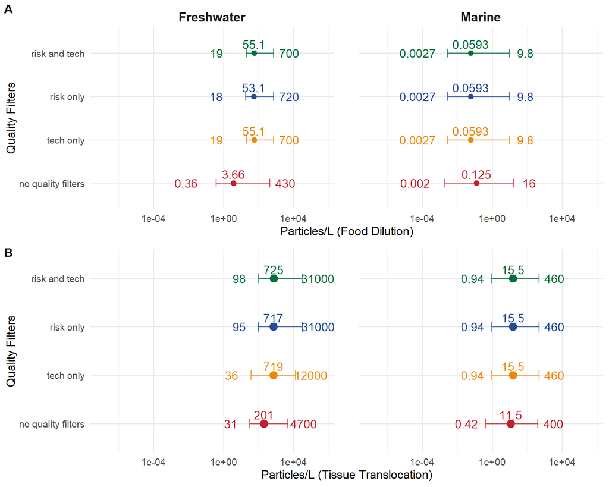

```r
quality_colors <- c("risk and tech" = "#006f3c", "risk only" = "#264b96",
                    "tech only" = "#EB8907", "no quality filters" = "#bf212f")

food_quality <- all_thresholds_combined %>%
  mutate(y_label = paste0("<span style='color:", quality_colors[label], "'>", label, "</span>")) %>%
  filter(Tier == "Tier2",
         Environment != "Freshwater & Marine") %>%
  ggplot(aes(x = `Food Dilution (Default)`, y = label, color = label)) +
  geom_point(size = 2.5) +
  geom_errorbarh(aes(xmin = `Food Dilution (5th %)`,
                     xmax = `Food Dilution (95th %)`),
                  height = 0.2,
                  alpha = 0.75#,
                 # linehe = 1.2
                 ) +
  scale_color_manual(values = quality_colors) +
  geom_text(aes(label = signif(`Food Dilution (Default)`, 3), x = `Food Dilution (Default)`), vjust = -0.5) +
  geom_text(aes(label = signif(`Food Dilution (5th %)`, 2), x = `Food Dilution (5th %)` * 0.02), vjust = +0.5) +
  geom_text(aes(label = signif(`Food Dilution (95th %)`, 2), x = `Food Dilution (95th %)` * 8), vjust = +0.5) +
  xlab("Particles/L (Food Dilution)") +
  ylab("Quality Filters") +
  scale_x_log10(#labels = scales::comma,
                limits = c(0.0000001, 500000)) +
  theme_minimal(base_size = 14) +
  theme(legend.position = "none") +
  coord_cartesian(clip = "off")+
       # axis.text.y = element_markdown()) + # Use element_markdown for y-axis labels
 #scale_y_discrete(labels = setNames(y_label, label)) +
  facet_wrap(~Environment) +
  theme(  panel.spacing = unit(2, "lines")) + # Increase spacing between facets)
  theme(strip.text = element_text(face = "bold", size = 15))

tissue_quality <- all_thresholds_combined %>%
  filter(Tier == "Tier2",
         Environment != "Freshwater & Marine") %>%
  ggplot(aes(x = `Tissue Translocation (Default)`, y = label, color = label)) +
  geom_point(size = 4) +
  geom_errorbarh(aes(xmin = `Tissue Translocation (5th %)`,
                     xmax = `Tissue Translocation (95th %)`),
                  height = 0.2,
                  alpha = 0.75#,
                 # linehe = 1.2
                 ) +
  scale_color_manual(values = quality_colors) +
  geom_text(aes(label = signif(`Tissue Translocation (Default)`, 3), x = `Tissue Translocation (Default)`), vjust = -0.5) +
  geom_text(aes(label = signif(`Tissue Translocation (5th %)`, 2), x = `Tissue Translocation (5th %)` * 0.08), vjust = +0.5) +
  geom_text(aes(label = signif(`Tissue Translocation (95th %)`, 2), x = `Tissue Translocation (95th %)` * 8), vjust = +0.5) +
  scale_x_log10(#labels = scales::comma,
                limits = c(0.0000001, 500000)) +
  xlab("Particles/L (Tissue Translocation)") +
  ylab("Quality Filters") +
  coord_cartesian(clip = "off") +
  theme_minimal(base_size = 14) +
  theme(legend.position = "none") +
  facet_wrap(~Environment) +
  theme(  panel.spacing = unit(2, "lines")) +  # Increase spacing between facets)
  theme(strip.text = element_blank())

quality_tier2 <-  ggarrange(food_quality, tissue_quality,
                            labels = c("A", "B"),
                            nrow = 2)

ggsave(plot = quality_tier2,
       filename = "../output/Manuscript_Figs/quality_tier2.jpg",
      dpi = 600,
      width = 7, height = 5, units = "in")

quality_tier2
```

#### Fold-change table Below we calculate the fold-change of thresholds for marine/freshwater with and without quality filters

```r
#all_thresholds_combined <- read.csv("../output/data/all_thresholds_combined_quality.csv")

tissue_fold_change <- all_thresholds_combined %>%
  filter(label %in% c("risk and tech", "no quality filters"),
         Environment %in% c("Marine", "Freshwater")) %>%
  select(`Tissue Translocation (Default)`, Tier, label, Environment) %>%
  pivot_wider(#cols = Tissue.Translocation..Default.,
              names_from = label,
              values_from = `Tissue Translocation (Default)`) %>%
  mutate(tissue_fold_change = `no quality filters` / `risk and tech`) %>%
  select(Tier, Environment, tissue_fold_change)

food_fold_change <- all_thresholds_combined %>%
  filter(label %in% c("risk and tech", "no quality filters"),
         Environment %in% c("Marine", "Freshwater")) %>%
  select(`Food Dilution (Default)`, Tier, label, Environment) %>%
  pivot_wider(#cols = Tissue.Translocation..Default.,
              names_from = label,
              values_from = `Food Dilution (Default)`) %>%
  mutate(food_fold_change = `no quality filters` / `risk and tech`) %>%
  select(Tier, Environment, food_fold_change)

quality_fold_change <- left_join(food_fold_change, tissue_fold_change) %>%
  mutate_if(is.numeric, ~signif(.,2))

write.csv(quality_fold_change, "../output/data/quality_fold_change.csv")

quality_fold_change
```

```
## # A tibble: 8 × 4
##   Tier  Environment food_fold_change tissue_fold_change
##   <chr> <fct>                  <dbl>              <dbl>
## 1 Tier1 Marine                 0.71                0.45
## 2 Tier2 Marine                 2.1                 0.75
## 3 Tier3 Marine                 1.4                 1
## 4 Tier4 Marine                 1.4                 1
## 5 Tier1 Freshwater             0.019               0.32
## 6 Tier2 Freshwater             0.066               0.28
## 7 Tier3 Freshwater             1.1                 1
## 8 Tier4 Freshwater             1                   1
```

### 1.2.3 Export quality threshold data to excel

```r
getwd()
```

```
## [1] "C:/Users/Scott.Coffin/R_new/ToMEx2.0_EcoToxRisk/scripts"
```

```r
write.csv(all_thresholds_combined, "../output/data/all_thresholds_combined_quality.csv")
```

#### 1.2.3.1 Maximize quality filters

We need to perform an iterative approach to filter the dataset based on quality criteria and ensure that the filtered dataset contains at least 6 unique species. We will maximize the quality of studies used to derive thresholds by trying different combinations of quality criteria.

Here’s how you can do it:

Create a function to filter the dataset based on a given set of quality criteria. Create a function to check if a dataset has at least 6 unique species. Iterate over all possible combinations of quality criteria to find the best quality dataset that meets the minimum species requirement. Run the SSD functions on the best quality dataset.

##### 1.2.3.1.1 Exhaustive Approach

```r
# Define quality criteria
quality_criteria <- c("tech.a1", "tech.a2", "tech.a3", "tech.a4", "tech.a5", "tech.a6", "tech.1",
                      "tech.2", "tech.3", "tech.4", "tech.5", "tech.6", "tech.7", "tech.8", "tech.9",
                      "tech.10", "tech.11", "tech.12", "risk.b1", "risk.13", "risk.14",
                      "risk.15", "risk.16", "risk.17", "risk.18", "risk.19", "risk.20")

red_criteria <- c("tech.a1", "tech.a2", "tech.a3", "tech.a4", "tech.a5", "tech.a6",
                  "tech.1", "tech.2", "tech.3", "tech.4", "tech.5", "risk.13", "risk.b1")

#only use the criteria with variabilty (i.e., minus the red)
variable_criteria <- setdiff(quality_criteria, red_criteria)
variable_criteria_doi <- c(variable_criteria, "doi")

#calculate number of combinations
estimated_time_seconds =  2 ^ n_distinct(variable_criteria) * 0.001 #seconds per iteration
estimated_time_hours = (estimated_time_seconds / 60)/60
estimated_time_hours
```

```
## [1] 0.004551111
```

```r
aoc_risk_paper_filtered <- aoc_risk_paper %>%
  drop_na(effect.metric) %>%
  filter(risk.13 != 1,
         bio_f %in% c("Organism", "Population"),
          Group != "Algae")

### collapse dataset to unique combo of DOI and variable quality criteria to speed up combination testing below
# Step 1. just get at experiment-level data and annotate with unique ID
aoc_risk_collapsed <- aoc_risk_paper %>%
 distinct(across(all_of(variable_criteria_doi)), .keep_all = TRUE)
```

##### 1.2.3.1.2 Heuristic/GREEDY Method

We can employ a heuristic approach to prioritize checking the combinations that are more likely to yield high-quality datasets early, such as starting with the criteria that have the highest average scores or using a greedy algorithm.

```r
# Function to filter dataset based on quality criteria
filter_quality <- function(data, criteria) {
  for (criterion in criteria) {
    data <- data %>% filter(!!sym(criterion) > 0)
  }
  return(data)
}

# Function to check if the dataset has at least 6 unique species
has_minimum_species <- function(data) {
  return(length(unique(data$species)) >= 6)
}

# Heuristic function to find a good quality dataset
find_best_quality_dataset <- function(data, quality_criteria) {
  best_data <- data
  best_quality <- 0

  for (criterion in quality_criteria) {
    filtered_data <- filter_quality(data, criterion)
    if (has_minimum_species(filtered_data)) {
      current_quality <- mean(filtered_data[[criterion]], na.rm = TRUE)
      if (current_quality > best_quality) {
        best_quality <- current_quality
        best_data <- filtered_data
      }
    }
  }

  return(best_data)
}

# Find the best quality dataset for each case
best_data <- find_best_quality_dataset(aoc_risk_paper, quality_criteria)

best_data %>% select(c(Species, total.quality, contains("tech"), contains("risk"))) %>%
  distinct() %>%
  arrange(desc(Species))
```

```
## # A tibble: 93 × 33
##    Species  total.quality tech.a1 tech.a2 tech.a3 tech.a4 tech.a5 tech.a6 tech.1
##    <fct>            <dbl>   <dbl>   <dbl>   <dbl>   <dbl>   <dbl>   <dbl>  <dbl>
##  1 Strombi…            17       2       2       2       2       2       2      1
##  2 Scenede…            16       2       2       2       2       2       2      1
##  3 Pseudec…            12       2       2       2       2       2       2      1
##  4 Perca f…            14       2       2       2       2       2       2      2
##  5 Perca f…            15       2       2       2       2       2       2      1
##  6 Moina m…            19       2       2       2       2       2       2      1
##  7 Meretri…            21       2       2       2       2       2       2      2
##  8 Diaphan…            13       2       2       2       2       2       2      2
##  9 Chirono…            25       2       2       2       2       2       2      2
## 10 Centrop…            16       2       2       2       2       2       2      1
## # ℹ 83 more rows
## # ℹ 24 more variables: tech.2 <dbl>, tech.3 <dbl>, tech.4 <dbl>, tech.5 <dbl>,
## #   tech.6 <dbl>, tech.7 <dbl>, tech.8 <dbl>, tech.9 <dbl>, tech.10 <dbl>,
## #   tech.11 <dbl>, tech.12 <dbl>, technical.quality <dbl>,
## #   tier_zero_tech_f <fct>, risk.b1 <dbl>, risk.13 <dbl>, risk.14 <dbl>,
## #   risk.15 <dbl>, risk.16 <dbl>, risk.17 <dbl>, risk.18 <dbl>, risk.19 <dbl>,
## #   risk.20 <dbl>, risk.quality <dbl>, tier_zero_risk_f <fct>
```

```r
# Example usage with best quality datasets
best_data_thresholds <- calculate_thresholds(best_data, label = "best data")
```

```
## # A tibble: 6 × 6
##   Group     EC_env_v.particles.mL_ingest EC_env_sa.particles.mL_…¹ effect.metric
##   <fct>                            <dbl>                     <dbl> <fct>
## 1 Crustacea                       20032.                    25724. NOEC
## 2 Crustacea                      200323.                   257242. LOEC
## 3 Crustacea                      100161.                   128621. LOEC
## 4 Crustacea                      100161.                   128621. LOEC
## 5 Crustacea                      921484.                  1183311. LC50
## 6 Crustacea                        1168.                     1342. NOEC
## # ℹ abbreviated name: ¹EC_env_sa.particles.mL_trans
## # ℹ 2 more variables: dose.particles.mL.master <dbl>,
## #   size.length.um.used.for.conversions <dbl>
```

```r
library(dplyr)

# Function to extract minimum rows for both metrics and environments
extract_minimum_rows <- function(dataset, label) {
  # Convert the dataset to a data frame
  data <- as.data.frame(dataset$full_dataset)

  # Extract minimum rows for Marine environment
  marine_min_food <- data %>%
    filter(environment == "Marine") %>%
    slice(which.min(particles_mL_food_dilution)) %>%
    mutate(label = label, metric = "particles_mL_food_dilution")

  marine_min_ox <- data %>%
    filter(environment == "Marine") %>%
    slice(which.min(particles_mL_ox_stress)) %>%
    mutate(label = label, metric = "particles_mL_ox_stress")

  # Extract minimum rows for Freshwater environment
  freshwater_min_food <- data %>%
    filter(environment == "Freshwater") %>%
    slice(which.min(particles_mL_food_dilution)) %>%
    mutate(label = label, metric = "particles_mL_food_dilution")

  freshwater_min_ox <- data %>%
    filter(environment == "Freshwater") %>%
    slice(which.min(particles_mL_ox_stress)) %>%
    mutate(label = label, metric = "particles_mL_ox_stress")

  # Combine all extracted rows
  bind_rows(marine_min_food, marine_min_ox, freshwater_min_food, freshwater_min_ox)
}

# Apply the function to each dataset
risk_tech_minimum <- extract_minimum_rows(risk_tech, "risk and tech")
tech_minimum <- extract_minimum_rows(tech, "tech only")
risk_minimum <- extract_minimum_rows(risk, "risk only")
no_quality_minimum <- extract_minimum_rows(no_quality, "no quality filters")
best_data_minimum <- extract_minimum_rows(best_data_thresholds, "best data")

# Combine all minimum rows into a single data frame
all_minimum_rows <- bind_rows(
  risk_tech_minimum,
  tech_minimum,
  risk_minimum,
  no_quality_minimum,
  best_data_minimum
)

# Rename columns as required
all_minimum_rows <- all_minimum_rows %>%
  rename(
    most_sensitive_species = species,
    most_sensitive_group = group,
    most_sensitive_study = study
  )

# Combine the marine thresholds
marine_thresholds <- bind_rows(
  risk_tech$base_thresholds$marine,
  tech$base_thresholds$marine,
  risk$base_thresholds$marine,
  no_quality$base_thresholds$marine,
  best_data_thresholds$base_thresholds$marine,
  all_minimum_rows %>% filter(environment == "Marine")
) %>%
  mutate(environment = "Marine")

# Combine the freshwater thresholds
freshwater_thresholds <- bind_rows(
  risk_tech$base_thresholds$freshwater,
  tech$base_thresholds$freshwater,
  risk$base_thresholds$freshwater,
  no_quality$base_thresholds$freshwater,
  best_data_thresholds$base_thresholds$freshwater
) %>%
  mutate(environment = "Freshwater") %>%
  left_join(all_minimum_rows, by = c("environment", "label"),
            relationship = "many-to-many")

# Combine the marine and freshwater data into a single unified data frame
unified_thresholds <- bind_rows(marine_thresholds, freshwater_thresholds)

# View the final unified thresholds
print(unified_thresholds)
```

```
## # A tibble: 70 × 23
##    Tier  Tissue Translocation (D…¹ Food Dilution (Defau…² Tissue Translocation…³
##    <chr>                     <dbl>                  <dbl>                  <dbl>
##  1 Tier1                     0.936                0.00274                 NA
##  2 Tier2                    15.5                  0.0593                   0.936
##  3 Tier3                   650.                   3.64                   144.
##  4 Tier4                  2322.                  25.1                    442.
##  5 Tier1                     0.936                0.00274                 NA
##  6 Tier2                    15.5                  0.0593                   0.936
##  7 Tier3                   650.                   3.64                   144.
##  8 Tier4                  2322.                  25.1                    442.
##  9 Tier1                     0.936                0.00274                 NA
## 10 Tier2                    15.5                  0.0593                   0.936
## # ℹ 60 more rows
## # ℹ abbreviated names: ¹`Tissue Translocation (Default)`,
## #   ²`Food Dilution (Default)`, ³`Tissue Translocation (5th %)`
## # ℹ 19 more variables: `Tissue Translocation (95th %)` <dbl>,
## #   `Food Dilution (5th %)` <dbl>, `Food Dilution (95th %)` <dbl>,
## #   `N Species (tissue trans)` <int>, `N Species (food dilution)` <int>,
## #   `N Groups (tissue trans)` <int>, `N Groups (food dilution)` <int>, …
```

```r
# Combine all thresholds into a single table
# Convert datasets to data frames and extract the minimum rows
risk_tech_data <- as.data.frame(risk_tech$full_dataset)
risk_tech_data %>% filter(environment == "Freshwater") %>%  filter(particles_mL_food_dilution == min(particles_mL_food_dilution, na.rm = TRUE)) %>% distinct()
```

```
##           species     group environment           study
## 1 Moina macrocopa Crustacea  Freshwater Kim & Rhee 2021
##                          doi particles_mL_ox_stress particles_mL_food_dilution
## 1 10.1007/s13273-021-00162-5               1.818631                 0.08421307
##   unique_id
## 1       438
```

```r
risk_tech_minimum <- risk_tech_data[which.min(risk_tech_data$particles_mL_food_dilution), 1:4] %>%
  mutate(label = "risk and tech")

tech_data <- as.data.frame(tech$full_dataset)
tech_minimum <- tech_data[which.min(tech_data$particles_mL_food_dilution), 1:4] %>%
  mutate(label = "tech only")

risk_data <- as.data.frame(risk$full_dataset)
risk_minimum <- risk_data[which.min(risk_data$particles_mL_food_dilution), 1:4] %>%
  mutate(label = "risk only")

no_quality_data <- as.data.frame(no_quality$full_dataset)
no_quality_minimum <- no_quality_data[which.min(no_quality_data$particles_mL_food_dilution), 1:4] %>%
  mutate(label = "no quality filters")

best_data_data <- as.data.frame(best_data_thresholds$full_dataset)
best_data_minimum <- best_data_data %>% filter()

# Combine the marine thresholds from each dataset
marine_thresholds <- bind_rows(
  risk_tech$base_thresholds$marine,
  risk_tech_minimum,
  tech$base_thresholds$marine,
  tech_minimum,
  risk$base_thresholds$marine,
  risk_minimum,
  no_quality$base_thresholds$marine,
  no_quality_minimum,
  best_data_thresholds$base_thresholds$marine,
  best_data_minimum
) %>%
  mutate(Environment = "Marine")

# Combine the freshwater thresholds from each dataset
freshwater_thresholds <- bind_rows(
  risk_tech$base_thresholds$freshwater,
  tech$base_thresholds$freshwater,
  risk$base_thresholds$freshwater,
  no_quality$base_thresholds$freshwater,
  best_data_thresholds$base_thresholds$freshwater
) %>%
  mutate(Environment = "Freshwater")

# Combine the marine and freshwater data into a single unified data frame
unified_thresholds <- bind_rows(marine_thresholds, freshwater_thresholds)


# Print the unified thresholds table
print(unified_thresholds)
```

```
## # A tibble: 611 × 23
##    Tier  Tissue Translocation (D…¹ Food Dilution (Defau…² Tissue Translocation…³
##    <chr>                     <dbl>                  <dbl>                  <dbl>
##  1 Tier1                     0.936                0.00274                 NA
##  2 Tier2                    15.5                  0.0593                   0.936
##  3 Tier3                   650.                   3.64                   144.
##  4 Tier4                  2322.                  25.1                    442.
##  5 <NA>                     NA                   NA                       NA
##  6 Tier1                     0.936                0.00274                 NA
##  7 Tier2                    15.5                  0.0593                   0.936
##  8 Tier3                   650.                   3.64                   144.
##  9 Tier4                  2322.                  25.1                    442.
## 10 <NA>                     NA                   NA                       NA
## # ℹ 601 more rows
## # ℹ abbreviated names: ¹`Tissue Translocation (Default)`,
## #   ²`Food Dilution (Default)`, ³`Tissue Translocation (5th %)`
## # ℹ 19 more variables: `Tissue Translocation (95th %)` <dbl>,
## #   `Food Dilution (5th %)` <dbl>, `Food Dilution (95th %)` <dbl>,
## #   `N Species (tissue trans)` <int>, `N Species (food dilution)` <int>,
## #   `N Groups (tissue trans)` <int>, `N Groups (food dilution)` <int>, …
```

# 2 Sensitivity Analysis

## 2.1 Freshwater vs. Marine species sensitivity

We performed an additional sensitivity analysis aimed at disentangling the species sensitivities for freshwater and marine environments from their respective environmental distributions in the resulting thresholds to shed light on whether marine or freshwater species are innately more or less sensitive to microplastics. To accomplish this, we simply generated a set of thresholds using freshwater species, but used marine environmental microplastics distribution data for the alignments, comparing the resulting thresholds.

### 2.1.1 Freshwater species with marine params

```r
# align all data to marine params (done above)
# aoc_marine_alphas_aligned

# derive thresholds using freshwater species but with marine params
freshwater_species_marine_params_thresholds <- derive_thresholds(aoc_marine_alphas_aligned %>%
                                                                   filter(environment == "Freshwater"))
```

```
## [1] 29.52109
```

```
## [1] 2.999864
```

```r
# compare freshwater species marine params thresholds with freshwater species freshwater params thresholds

formatted_freshwater_species_marine_params_thresholds <- freshwater_species_marine_params_thresholds$base_thresholds %>%
  mutate_if(is.numeric, ~signif(., 2)) %>%
  mutate(across(where(is.numeric), ~scales::comma(.))) %>%
  mutate("Food (Freshwater Sp., marine params)" = paste0(`Food Dilution (Default)`, " (", `Food Dilution (5th %)`, " to ", `Food Dilution (95th %)`,")"),
         "Tissue (Freshwater Sp., marine params)" = paste0(`Tissue Translocation (Default)`, " (", `Tissue Translocation (5th %)`, " to ", `Tissue Translocation (95th %)`,")")) %>%
  select(Tier, "Food (Freshwater Sp., marine params)", "Tissue (Freshwater Sp., marine params)")

# rename cols in above calcualted
formatted_freshwater_species_freshwater_params_thresholds <- formatted_freshwater_base %>%
  rename("Food (Freshwater sp., freshwater params)" = "Food (Freshwater)",
         "Tissue (Freshwater sp., freshwater params)" = "Tissue (Freshwater)")

#join up
params_species_sensitivity_analysis_freshwater_sp <- left_join(formatted_freshwater_species_marine_params_thresholds,
                                                               formatted_freshwater_species_freshwater_params_thresholds)

params_species_sensitivity_analysis_freshwater_sp
```

```
## # A tibble: 4 × 5
##   Tier  Food (Freshwater Sp., ma…¹ Tissue (Freshwater S…² Food (Freshwater sp.…³
##   <chr> <chr>                      <chr>                  <chr>
## 1 Tier1 3.0 (NA to NA)             30 (NA to NA)          <NA>
## 2 Tier2 8.6 (2.9 to 110)           120 (14 to 5,600)      55.1 (19.1 to 704)
## 3 Tier3 37.0 (12.0 to 550)         850 (320 to 11,000)    253 (82.9 to 3570)
## 4 Tier4 130.0 (46.0 to 2,200)      1,800 (780 to 19,000)  849 (318 to 14400)
## # ℹ abbreviated names: ¹`Food (Freshwater Sp., marine params)`,
## #   ²`Tissue (Freshwater Sp., marine params)`,
## #   ³`Food (Freshwater sp., freshwater params)`
## # ℹ 1 more variable: `Tissue (Freshwater sp., freshwater params)` <chr>
```

### 2.1.2 Marine species with freshwater params

```r
# align all data to freshwater params
aoc_freshwater_alphas_aligned <- align_data(aoc_risk_paper,

                       R.ave.marine_input = 0.67, # average length to width ratio of microplastics in marine environment (Kooi et al. 2021)
                       H_W_ratio.marine_input = 0.67, # H:W ratio assumed same as width:length ratio (Kooi et al. 2021)
                     R.ave.sediment.marine_input = 0.70, # average length to width ratio of microplastics in marine environment (Kooi et al. 2021)
                       p.ave.marine_input = 1.04, #average density in marine surface water
                       alpha.marine_input = 2.64, #table s4 for marine surface water. length
                       a.sa.marine_input = 2.00, #marine surface area power law
                       a.v.marine_input = 1.68, #a_V for marine surface water volume
                       a.m.marine_input = 1.65, # upper limit fora_m for mass for marine surface water in table S4
                       a.ssa.marine_input = 2.71, # A_SSA for marine surface water
                                            )

# derive thresholds using freshwater species but with marine params
marine_species_freshwater_params_thresholds <- derive_thresholds(aoc_freshwater_alphas_aligned %>%
                                                                   filter(environment == "Marine"))
```

```
## [1] 7.745769
```

```
## [1] 0.173072
```

```r
# compare marine species freshwater params thresholds with marine species marine params thresholds

formatted_marine_species_freshwater_params_thresholds <- marine_species_freshwater_params_thresholds$base_thresholds %>%
  mutate_if(is.numeric, ~signif(., 2)) %>%
  mutate(across(where(is.numeric), ~scales::comma(.))) %>%
  mutate("Food (Marine Sp., freshwater params)" = paste0(`Food Dilution (Default)`, " (", `Food Dilution (5th %)`, " to ", `Food Dilution (95th %)`,")"),
         "Tissue (Marine Sp., freshwater params)" = paste0(`Tissue Translocation (Default)`, " (", `Tissue Translocation (5th %)`, " to ", `Tissue Translocation (95th %)`,")")) %>%
  select(Tier, "Food (Marine Sp., freshwater params)", "Tissue (Marine Sp., freshwater params)")

# rename cols in above calcualted
formatted_marine_species_marine_params_thresholds <- formatted_marine_base %>%
  rename("Food (marine sp., marine params)" = "Food (Marine)",
         "Tissue (marine sp., marine params)" = "Tissue (Marine)")

#join up
params_species_sensitivity_analysis_marine_sp <- left_join(formatted_marine_species_freshwater_params_thresholds,
                                                               formatted_marine_species_marine_params_thresholds)

params_species_sensitivity_analysis_marine_sp
```

```
## # A tibble: 4 × 5
##   Tier  Food (Marine Sp., freshw…¹ Tissue (Marine Sp., …² Food (marine sp., ma…³
##   <chr> <chr>                      <chr>                  <chr>
## 1 Tier1 0.2 (NA to NA)             8 (NA to NA)           <NA>
## 2 Tier2 2.4 (0 to 160)             110 (8 to 2,900)       0.0593 (0.00274 to 9.…
## 3 Tier3 150.0 (31 to 5,300)        5,500 (1,200 to 62,00… 3.64 (0.425 to 375)
## 4 Tier4 680.0 (97 to 21,000)       19,000 (3,700 to 180,… 25.1 (2.36 to 2240)
## # ℹ abbreviated names: ¹`Food (Marine Sp., freshwater params)`,
## #   ²`Tissue (Marine Sp., freshwater params)`,
## #   ³`Food (marine sp., marine params)`
## # ℹ 1 more variable: `Tissue (marine sp., marine params)` <chr>
```

```r
freshwater_marine_params_species_sensitivity_analysis <-
  left_join(params_species_sensitivity_analysis_freshwater_sp, params_species_sensitivity_analysis_marine_sp)
```

## 2.2 Leave-one-out method

```r
#use SSD functions for MC
source("utils/ssd_functions.R")

create_leave_one_out_function_t1 <- function(filtered_data) {
  # Vectorized leave-one-out function
  sensitivity_t1 <- Vectorize(function(x, y) {
    # Exclude the current study (doi) from the training set
    train <- filtered_data[!filtered_data$doi %in% x,]
    # Apply the SSD function
    SSD_function_t1(train, hcxlcl = y)
  })

  # Return the vectorized function
  sensitivity_t1
}

create_leave_one_out_function_t2 <- function(filtered_data) {
  # Vectorized leave-one-out function
  sensitivity_t2 <- Vectorize(function(x, y) {
    # Exclude the current study (doi) from the training set
    train <- filtered_data[!filtered_data$doi %in% x,]
    # Apply the SSD function
    hc <- SSD_function_t2(train, hcx = y)
    hc <- hc$hcx_est[1]
    hc
  })

  # Return the vectorized function
  sensitivity_t2
}

create_leave_one_out_function_t3_4 <- function(filtered_data) {
  # Vectorized leave-one-out function
  sensitivity_t3_4 <- Vectorize(function(x, y) {
    # Exclude the current study (doi) from the training set
    train <- filtered_data[!filtered_data$doi %in% x,]
    # Apply the SSD function
    hc <- SSD_function_t3_4(train, hcx = y)
    hc <- hc$hcx_est[1]
    hc
  })

  # Return the vectorized function
  sensitivity_t3_4
}

#tier 1 function
leave_one_out_tier_1 <- function(filtered_data,
                                 hcx, ERM_input, tier_input, environment_input) {
  hcxlcl_list <- list(hcxlcl = hcx)
  #base HCx (wihtout leaving any studies out)
  filtered_data_hcxlcl <- SSD_function_t1(filtered.data = filtered_data, hcx)
  filtered_data_hcxlcl <- filtered_data_hcxlcl$hc5lcl[1]

  unique.dois <- unique(filtered_data$doi)
  # Create the leave-one-out function with your filtered data
  leave_one_out <- create_leave_one_out_function_t1(filtered_data)
  # Apply the leave-one-out function for each study
  sensitivity_vector <- leave_one_out(unique.dois, hcxlcl_list)

  names(sensitivity_vector) <- c("hc5lcl", "n_species", "n_groups", "n_datapoints")

  # Convert the list into a data frame and transpose it
  sensitivity_tbl <- as_tibble(as.data.frame(t(sensitivity_vector))) %>%
     mutate(doi = names(hc5lcl)) %>%
    mutate(
    hc5lcl = unname(unlist(hc5lcl)),      # Convert to numeric vector and remove names
    n_species = unname(unlist(n_species)),  # Convert to integer vector and remove names
    n_groups = unname(unlist(n_groups)),    # Convert to integer vector and remove names
    n_datapoints = unname(unlist(n_datapoints))  # Convert to integer vector and remove names
  )

  # join to other parameters of interest
   sensitivity_df <- left_join(sensitivity_tbl, filtered_data, by = "doi") %>%
    dplyr::select(authors, year, Species, dose_new,
                  hc5lcl, acute.chronic_f, bio_f, lvl2_f,
                  size.length.um.used.for.conversions, doi) %>%
    distinct(doi, authors, year, hc5lcl, Species, acute.chronic_f,
             size.length.um.used.for.conversions) %>%
    mutate(authoryear = paste(authors, "et. al ", year)) %>%
    mutate(hcxlcl = replace_na(hc5lcl, 0)) %>% #studies with n_species < 5 will get a 0
    mutate(authoryear = fct_reorder(authoryear, hcxlcl, na.rm = FALSE)) %>%
    mutate(diff = (hcxlcl - filtered_data_hcxlcl)/filtered_data_hcxlcl,
           fold_change = filtered_data_hcxlcl/hcxlcl,
           tier = as.character(tier_input),
           ERM = as.character(ERM_input),
           environment = as.character(environment_input))

  sensitivity_summary <- sensitivity_df %>%
    rename(hcx = hcxlcl) %>%
    group_by(doi, authoryear, diff, hcx, fold_change) %>%
    summarise(species_multiple = paste(unique(Species), collapse = ", "),
              .groups = "keep") %>%
    ungroup() %>%
    arrange(desc(hcx)) %>%
    mutate(hcx = case_when(hcx == 0 ~ NA,
                           TRUE ~ hcx),
           diff = case_when(diff == -1 ~ NA,
                            TRUE ~ diff)) %>%
    mutate(sufficient_species = case_when(!is.na(hcx) ~ "sufficient",
                                          is.na(hcx) ~ "insufficient"),
           ERM = as.character(ERM_input),
           environment = as.character(environment_input),
           tier = as.character(tier_input)) #annotate for full dataset))

   return(list(sensitivity_df = sensitivity_df,
               sensitivity_summary = sensitivity_summary))
}

# Tier 2 function
leave_one_out_tier2 <- function(filtered_data, hcx_num, ERM_input, tier_input, environment_input) {
  hcx_list <- list(hcx = hcx_num)
  #base HCx
  filtered_data_hcx <- SSD_function_t2(filtered.data = filtered_data, hcx_num)
  filtered_data_hcx <- filtered_data_hcx$hcx_est[1]
  unique.dois <- unique(filtered_data$doi)
  # Create the leave-one-out function with your filtered data
  leave_one_out <- create_leave_one_out_function_t2(filtered_data)
  # Apply the leave-one-out function
  sensitivity_vector <- leave_one_out(unique.dois, hcx_list)
  sensitivity_matrix <- matrix(sensitivity_vector, nrow = length(unique.dois), byrow = TRUE)
  rownames(sensitivity_matrix) <- unique.dois
  #bind DOI's to other parameters of interest for analysis
  sensitivity_tbl <- rownames_to_column(as.data.frame(sensitivity_matrix), var = c("doi")) %>%
    rename(hcx = V1)
  # join to other parameters of interest
  sensitivity_df <- left_join(sensitivity_tbl, filtered_data, by = "doi") %>%
    dplyr::select(authors, year, Species, dose_new,
                  hcx, acute.chronic_f, bio_f, lvl2_f,
                  size.length.um.used.for.conversions, doi) %>%
    distinct(doi, authors, year, hcx, Species, acute.chronic_f,
             size.length.um.used.for.conversions) %>%
    mutate(authoryear = paste(authors, "et. al ", year)) %>%
    mutate(hcx = replace_na(hcx, 0)) %>% #studies with n_species < 5 will get a 0
    mutate(authoryear = fct_reorder(authoryear, hcx, na.rm = FALSE)) %>%
    mutate(diff = (hcx - filtered_data_hcx)/filtered_data_hcx,
           fold_change = filtered_data_hcx/hcx,
             tier = as.character(tier_input), #annotate for full dataset
           ERM = as.character(ERM_input),
           environment = as.character(environment_input)) #annotate for full dataset

  sensitivity_summary <- sensitivity_df %>%
    group_by(doi, authoryear, diff, hcx, fold_change) %>%
    summarise(species_multiple = paste(unique(Species), collapse = ", "),
              .groups = "keep") %>%
    ungroup() %>%
    arrange(desc(hcx)) %>%
    mutate(hcx = case_when(hcx == 0 ~ NA,
                           TRUE ~ hcx),
           diff = case_when(diff == -1 ~ NA,
                            TRUE ~ diff)) %>%
    mutate(sufficient_species = case_when(!is.na(hcx) ~ "sufficient",
                                          is.na(hcx) ~ "insufficient"),
           ERM = as.character(ERM_input),
           environment = as.character(environment_input),
           tier = as.character(tier_input)) #annotate for full dataset))

   return(list(sensitivity_df = sensitivity_df,
               sensitivity_summary = sensitivity_summary))
}

# Tier 3/4 function
leave_one_out_tier3_4 <- function(filtered_data, hcx_num, ERM_input, tier_input, environment_input) {
  hcx_list <- list(hcx = hcx_num)
  #base HCx
  filtered_data_hcx <- SSD_function_t3_4(filtered.data = filtered_data, hcx_num)
  filtered_data_hcx <- filtered_data_hcx$hcx_est[1]
  unique.dois <- unique(filtered_data$doi)
  # Create the leave-one-out function with your filtered data
  leave_one_out <- create_leave_one_out_function_t3_4(filtered_data)
  # Apply the leave-one-out function
  sensitivity_vector <- leave_one_out(unique.dois, hcx_list)
  sensitivity_matrix <- matrix(sensitivity_vector, nrow = length(unique.dois), byrow = TRUE)
  rownames(sensitivity_matrix) <- unique.dois
  #bind DOI's to other parameters of interest for analysis
  sensitivity_tbl <- rownames_to_column(as.data.frame(sensitivity_matrix), var = c("doi")) %>%
    rename(hcx = V1)
  # join to other parameters of interest
  sensitivity_df <- left_join(sensitivity_tbl, filtered_data, by = "doi") %>%
    dplyr::select(authors, year, Species, dose_new,
                  hcx, acute.chronic_f, bio_f, lvl2_f,
                  size.length.um.used.for.conversions, doi) %>%
    distinct(doi, authors, year, hcx, Species, acute.chronic_f,
             size.length.um.used.for.conversions) %>%
    mutate(authoryear = paste(authors, "et. al ", year)) %>%
    mutate(hcx = replace_na(hcx, 0)) %>% #studies with n_species < 5 will get a 0
    mutate(authoryear = fct_reorder(authoryear, hcx, na.rm = FALSE)) %>%
    mutate(diff = (hcx - filtered_data_hcx)/filtered_data_hcx,
           fold_change = filtered_data_hcx/hcx,
           tier = as.character(tier_input), #annotate for full dataset
           ERM = as.character(ERM_input),
           environment = as.character(environment_input)) #annotate for full dataset)

  sensitivity_summary <- sensitivity_df %>%
    group_by(doi, authoryear, diff, hcx, fold_change) %>%
    summarise(species_multiple = paste(unique(Species), collapse = ", "),
              .groups = "keep") %>%
    ungroup() %>%
    arrange(desc(hcx)) %>%
    mutate(hcx = case_when(hcx == 0 ~ NA,
                           TRUE ~ hcx),
           diff = case_when(diff == -1 ~ NA,
                            TRUE ~ diff)) %>%
    mutate(sufficient_species = case_when(!is.na(hcx) ~ "sufficient",
                                          is.na(hcx) ~ "insufficient"),
           ERM = as.character(ERM_input),
           environment = as.character(environment_input),
           tier = as.character(tier_input)) #annotate for full dataset))

   return(list(sensitivity_df = sensitivity_df,
               sensitivity_summary = sensitivity_summary))
}
```

### 2.2.1 Perform Sensitivity Analyses

### 2.2.2 Export Data

#### 2.2.2.1 Join to base thresholds for comparison

```r
thresholds <- all_thresholds_long %>%
  filter(grepl("Default", Metric)) %>%
  mutate(tier = case_when(Tier == "Tier1" ~ "Tier 1",
                          Tier == "Tier2" ~ "Tier 2",
                          Tier == "Tier3" ~ "Tier 3",
                          Tier == "Tier4" ~ "Tier 4")) %>%
  mutate(ERM = case_when(grepl("Tissue", Metric) ~ "Tissue Translocation",
                         grepl("Food", Metric) ~ "Food Dilution")) %>%
  rename("environment" = "Environment") %>%
  filter(label == "risk and tech",
         environment != "Freshwater & Marine") %>%
  rename(threshold = Value) %>%
  select(ERM, tier, environment, threshold) %>%
  arrange(desc(ERM))

thresholds
```

```
## # A tibble: 16 × 4
##    ERM                  tier   environment  threshold
##    <chr>                <chr>  <fct>            <dbl>
##  1 Tissue Translocation Tier 1 Marine         0.936
##  2 Tissue Translocation Tier 2 Marine        15.5
##  3 Tissue Translocation Tier 3 Marine       650.
##  4 Tissue Translocation Tier 4 Marine      2322.
##  5 Tissue Translocation Tier 1 Freshwater    98.2
##  6 Tissue Translocation Tier 2 Freshwater   725.
##  7 Tissue Translocation Tier 3 Freshwater  4031.
##  8 Tissue Translocation Tier 4 Freshwater  9031.
##  9 Food Dilution        Tier 1 Marine         0.00274
## 10 Food Dilution        Tier 2 Marine         0.0593
## 11 Food Dilution        Tier 3 Marine         3.64
## 12 Food Dilution        Tier 4 Marine        25.1
## 13 Food Dilution        Tier 1 Freshwater    19.1
## 14 Food Dilution        Tier 2 Freshwater    55.1
## 15 Food Dilution        Tier 3 Freshwater   253.
## 16 Food Dilution        Tier 4 Freshwater   849.
```

```r
leave_one_out_df <- bind_rows(tier1_sensitivity_tissue_freshwater$sensitivity_summary,
                          tier2_sensitivity_tissue_freshwater$sensitivity_summary,
                          tier3_sensitivity_tissue_freshwater$sensitivity_summary,
                          tier4_sensitivity_tissue_freshwater$sensitivity_summary,
                          tier1_sensitivity_food_freshwater$sensitivity_summary,
                          tier2_sensitivity_food_freshwater$sensitivity_summary,
                          tier3_sensitivity_food_freshwater$sensitivity_summary,
                          tier4_sensitivity_food_freshwater$sensitivity_summary,
                          tier1_sensitivity_tissue_marine$sensitivity_summary,
                          tier2_sensitivity_tissue_marine$sensitivity_summary,
                          tier3_sensitivity_tissue_marine$sensitivity_summary,
                          tier4_sensitivity_tissue_marine$sensitivity_summary,
                          tier1_sensitivity_food_marine$sensitivity_summary,
                          tier2_sensitivity_food_marine$sensitivity_summary,
                          tier3_sensitivity_food_marine$sensitivity_summary,
                          tier4_sensitivity_food_marine$sensitivity_summary) %>%
  mutate(tier = as.factor(tier)) %>%
  left_join(thresholds,
            by = c("ERM", "tier", "environment")) %>%
  mutate(fold_change = (hcx / threshold))

write.csv(leave_one_out_df,
          "../output/data/leave_one_out.csv")
```

```r
### start here if not wanting to run previous chunk (can take a long time)
leave_one_out_df <- read.csv("../output/data/leave_one_out.csv")
```

### 2.2.3 Plot

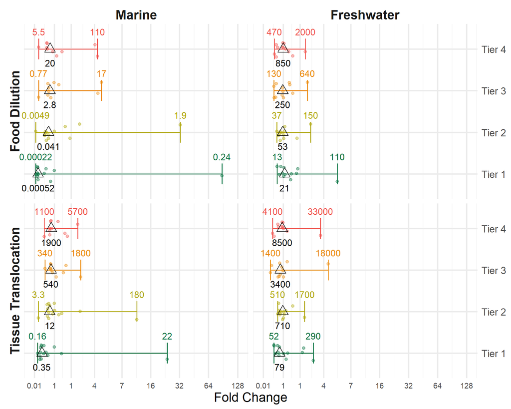

```r
library(ggallin)

# Assign specific colors based on Tier levels
tier_colors <- setNames(c("#006f3c", "#b0a704", "#EB8907", "#f0514b"),
                        levels(leave_one_out_df$tier))

# Calculate min and max limits for `diff` column
min_diff <- min(leave_one_out_df$fold_change, na.rm = TRUE) * 0.7  # Add some padding
max_diff <- max(leave_one_out_df$fold_change, na.rm = TRUE) * 1.3  # Add some padding

summary_diff_df <- leave_one_out_df %>%
  drop_na() %>%
  group_by(environment, tier, ERM) %>%
  summarize(
    min_fold_change = min(fold_change, na.rm = TRUE),
    max_fold_change = max(fold_change, na.rm = TRUE),
    median_fold_change = median(fold_change, na.rm = TRUE),
    min_hcx = min(hcx, na.rm = TRUE),
    max_hcx = max(hcx, na.rm = TRUE),
    median_hcx = median(hcx, na.rm = TRUE),
    .groups = 'drop'
  ) %>%
  mutate(environment = factor(environment, levels = c("Marine", "Freshwater")))

leave_one_out_df_trim <- leave_one_out_df %>%
  mutate(environment = factor(environment, levels = c("Marine", "Freshwater"))) %>%
  drop_na() %>%
  mutate(fold_change = fold_change)


leave_one_out_ggplot <- ggplot() +
  geom_jitter(data = leave_one_out_df_trim,
              aes(x = fold_change, y = tier, color = tier,
             text = paste0("fold_change: ", signif(fold_change, 2),
                                              "<br>HCx: ",scientific(hcx, 3), " particles/L",
                                              "<br>Study: ", authoryear,
                                              "<br>Species: " ,species_multiple,
                                              "<br>doi: ", doi)),
             height = 0.2, alpha = 0.4) +
   # Add horizontal error bars for min and max values
  geom_errorbarh(data = summary_diff_df,
                 aes(xmin = min_fold_change, xmax = max_fold_change, y = tier, color = tier),
                 height = 0.5, alpha = 1) +
    # Add points for median values
  geom_point(data = summary_diff_df,
             aes(x = median_fold_change, y = tier),
             color = "black",
             size = 5, shape = 2, alpha = 1) +
  # add label for min and max HCx
  geom_text(data = summary_diff_df,
                 aes(x = min_fold_change, label = signif(min_hcx,2), y = tier, color = tier),
            vjust = -2) +
  geom_text(data = summary_diff_df,
                 aes(x = max_fold_change, label = signif(max_hcx,2), y = tier, color = tier),
            vjust = -2) +
  #add label for median hcx
  geom_text(data = summary_diff_df,
                 aes(x = median_fold_change, label = signif(median_hcx,2), y = tier), # color = tier),
            color = "black",
            vjust = +2.5) +

    scale_color_manual(values = tier_colors) +  # Apply manual colors for lines
scale_x_continuous(
  trans = pseudo_log_trans(base = 2),
  breaks = c(0.01, 1, 2, 4, 8, 16, 32, 64, 128),
  limits = c(0.01, 130),  # slightly higher than 128 to ensure it appears
  labels = function(x) {
    sapply(x, function(v) {
      if (is.na(v)) {
        NA
      } else if (isTRUE(all.equal(v, 0.01))) {
        "0.01"
      } else {
        as.character(as.integer(v))
      }
    })
  }
) +
  xlab("Fold Change") +
  coord_cartesian(clip = "off") +
  theme_minimal(base_size = 13) +

 theme( plot.title = element_text(hjust = 0.5, size = 14),     # Center the main title
        strip.text = element_text(size = 18, face = "bold"),
        panel.grid.major = element_line(size = 1),  # Thicker major grid lines
        panel.grid.minor = element_line(size = 0.02),
        plot.subtitle = element_text(hjust = 0.5),
        plot.caption = element_text(hjust = 0.5),   # Center the caption
        axis.title.x = element_text(hjust = 0.5, size = 18),  # Center the x-axis title
        axis.text.x =  element_text(size = 11),
        axis.text.y = element_text(size = 14),
        axis.title.y = element_text(vjust = 0.5, size = 18)) +   # Center the y-axis title (vertically))   # Center the subtitle)
  theme(legend.position = "none",
        axis.title.y = element_blank()) +

  facet_grid(ERM ~ environment,
             switch = "y") +
  scale_y_discrete(position = "right")

ggsave(plot = leave_one_out_ggplot,
       filename = "../output/Manuscript_Figs/leave_one_out.jpg",
      dpi = 300,
      width = 9, height = 6.5, units = "in")

leave_one_out_ggplot
```

#### Plotly

```r
leave_one_out_ggplotly <- ggplotly(leave_one_out_ggplot, tooltip = "text")

require(htmlwidgets)

# Save the plot as an HTML file
saveWidget(leave_one_out_ggplotly , file = "../output/Manuscript_Figs/leave_one_out_ggplotly.html")
```

## 2.3 Monte Carlo Alignments

### 2.3.1 Parameter histograms

```r
n_sim <- 100000 #histogram data points
# particle properties
R.ave.water.marine <- 0.77 # average length to width ratio of microplastics in marine environment (Kooi et al. 2021)
R.ave.water.marine.sd = 0.29 #Tablse s3. Marine surface water
R.ave.water.marine_samples <- rnorm(n_sim, mean = R.ave.water.marine, sd = R.ave.water.marine.sd)

R.ave.water.freshwater <- 0.67 # average length to width ratio of microplastics in freshwater environment (Kooi et al. 2021)
R.ave.water.freshwater.sd = 0.28 #Tablse s3. freshwater surface water
R.ave.water.freshwater_samples <- rnorm(n_sim, mean = R.ave.water.freshwater, sd = R.ave.water.freshwater.sd)

R.ave.sediment.marine <- 0.75 # average length to width ratio of microplastics in marine environment (Kooi et al. 2021)
R.ave.sediment.marine.sd = 0.30 #Tablse s3. Marine surface sediment
R.ave.sediment.marine_samples <- rnorm(n_sim, mean = R.ave.sediment.marine, sd = R.ave.sediment.marine.sd)

R.ave.sediment.freshwater <- 0.70 # average length to width ratio of microplastics in freshwater environment (Kooi et al. 2021)
R.ave.sediment.freshwater.sd = 0.33 #Tablse s3. freshwater surface sediment
R.ave.sediment.freshwater_samples <- rnorm(n_sim, mean = R.ave.sediment.freshwater, sd = R.ave.sediment.freshwater.sd)

#### MARINE ####
p.ave.marine = 1.10 #average density in marine surface water
p.ave.sd.marine = 0.14 #Tablse s3. Marine surfac water
p.ave.marine_samples <- rnorm(n_sim, mean = p.ave.marine, sd = p.ave.sd.marine)

# Alignment properties
alpha.marine = 2.07 #table s4 for marine surface water. length
alpha.sd.marine = 0.03 #table s4 for marine surface water. lengthj
alpha.marine_samples <- rnorm(n_sim, mean = alpha.marine, sd = alpha.sd.marine)

# define parameters for power law coefficients
a.sa.marine = 1.50 #marine surface area power law
a.sa.sd.marine = 0.009 #marine surface water surface area power law - table s4
a.sa.marine_samples <- rnorm(n_sim, mean = a.sa.marine, sd = a.sa.sd.marine)

a.v.marine = 1.48 #a_V for marine surface water volume
a.v.sd.marine = 0.063
a.v.marine_samples <- rnorm(n_sim, mean = a.v.marine, sd = a.v.sd.marine)

a.m.marine = 1.32 # upper limit fora_m for mass for marine surface water in table S4
a.m.sd.marine = 0.009
a.m.marine_samples <- rnorm(n_sim, mean = a.m.marine, sd = a.m.sd.marine)

a.ssa.marine = 1.98 # A_SSA for marine surface water
a.ssa.sd.marine = 0.297
a.ssa.marine_samples <- rnorm(n_sim, mean = a.ssa.marine, sd = a.ssa.sd.marine)

#### FRESHWATER ####
p.ave.freshwater = 1.04 #average density in freshwater surface water
p.ave.sd.freshwater = 0.12 #Tablse s3. freshwater surfac water
p.ave.freshwater_samples <- rnorm(n_sim, mean = p.ave.freshwater, sd = p.ave.sd.freshwater)

# Alignment properties
alpha.freshwater = 2.64 #table s4 for freshwater surface water. length
alpha.sd.freshwater = 0.01 #table s4 for freshwater surface water. lengthj
alpha.freshwater_samples <- rnorm(n_sim, mean = alpha.freshwater, sd = alpha.sd.freshwater)

# define parameters for power law coefficients
a.sa.freshwater = 2.00 #freshwater surface area power law
a.sa.sd.freshwater = 0.065 #freshwater surface water surface area power law - table s4
a.sa.freshwater_samples <- rnorm(n_sim, mean = a.sa.freshwater, sd = a.sa.sd.freshwater)

a.v.freshwater = 1.68 #a_V for freshwater surface water volume
a.v.sd.freshwater = 0.081
a.v.freshwater_samples <- rnorm(n_sim, mean = a.v.freshwater, sd = a.v.sd.freshwater)

a.m.freshwater = 1.65 # upper limit fora_m for mass for freshwater surface water in table S4
a.m.sd.freshwater = 0.071
a.m.freshwater_samples <- rnorm(n_sim, mean = a.m.freshwater, sd = a.m.sd.freshwater)

a.ssa.freshwater = 2.71 # A_SSA for freshwater surface water
a.ssa.sd.freshwater = 0.009
a.ssa.freshwater_samples <- rnorm(n_sim, mean = a.ssa.freshwater, sd = a.ssa.sd.freshwater)

# Coefficients
beta_log10_body_length <- 0.9341
body_length_intercept <- 1.1200
# Standard errors for these coefficients
se_beta_log10_body_length <- 0.1376  # SE generated from Jams et al R code (not rpoerted in paper or SI!) (https://github.com/fmwindsor/plastic-allometry)
se_body_length_intercept <- 0.3222      # SE generated from Jams et al R code (not rpoerted in paper or SI!) (https://github.com/fmwindsor/plastic-allometry)
#data
sim_beta_log10_body_length_samples <- rnorm(n_sim, mean = beta_log10_body_length, sd = se_beta_log10_body_length)
sim_body_length_intercept_samples <- rnorm(n_sim, mean = body_length_intercept, sd = se_body_length_intercept)

#### Tissue translocation length ##
# Parameters from the logistic regression# See scripts/translocation/translocation.Rmd for model
beta_0 <- 1.308344# simple$coefficients[[1]]  # 1.24  # Intercept
beta_1 <- -0.01468148 # simple$coefficients[[2]]   #-0.014  # Slope for particle length
se_beta_0 <- 0.3963612 # simple_summary$coefficients[[1,2]]  # 0.40  # SE of intercept
se_beta_1 <- 0.006657993 #simple_summary$coefficients[[2,2]]  # SE of slope

# Simulate beta_0 and beta_1
sim_beta_0 <- rnorm(n_sim * 1.2, mean = beta_0, sd = se_beta_0)
sim_beta_1 <- rnorm(n_sim * 1.2, mean = beta_1, sd = se_beta_1)

# Calculate X50 for each simulation
sim_X50 <- -sim_beta_0 / sim_beta_1

#truncate distribution to not fall below 0
upper.tissue.trans.size.um_samples <- sim_X50 %>% data.frame() %>% filter(.>0) %>% slice(1:n_sim)
upper.tissue.trans.size.um_samples <- as.numeric(upper.tissue.trans.size.um_samples$.)

#define param values
param_values <- data.frame(
  a.l.marine = alpha.marine_samples,
  a.sa.marine = a.sa.marine_samples,
  a.v.marine = a.v.marine_samples,
  a.m.marine = a.m.marine_samples,
  a.ssa.marine = a.ssa.marine_samples,
  R.ave.marine = R.ave.water.marine_samples,
  a.l.freshwater = alpha.freshwater_samples,
  a.sa.freshwater = a.sa.freshwater_samples,
  a.v.freshwater = a.v.freshwater_samples,
  a.m.freshwater = a.m.freshwater_samples,
  a.ssa.freshwater = a.ssa.freshwater_samples,
  R.ave.freshwater = R.ave.water.freshwater_samples,
#  R.ave.sediment.marine = R.ave.sediment.marine_samples,
#  R.ave.sediment.freshwater = R.ave.sediment.freshwater_samples,
  body.length.beta = sim_beta_log10_body_length_samples,
  body.length.intercept = sim_body_length_intercept_samples,
  upper.tissue.size.um =  upper.tissue.trans.size.um_samples
)
```

Save summary stats and params in a table for the SI.

```r
summaries <- param_values %>%
  pivot_longer(cols = everything(), names_to = "Parameter", values_to = "Value") %>%
  group_by(Parameter) %>%
  summarise(
    mean = sprintf("%.3g", mean(Value, na.rm = TRUE)),
    sd = sprintf("%.3g", sd(Value, na.rm = TRUE)),
    median = sprintf("%.3g", median(Value, na.rm = TRUE)),
    lower_95_ci = sprintf("%.3g", quantile(Value, 0.025, na.rm = TRUE)),
    upper_95_ci = sprintf("%.3g", quantile(Value, 0.975, na.rm = TRUE))
  )

write.csv(summaries, "../output/data/MC_params.csv", row.names = FALSE)

summaries
```

```
## # A tibble: 15 × 6
##    Parameter             mean  sd       median lower_95_ci upper_95_ci
##    <chr>                 <chr> <chr>    <chr>  <chr>       <chr>
##  1 R.ave.freshwater      0.67  0.28     0.67   0.119       1.22
##  2 R.ave.marine          0.768 0.289    0.767  0.203       1.34
##  3 a.l.freshwater        2.64  0.00999  2.64   2.62        2.66
##  4 a.l.marine            2.07  0.0299   2.07   2.01        2.13
##  5 a.m.freshwater        1.65  0.0709   1.65   1.51        1.79
##  6 a.m.marine            1.32  0.00901  1.32   1.3         1.34
##  7 a.sa.freshwater       2     0.065    2      1.87        2.13
##  8 a.sa.marine           1.5   0.00898  1.5    1.48        1.52
##  9 a.ssa.freshwater      2.71  0.00903  2.71   2.69        2.73
## 10 a.ssa.marine          1.98  0.297    1.98   1.4         2.56
## 11 a.v.freshwater        1.68  0.0811   1.68   1.52        1.84
## 12 a.v.marine            1.48  0.063    1.48   1.36        1.6
## 13 body.length.beta      0.935 0.138    0.935  0.665       1.2
## 14 body.length.intercept 1.12  0.323    1.12   0.484       1.75
## 15 upper.tissue.size.um  152   1.09e+03 88.6   29.9        459
```

Draw histograms for publication

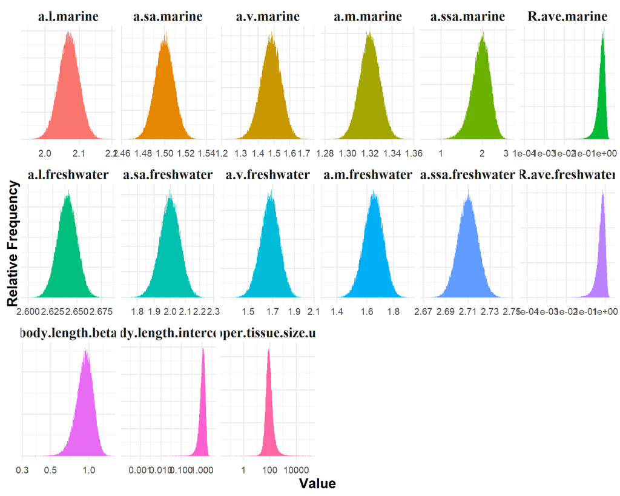

```r
MC_param_histograms <- param_values %>%
  pivot_longer(cols = everything()) %>%
  mutate(name = factor(name, levels = c("a.l.marine", "a.sa.marine", "a.v.marine",
                                        "a.m.marine", "a.ssa.marine", "R.ave.marine",
                                        "a.l.freshwater", "a.sa.freshwater", "a.v.freshwater",
                                        "a.m.freshwater", "a.ssa.freshwater",
                                        "R.ave.freshwater",
                                        "body.length.beta",
                                        "body.length.intercept",
                                        "upper.tissue.size.um"))) %>%
  ggplot(aes(x = value, fill = name)) +
  geom_histogram(bins = 350, linewidth = 0.10) +
  scale_x_log10()+
#  xlim(c(1,1000))+
  labs(#title = "Distribution of Simulated X50 Values",
       x = "Value",
       y = "Relative Frequency") +
  theme_minimal(base_size = 12) +
  theme(legend.position = "none",
        plot.title = element_blank(),
        plot.subtitle = element_text(hjust = 0.5),
        plot.caption = element_text(hjust = 0.5),   # Center the caption
        axis.title.x = element_text(hjust = 0.5, size = 16, face = "bold"),  # Center the x-axis title
        axis.text.x = element_text(size = 11),
        axis.text.y = element_blank(),
       # axis.text = element_text(size = 16),
        axis.title.y = element_text(vjust = 0.5, size = 16, face = "bold"),
       strip.text = element_text(size = 16, face = "bold", family = "serif")  # Customize facet title size
       )  + # Center the y-axis title
  facet_wrap(~name, scales = "free",
             ncol = 6)

MC_param_histograms
```

```r
ggsave(filename = "MC_param_histograms.jpg",
       dpi = 300,
       path = "../output/Manuscript_Figs/",
       plot = MC_param_histograms, width = 9, height = 8, units = "in")
```

#### 2.3.1.1 Import MC Analysis

MC performed in scripts/monte carlo/EcoTox_MonteCarlo.Rmd

```r
#regular MC
#MC_results <- readRDS("monte carlo/output/MC_results.rds")
#n_sim <- readRDS("monte carlo/output/n_sim.rds")
#n_sim

#sobol sequence generated data is used because the Latin Hypercube Sampling approach more robustly propagates uncertainties than the standard MC approach
#MC_results <- readRDS("monte carlo/output/MC_results_sobol.rds")

MC_results <- readRDS("monte carlo/output/sobol_results_filtered.rds")
#summary_stats_base_thresholds_MC <- readRDS("monte carlo/output/summary_stats_base_thresholds.rds")

summary_stats_base_thresholds_MC <- readRDS("monte carlo/output/summary_stats_base_thresholds_sobol.rds")

n_sim <- summary_stats_base_thresholds_MC$N_sim[1]

n_sim
```

```
## [1] 9400
```

#### 2.3.1.2 Pretty table summarizing MC results

###### 2.3.1.2.0.1 Particles/L

```r
library(scales)

## Freshwater MC
Freshwater_MC <- summary_stats_base_thresholds_MC %>%
  filter(str_detect(Metric, "Default"),
         Environment == "Freshwater") %>%
  select(Tier, Metric, Median, contains("Percentile")) %>%
  mutate(Threshold = paste0(comma(Median), " (", comma(Percentile_5th),
                            " to ", comma(Percentile_95th), ")")) %>%
  select(-c(Median, Percentile_5th, Percentile_95th)) %>%
  pivot_wider(names_from = Metric, values_from = Threshold) %>%
  rename_with(~ gsub("(Default)", "Freshwater", .x), everything())

# Marine MC
Marine_MC <-summary_stats_base_thresholds_MC %>%
  filter(str_detect(Metric, "Default"),
         Environment == "Marine") %>%
  select(Tier, Metric, Median, contains("Percentile")) %>%
  mutate(Threshold = paste0(comma(Median), " (", comma(Percentile_5th),
                            " to ", comma(Percentile_95th), ")")) %>%
  select(-c(Median, Percentile_5th, Percentile_95th)) %>%
  pivot_wider(names_from = Metric, values_from = Threshold) %>%
  rename_with(~ gsub("(Default)", "Marine", .x), everything())

simple_thresholds_MC <- left_join(Freshwater_MC, Marine_MC)

write.csv(simple_thresholds_MC,
          "../output/data/simple_thresholds_table.csv")

simple_thresholds_MC
```

```
## # A tibble: 4 × 5
##   Tier  Food Dilution (Freshwate…¹ Tissue Translocation…² Food Dilution (Marin…³
##   <chr> <chr>                      <chr>                  <chr>
## 1 Tier1 16 (2.9 to 47)             80 (33.7 to 121)       0.002 (0.0001 to 0.03)
## 2 Tier2 46 (8.7 to 137)            699 (378.0 to 992)     0.049 (0.0039 to 0.46)
## 3 Tier3 211 (38.3 to 651)          3,940 (2,280.0 to 5,6… 3.610 (0.2950 to 33.9…
## 4 Tier4 710 (137.0 to 2,250)       9,060 (5,610.0 to 12,… 22.800 (2.2500 to 169…
## # ℹ abbreviated names: ¹`Food Dilution (Freshwater)`,
## #   ²`Tissue Translocation (Freshwater)`, ³`Food Dilution (Marine)`
## # ℹ 1 more variable: `Tissue Translocation (Marine)` <chr>
```

###### 2.3.1.2.0.2 Percent RSD

```r
# Freshwater MC
MC_RSD <- summary_stats_base_thresholds_MC %>%
  filter(str_detect(Metric, "Default")) %>%
  select(Tier, Environment, Metric, Mean, Std_Dev) %>%
  mutate(Metric_Environment = paste(Metric, Environment)) %>%
  mutate(percent_RSD = paste0(signif(100 * (Std_Dev / Mean),3), "%")) %>%
  select(-c(Mean, Std_Dev, Environment, Metric)) %>%
  pivot_wider(names_from = Metric_Environment, values_from = percent_RSD) %>%
  rename_with(~ gsub("(Default)", "", .x), everything())

MC_RSD
```

```
## # A tibble: 4 × 5
##   Tier  Food Dilution () Freshwa…¹ Tissue Translocation…² Food Dilution () Mar…³
##   <chr> <chr>                      <chr>                  <chr>
## 1 Tier1 70.3%                      32.2%                  158%
## 2 Tier2 71.4%                      25.9%                  140%
## 3 Tier3 74.2%                      25.6%                  144%
## 4 Tier4 75.1%                      23.9%                  128%
## # ℹ abbreviated names: ¹`Food Dilution () Freshwater`,
## #   ²`Tissue Translocation () Freshwater`, ³`Food Dilution () Marine`
## # ℹ 1 more variable: `Tissue Translocation () Marine` <chr>
```

###### 2.3.1.2.0.3 ug/L

```r
library(scales)

## Freshwater MC
Freshwater_MC_mass <- summary_stats_base_thresholds_MC %>%
  filter(str_detect(Metric, "ug.L"),
         Environment == "Freshwater") %>%
  select(Tier, Metric, Median, contains("Percentile")) %>%
  mutate(Threshold = paste0(comma(Median), " (", comma(Percentile_5th),
                            " to ", comma(Percentile_95th), ")")) %>%
  select(-c(Median, Percentile_5th, Percentile_95th)) %>%
  pivot_wider(names_from = Metric, values_from = Threshold) %>%
  rename_with(~ gsub("ug.L", "Freshwater (ug/L)", .x), everything())

# Marine MC
Marine_MC_mass <- summary_stats_base_thresholds_MC %>%
  filter(str_detect(Metric, "ug.L"),
         Environment == "Marine") %>%
  select(Tier, Metric, Median, contains("Percentile")) %>%
  mutate(Threshold = paste0(comma(Median), " (", comma(Percentile_5th),
                            " to ", comma(Percentile_95th), ")")) %>%
  select(-c(Median, Percentile_5th, Percentile_95th)) %>%
  pivot_wider(names_from = Metric, values_from = Threshold) %>%
    rename_with(~ gsub("ug.L", "Marine (ug/L)", .x), everything())

simple_thresholds_MC_mass <- left_join(Freshwater_MC_mass, Marine_MC_mass,
                                             by = "Tier")

write.csv(simple_thresholds_MC_mass,
          "../output/data/simple_thresholds_MC_mass.csv")

simple_thresholds_MC_mass
```

```
## # A tibble: 4 × 5
##   Tier  food_dilution_Freshwater…¹ tissue_translocation…² food_dilution_Marine…³
##   <chr> <chr>                      <chr>                  <chr>
## 1 Tier1 0.12 (0.007 to 2.0)        0.59 (0.049 to 8.0)    0.02 (0.001 to 0.3)
## 2 Tier2 0.33 (0.020 to 5.6)        5.30 (0.456 to 70.3)   0.47 (0.036 to 4.3)
## 3 Tier3 1.50 (0.086 to 25.7)       30.10 (2.580 to 397.0) 34.30 (2.780 to 328.0)
## 4 Tier4 5.13 (0.297 to 88.3)       69.80 (6.020 to 924.0) 216.00 (21.200 to 1,6…
## # ℹ abbreviated names: ¹`food_dilution_Freshwater (ug/L)`,
## #   ²`tissue_translocation_Freshwater (ug/L)`, ³`food_dilution_Marine (ug/L)`
## # ℹ 1 more variable: `tissue_translocation_Marine (ug/L)` <chr>
```

###### 2.3.1.2.0.4 Metadata

```r
## Freshwater MC
Freshwater_MC_meta <- summary_stats_base_thresholds_MC %>%
  filter(str_detect(Metric, "N"),
         Environment == "Freshwater") %>%
  select(Tier, Metric, Median, contains("Percentile")) %>%
  mutate(Threshold = paste0(comma(Median), " (", comma(Percentile_5th),
                            " to ", comma(Percentile_95th), ")")) %>%
  select(-c(Median, Percentile_5th, Percentile_95th)) %>%
  pivot_wider(names_from = Metric, values_from = Threshold) %>%
  rename_with(~ gsub("N", "Freshwater", .x), everything())

# Marine MC
Marine_MC_meta <-summary_stats_base_thresholds_MC %>%
 filter(str_detect(Metric, "N"),
         Environment == "Marine") %>%
  select(Tier, Metric, Median, contains("Percentile")) %>%
  mutate(Threshold = paste0(comma(Median), " (", comma(Percentile_5th),
                            " to ", comma(Percentile_95th), ")")) %>%
  select(-c(Median, Percentile_5th, Percentile_95th)) %>%
  pivot_wider(names_from = Metric, values_from = Threshold) %>%
  rename_with(~ gsub("N", "Marine", .x), everything())

simple_thresholds_MC_meta <- left_join(Freshwater_MC_meta, Marine_MC_meta)

write.csv(simple_thresholds_MC_meta,
          "../output/data/simple_thresholds_table_meta.csv")

simple_thresholds_MC_meta
```

```
## # A tibble: 4 × 13
##   Tier  Freshwater Datapoints (f…¹ Freshwater Datapoint…² Freshwater Groups (f…³
##   <chr> <chr>                      <chr>                  <chr>
## 1 Tier1 122 (122 to 123)           124 (108 to 133)       3 (3 to 3)
## 2 Tier2 122 (122 to 123)           124 (108 to 133)       3 (3 to 3)
## 3 Tier3 105 (105 to 106)           98 (82 to 107)         3 (3 to 3)
## 4 Tier4 105 (105 to 106)           98 (82 to 107)         3 (3 to 3)
## # ℹ abbreviated names: ¹`Freshwater Datapoints (food dilution)`,
## #   ²`Freshwater Datapoints (tissue trans)`,
## #   ³`Freshwater Groups (food dilution)`
## # ℹ 9 more variables: `Freshwater Groups (tissue trans)` <chr>,
## #   `Freshwater Species (food dilution)` <chr>,
## #   `Freshwater Species (tissue trans)` <chr>,
## #   `Marine Datapoints (food dilution)` <chr>, …
```

```r
#aoc_MC <- readRDS("monte carlo/output/aoc_MC.rds")
aoc_MC <- readRDS("monte carlo/output/aoc_MC_sobol.rds")
#n_sim <- aoc_MC$n_sim[[1]]

print(paste("Number of MC Simulations:", n_sim))
```

```
## [1] "Number of MC Simulations: 9400"
```

### 2.3.2 Alignment Monte-Carlo Simulation

#### 2.3.2.1 Test code with static values

### 2.3.3 Threshold distributions

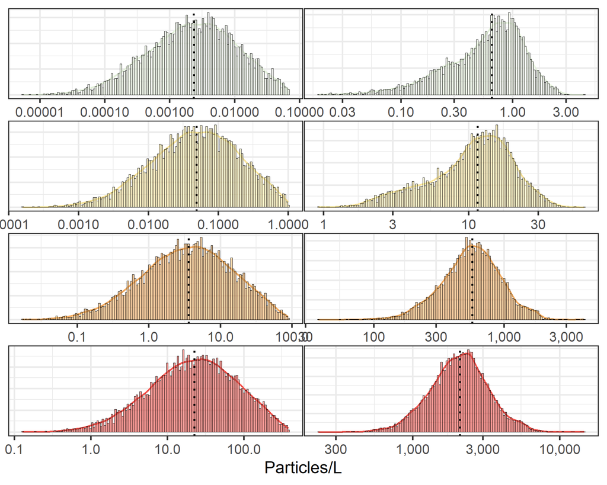

```r
all_thresholds_long <- readRDS("monte carlo/output/all_thresholds_sobol_long_filtered.rds")

# Calculate summary statistics
summary_stats_base_thresholds <- all_thresholds_long %>%
  group_by(Tier, Environment, Metric) %>%
  summarise(
    Mean = mean(Value, na.rm = TRUE),
    Median = median(Value, na.rm = TRUE),
    Std_Dev = sd(Value, na.rm = TRUE),
    N_sim = n(),
    .groups = 'drop'
  )

### Ggplot of SSD Tier Thresholds
# Prepare the data by calculating ERM and filtering
all_MC_data_long <- all_thresholds_long %>%
  mutate(ERM = case_when(
    grepl("Tissue", Metric) ~ "Tissue Translocation",
    grepl("Food", Metric) ~ "Food Dilution"
  ))

prepared_data <-  all_MC_data_long %>%
  filter(
    grepl("Default", Metric),
    Environment == "Marine"
  )

# Calculate median values for each group
median_data <- prepared_data %>%
  group_by(Tier, ERM) %>%
  summarise(Median = median(Value), .groups = 'drop')

# Assign specific colors based on Tier levels
tier_colors <- setNames(c("#e2efd9", "#f9e39c", "#f0a95f", "#f0514b"), levels(prepared_data$Tier))

MC_histograms_base <- ggplot(prepared_data, aes(x = Value)) +
  geom_density(aes(color = Tier), size = 1) +  # Map 'Tier' for color
  geom_histogram(aes(y = ..density.., fill = Tier), bins = 150, color = "black", alpha = 0.6, linewidth = 0.05) +  # Map 'Tier' for fill
  geom_vline(data = median_data, aes(xintercept = Median),
             linetype = "dotted", color = "black", linewidth = 1.2) +
#  geom_text(data = median_data, aes(x = Median, y = 0, label = paste0("Median:", scientific(Median, 2))),
        #    hjust = +1.5, vjust = -1.5, color = "black", size = 6, fontface = "italic") +
  xlab("Particles/L") +
  scale_x_log10(labels = scales::comma) +
  facet_wrap(~ Tier + ERM, scales = "free", ncol = 2) +
  scale_fill_manual(values = tier_colors) +  # Apply manual colors for fill
  scale_color_manual(values = tier_colors)  # Apply manual colors for lines

#library(ggdark)
MC_histograms_dark <- MC_histograms_base +
  theme_bw(base_size = 20) +
 # dark_theme_bw(base_size = 20) +
  theme(
    strip.background = element_blank(),
    strip.placement = "outside",
    legend.position = "none",
    strip.text = element_blank(),  # This hides the facet wrap titles
    #  strip.text = element_text(face = "bold", size = 16, margin = margin(t = 1, b = 1)),
    panel.spacing = unit(0.1, "lines"),
    axis.text.y = element_blank(),
    axis.title.y = element_blank(),
    axis.ticks.y = element_blank()
  )

MC_histograms_light <- MC_histograms_base +
  theme_bw(base_size = 20) +
  theme(
    strip.background = element_blank(),
    strip.placement = "outside",
    legend.position = "none",
    strip.text = element_blank(),  # This hides the facet wrap titles
 #  strip.text = element_text(face = "bold", size = 16, margin = margin(t = 1, b = 1)),
    panel.spacing = unit(0.1, "lines"),
    axis.text.y = element_blank(),
    axis.title.y = element_blank(),
    axis.ticks.y = element_blank()
  )


ggsave("../output/Manuscript_Figs/MC_histograms.png",
       MC_histograms_light,
      dpi = 300,
      width = 12, height = 9, units = "in")

ggsave("../output/presentation_Figs/MC_histograms.png",
       MC_histograms_dark,
       dpi = 300,
       width = 10, height = 5,
       units = "in")

MC_histograms_light
```

#### 2.3.3.1 Comparison of MC and Deterministic Thresholds

```r
### MARINE ##
base_tissue_marine <- data.frame(Tier = c("1", "2", "3", "4"),
                          ERM = "Tissue Translocation",
                          Environment = "Marine",
                          PNEC = marine_only_thresholds$base_thresholds$`Tissue Translocation (Default)`,
                          PNEClcl = marine_only_thresholds$base_thresholds$`Tissue Translocation (5th %)`,
                          PNECucl = marine_only_thresholds$base_thresholds$`Tissue Translocation (95th %)`)

base_food_marine <- data.frame(Tier = c("1", "2", "3", "4"),
                        ERM = "Food Dilution",
                        Environment = "Marine",
                        PNEC = marine_only_thresholds$base_thresholds$`Food Dilution (Default)`,
                        PNEClcl = marine_only_thresholds$base_thresholds$`Food Dilution (5th %)`,
                        PNECucl = marine_only_thresholds$base_thresholds$`Food Dilution (95th %)`)


#### FRESHWATER ####
base_tissue_freshwater <- data.frame(Tier = c("1", "2", "3", "4"),
                          ERM = "Tissue Translocation",
                          Environment = "Freshwater",
                          PNEC = freshwater_only_thresholds$base_thresholds$`Tissue Translocation (Default)`,
                          PNEClcl = freshwater_only_thresholds$base_thresholds$`Tissue Translocation (5th %)`,
                          PNECucl = freshwater_only_thresholds$base_thresholds$`Tissue Translocation (95th %)`)

base_food_freshwater <- data.frame(Tier = c("1", "2", "3", "4"),
                        ERM = "Food Dilution",
                        Environment = "Freshwater",
                        PNEC = freshwater_only_thresholds$base_thresholds$`Food Dilution (Default)`,
                        PNEClcl = freshwater_only_thresholds$base_thresholds$`Food Dilution (5th %)`,
                        PNECucl = freshwater_only_thresholds$base_thresholds$`Food Dilution (95th %)`)

base_thresholds_df <- bind_rows(base_tissue_marine, base_food_marine, base_tissue_freshwater, base_food_freshwater) %>%
    mutate(y_position = case_when(
    ERM == "Tissue Translocation" & Environment == "Freshwater" ~ 2,  # Offset for Tissue Translocation
    ERM == "Tissue Translocation" & Environment == "Marine" ~ 0.9,  # Offset for Tissue Translocation
    ERM == "Food Dilution" & Environment == "Freshwater" ~ 1.6,  # Offset for Tissue Translocation
    ERM == "Food Dilution" & Environment == "Marine" ~ 0.5,  # Offset for Tissue Translocation
  ))

base_thresholds_df
```

```
##    Tier                  ERM Environment         PNEC      PNEClcl      PNECucl
## 1     1 Tissue Translocation      Marine 9.499309e-01           NA           NA
## 2     2 Tissue Translocation      Marine 1.547605e+01 9.360153e-01   461.991452
## 3     3 Tissue Translocation      Marine 6.496222e+02 1.437714e+02  8295.375208
## 4     4 Tissue Translocation      Marine 2.322275e+03 4.417942e+02 25222.795301
## 5     1        Food Dilution      Marine 2.563820e-03           NA           NA
## 6     2        Food Dilution      Marine 5.934983e-02 2.743653e-03     9.830994
## 7     3        Food Dilution      Marine 3.640033e+00 4.254834e-01   374.781416
## 8     4        Food Dilution      Marine 2.511694e+01 2.356964e+00  2237.915386
## 9     1 Tissue Translocation  Freshwater 1.711500e+02           NA           NA
## 10    2 Tissue Translocation  Freshwater 7.253207e+02 9.820839e+01 30598.354048
## 11    3 Tissue Translocation  Freshwater 4.031064e+03 1.377843e+03 44404.648436
## 12    4 Tissue Translocation  Freshwater 9.031252e+03 3.375403e+03 99172.072586
## 13    1        Food Dilution  Freshwater 1.999806e+01           NA           NA
## 14    2        Food Dilution  Freshwater 5.508979e+01 1.911856e+01   703.726916
```

[output cut: 19 more lines]

#### 2.3.3.2 Tier 2

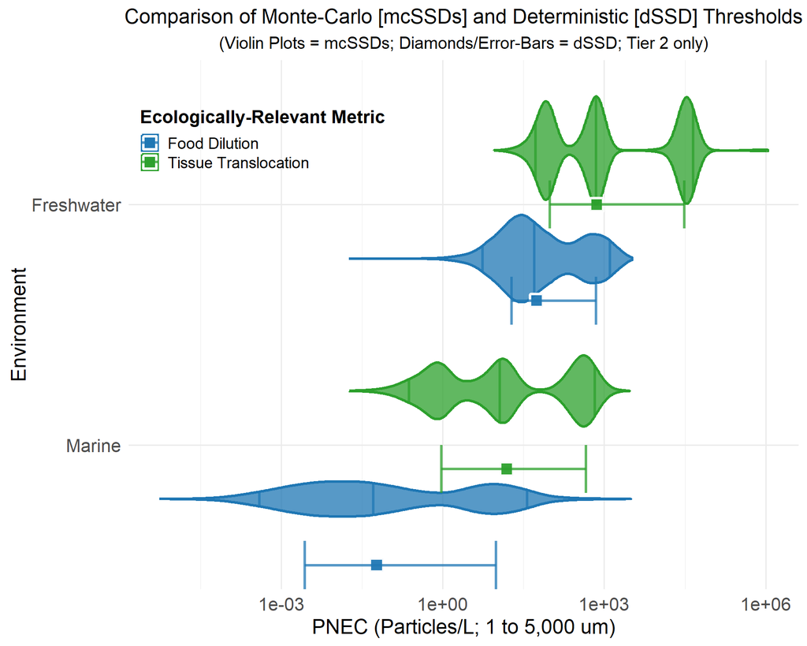

```r
library(cols4all)
#data prep
t2f_marine <- all_MC_data_long  %>%
  filter(ERM == "Food Dilution",
         Tier == "Tier2",
         Environment == "Marine") %>%
  rename(PNEC = Value) %>%
  mutate(Environment = as.factor(Environment))

#data prep
t2f_freshwater <- all_MC_data_long  %>%
  filter(ERM == "Food Dilution",
         Tier == "Tier2",
         Environment == "Freshwater") %>%
  rename(PNEC = Value) %>%
  mutate(Environment = as.factor(Environment))

#data prep
t2t_marine <- all_MC_data_long  %>%
  filter(ERM == "Tissue Translocation",
         Tier == "Tier2",
         Environment == "Marine") %>%
  rename(PNEC = Value) %>%
  mutate(Environment = as.factor(Environment))

#data prep
t2t_freshwater <- all_MC_data_long  %>%
  filter(ERM == "Tissue Translocation",
         Tier == "Tier2",
         Environment == "Freshwater") %>%
  rename(PNEC = Value) %>%
  mutate(Environment = as.factor(Environment))



## join DFs
PNEC_dfs <- rbind(t2f_marine, t2f_freshwater, t2t_marine, t2t_freshwater) %>%
 mutate(y_position = (as.numeric(factor(Environment)) - 2) + (as.numeric(factor(ERM)) - 1.5) * 0.4)  # Adjust 0.1 or other value as needed

#plot
PNEC_MCSSDvSSD <- ggplot() +
   geom_violin(data = PNEC_dfs, aes(x = PNEC, y = Environment, fill = ERM, color = ERM),
               draw_quantiles = c(0.05, 0.5, 0.95), linewidth = 1.2,
               alpha = 0.75) +
   # geom_jitter(data = PNEC_dfs, aes(x = PNEC, y = y_position, fill = ERM, color = ERM),
   #             height = 0.15, size = 1.5, alpha = 0.02) +  # Jittered points
   geom_point(data = base_thresholds_df %>% filter(Tier == 2),
              aes(x = PNEC, y = y_position, fill = ERM),
              size = 5, shape = 22,
              color = "white",
              alpha = 0.95,
              stroke = 1.8 #thickness of outline
              ) +
   geom_errorbarh(data = base_thresholds_df %>% filter(Tier == 2),
                  aes(xmin = PNEClcl, xmax = PNECucl, y = y_position, fill = ERM, color = ERM),
                  height = 0.2,
                  alpha = 0.75,
                  linewidth = 1.2) +
  scale_color_discrete_c4a_cat() +
  scale_fill_discrete_c4a_cat()+
  scale_x_log10() +
 #  scale_x_log10(breaks = c(0.01, 0.1, 1, 10, 100, 1000, 10000, 1000000, 10000000),
                 #limits = c(0.001, 10000000),
  #               labels = scales::label_comma()) +
  labs(title = "Comparison of Monte-Carlo [mcSSDs] and Deterministic [dSSD] Thresholds",
       subtitle = "(Violin Plots = mcSSDs; Diamonds/Error-Bars = dSSD; Tier 2 only)",
       fill = "Ecologically-Relevant Metric",
       color = "Ecologically-Relevant Metric"
       ) +
  xlab("PNEC (Particles/L; 1 to 5,000 um)") +
  ylab("Environment")

PNEC_MCSSDvSSD_dark <- PNEC_MCSSDvSSD + theme.dark
PNEC_MCSSDvSSD_light <- PNEC_MCSSDvSSD + theme.light

# ggsave(filename = "PNEC_pSSDvSSD.tiff",
#        path = "../output/presentation_Figs/",
#        plot = PNEC_pSSDvSSD_dark, width = 12, height = 10, units = "in")

ggsave(filename = "PNEC_pSSDvSSD.jpg",
       path = "../output/presentation_Figs/",
       plot = PNEC_MCSSDvSSD_dark, width = 12, height = 10, units = "in")

ggsave(filename = "PNEC_MCSSDvSSD.tiff",
       path = "../output/Manuscript_Figs/",
       plot = PNEC_MCSSDvSSD_light, width = 10, height = 8, units = "in")

ggsave(filename = "PNEC_MCSSDvSSD.jpg",
       path = "../output/Manuscript_Figs/",
       plot = PNEC_MCSSDvSSD_light, width = 10, height = 8, units = "in")

PNEC_MCSSDvSSD_light
```

#### 2.3.3.3 Tier 3

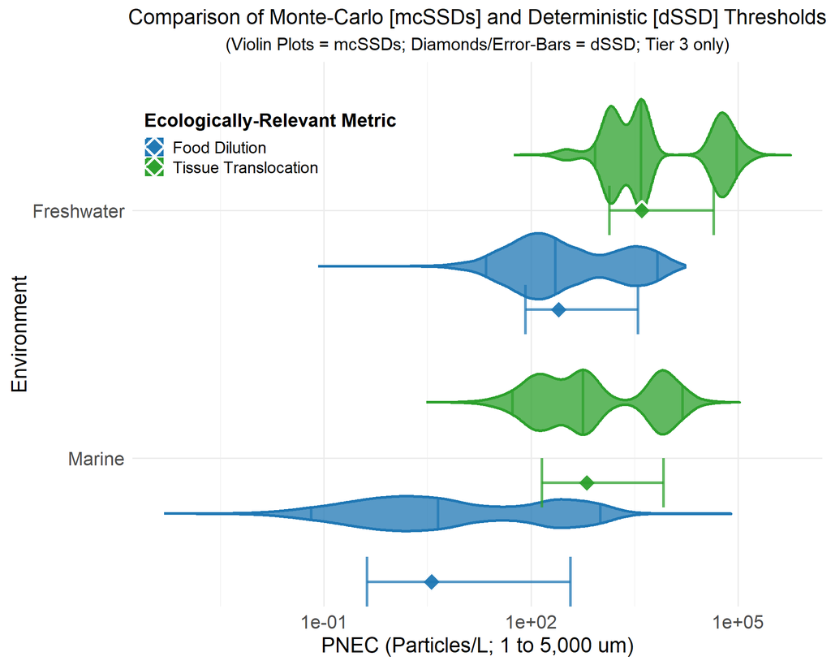

```r
library(cols4all)
#data prep
t3f_marine <- all_MC_data_long  %>%
  filter(ERM == "Food Dilution",
         Tier == "Tier3",
         Environment == "Marine") %>%
  rename(PNEC = Value) %>%
  mutate(Environment = as.factor(Environment))

#data prep
t3f_freshwater <- all_MC_data_long  %>%
  filter(ERM == "Food Dilution",
         Tier == "Tier3",
         Environment == "Freshwater") %>%
  rename(PNEC = Value) %>%
  mutate(Environment = as.factor(Environment))

#data prep
t3t_marine <- all_MC_data_long  %>%
  filter(ERM == "Tissue Translocation",
         Tier == "Tier3",
         Environment == "Marine") %>%
  rename(PNEC = Value) %>%
  mutate(Environment = as.factor(Environment))

#data prep
t3t_freshwater <- all_MC_data_long  %>%
  filter(ERM == "Tissue Translocation",
         Tier == "Tier3",
         Environment == "Freshwater") %>%
  rename(PNEC = Value) %>%
  mutate(Environment = as.factor(Environment))



## join DFs
PNEC_dfs <- rbind(t3f_marine, t3f_freshwater, t3t_marine, t3t_freshwater) %>%
 mutate(y_position = (as.numeric(factor(Environment)) - 2) + (as.numeric(factor(ERM)) - 1.5) * 0.4)  # Adjust 0.1 or other value as needed

#plot
PNEC_MCSSDvSSD <- ggplot() +
   geom_violin(data = PNEC_dfs, aes(x = PNEC, y = Environment, fill = ERM, color = ERM),
               draw_quantiles = c(0.05, 0.5, 0.95), linewidth = 1.2,
               alpha = 0.75) +
   # geom_jitter(data = PNEC_dfs, aes(x = PNEC, y = y_position, fill = ERM, color = ERM),
   #             height = 0.15, size = 1.5, alpha = 0.03) +  # Jittered points
   geom_point(data = base_thresholds_df %>% filter(Tier == 3),
              aes(x = PNEC, y = y_position, fill = ERM),
              size = 5, shape = 23,
              color = "white",
              alpha = 0.95,
              stroke = 1.8 #thickness of outline
              ) +
   geom_errorbarh(data = base_thresholds_df %>% filter(Tier == 3),
                  aes(xmin = PNEClcl, xmax = PNECucl, y = y_position, fill = ERM, color = ERM),
                  height = 0.2,
                  alpha = 0.75,
                  linewidth = 1.2) +
  scale_color_discrete_c4a_cat() +
  scale_fill_discrete_c4a_cat()+
  scale_x_log10() +
 #  scale_x_log10(breaks = c(0.01, 0.1, 1, 10, 100, 1000, 10000, 1000000, 10000000),
                 #limits = c(0.001, 10000000),
  #               labels = scales::label_comma()) +
  labs(title = "Comparison of Monte-Carlo [mcSSDs] and Deterministic [dSSD] Thresholds",
       subtitle = "(Violin Plots = mcSSDs; Diamonds/Error-Bars = dSSD; Tier 3 only)",
       fill = "Ecologically-Relevant Metric",
       color = "Ecologically-Relevant Metric"
       ) +
  xlab("PNEC (Particles/L; 1 to 5,000 um)") +
  ylab("Environment")

PNEC_MCSSDvSSD_dark <- PNEC_MCSSDvSSD + theme.dark
PNEC_MCSSDvSSD_light_t3 <- PNEC_MCSSDvSSD + theme.light

# ggsave(filename = "PNEC_pSSDvSSD.tiff",
#        path = "../output/presentation_Figs/",
#        plot = PNEC_pSSDvSSD_dark, width = 12, height = 10, units = "in")

ggsave(filename = "PNEC_pSSDvSSD.jpg",
       path = "../output/presentation_Figs/",
       plot = PNEC_MCSSDvSSD_dark, width = 12, height = 10, units = "in")

ggsave(filename = "PNEC_MCSSDvSSD_t3.tiff",
       path = "../output/Manuscript_Figs/",
       plot = PNEC_MCSSDvSSD_light_t3, width = 10, height = 8, units = "in")

ggsave(filename = "PNEC_MCSSDvSSD_t3.jpg",
       path = "../output/Manuscript_Figs/",
       plot = PNEC_MCSSDvSSD_light_t3, width = 10, height = 8, units = "in")

PNEC_MCSSDvSSD_light_t3
```

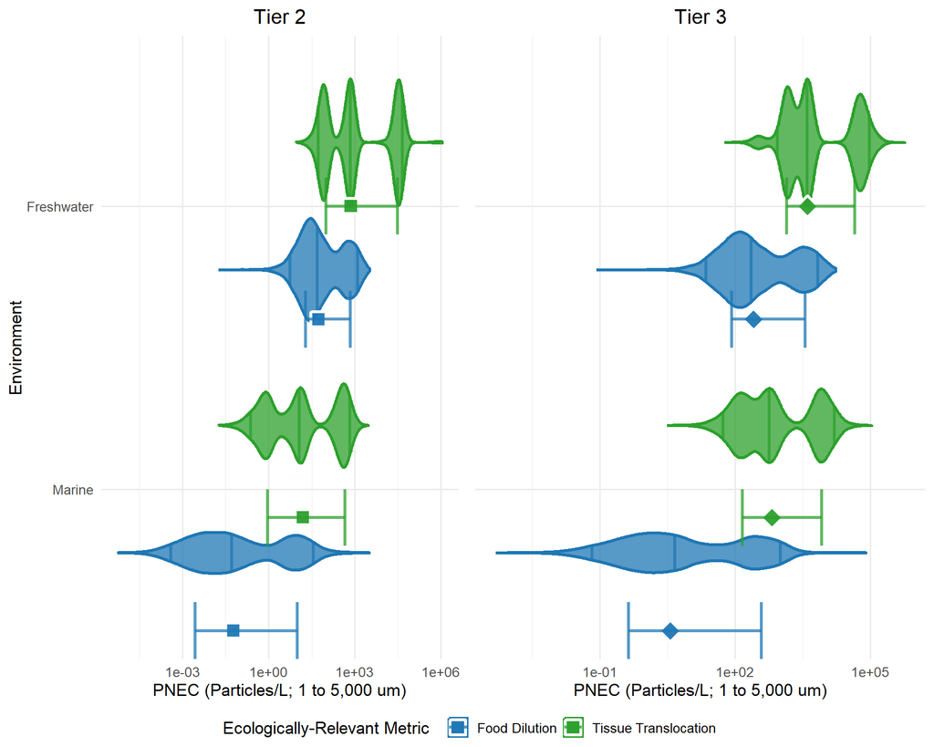

```r
summary_PNEC_figure <- ggarrange(PNEC_MCSSDvSSD_light + labs(subtitle = "", title = "Tier 2") +
                                   theme_minimal(base_size = 13) +
                                   theme(plot.subtitle =  element_blank(),  plot.title = element_text(hjust = 0.5)),
          PNEC_MCSSDvSSD_light_t3 + labs(subtitle = "", title = "Tier 3",) + theme_minimal(base_size = 13) +
            theme(plot.subtitle = element_blank(), plot.title = element_text(hjust = 0.5),
                                                                                  axis.text.y = element_blank(),
                                                                                  axis.title.y = element_blank()),
          nrow = 1,
          common.legend = T,
          legend = "bottom")

ggsave(filename = "summary_PNEC_figure.jpg",
       dpi = 400,
       path = "../output/Manuscript_Figs/",
       plot = summary_PNEC_figure, width = 8, height = 5, units = "in")

summary_PNEC_figure
```

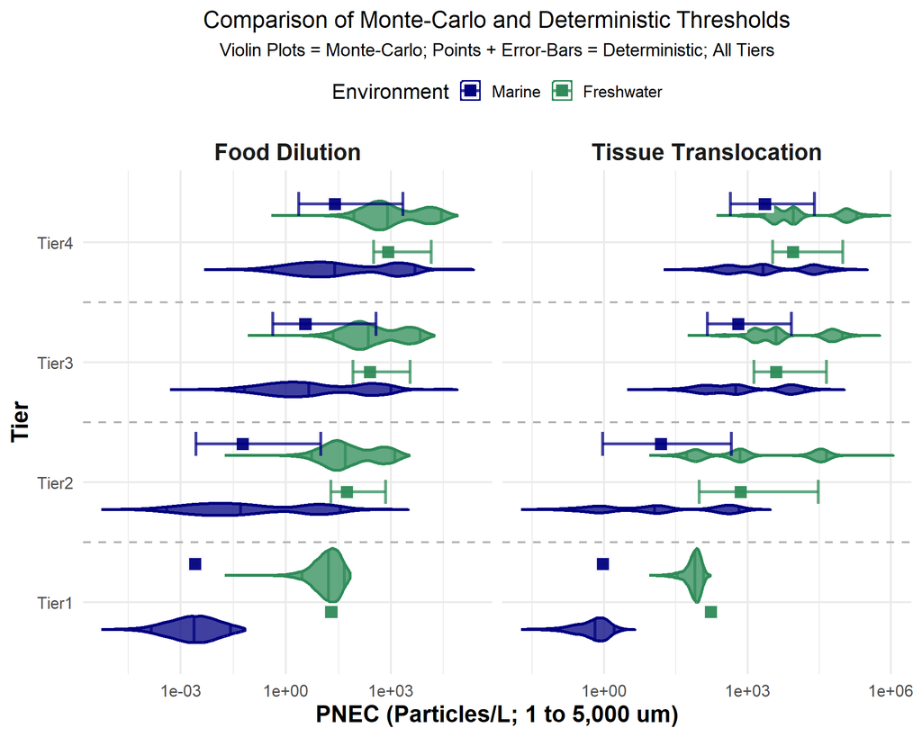

```r
library(ggplot2)
library(dplyr)
library(cols4all)
library(ggpubr)

# Data Preparation for All Tiers
prepare_data <- function(tier, erm, environment) {
  all_MC_data_long %>%
    filter(ERM == erm, Tier == tier, Environment == environment) %>%
    rename(PNEC = Value) %>%
    mutate(Environment = as.factor(Environment))
}

# Combine data for all tiers
all_tiers_data <- bind_rows(
  prepare_data("Tier2", "Food Dilution", "Marine"),
  prepare_data("Tier2", "Food Dilution", "Freshwater"),
  prepare_data("Tier2", "Tissue Translocation", "Marine"),
  prepare_data("Tier2", "Tissue Translocation", "Freshwater"),
  prepare_data("Tier3", "Food Dilution", "Marine"),
  prepare_data("Tier3", "Food Dilution", "Freshwater"),
  prepare_data("Tier3", "Tissue Translocation", "Marine"),
  prepare_data("Tier3", "Tissue Translocation", "Freshwater"),
  prepare_data("Tier4", "Food Dilution", "Marine"),
  prepare_data("Tier4", "Food Dilution", "Freshwater"),
  prepare_data("Tier4", "Tissue Translocation", "Marine"),
  prepare_data("Tier4", "Tissue Translocation", "Freshwater"),
  prepare_data("Tier1", "Food Dilution", "Marine"),
  prepare_data("Tier1", "Food Dilution", "Freshwater"),
  prepare_data("Tier1", "Tissue Translocation", "Marine"),
  prepare_data("Tier1", "Tissue Translocation", "Freshwater")
) %>%
  mutate(
    y_position = as.numeric(factor(Tier)) +
      (as.numeric(factor(Environment)) - 0.5) * 1.5
  )

# Create the plot
# Create the plot
final_plot <- ggplot() +
  # Violin plots for Monte Carlo SSDs
  geom_violin(
    data = all_tiers_data,
    aes(x = PNEC, y = Tier, fill = Environment, color = Environment),
    draw_quantiles = c(0.05, 0.5, 0.95),
    linewidth = 1.2,
    alpha = 0.75
  ) +
  # Points for deterministic SSDs
  geom_point(
    data = base_thresholds_df,
    aes(x = PNEC, y = as.numeric(factor(Tier)) +
          (as.numeric(factor(Environment)) - 1.2) * 0.4, fill = Environment),
    size = 5,
    shape = 22,
    color = "white",
    alpha = 0.95,
    stroke = 1.8
  ) +
  # Error bars for deterministic SSDs
  geom_errorbarh(
    data = base_thresholds_df,
    aes(
      xmin = PNEClcl,
      xmax = PNECucl,
      y = as.numeric(factor(Tier)) +
        (as.numeric(factor(Environment)) - 1.2) * 0.4,
      fill = Environment,
      color = Environment
    ),
    height = 0.2,
    alpha = 0.75,
    linewidth = 1.2
  ) +
    # Add horizontal lines between categories
  geom_hline(
    yintercept = seq(1.5, length(unique(all_tiers_data$Tier)) - 0.5, by = 1),
    color = "gray70",
    linetype = "dashed",
    linewidth = 0.8
  ) +
  # Color scales
  scale_color_manual(values = c("Marine" = "navyblue", "Freshwater" = "seagreen")) +
  scale_fill_manual(values = c("Marine" = "navyblue", "Freshwater" = "seagreen")) +
  # Log scale for x-axis
  scale_x_log10() +
  # Labels and titles
  labs(
    title = "Comparison of Monte-Carlo and Deterministic Thresholds",
    subtitle = "Violin Plots = Monte-Carlo; Points + Error-Bars = Deterministic; All Tiers",
    fill = "Environment",
    color = "Environment",
    x = "PNEC (Particles/L; 1 to 5,000 um)",
    y = "Tier"
  ) +
  # Facet with free x-axis scales
  facet_wrap(~ERM, scales = "free_x") +
  # Themes
  theme_minimal(base_size = 16) +
  theme(
    plot.title = element_text(hjust = 0.5, size = 18),
    plot.subtitle = element_text(hjust = 0.5, size = 14),
    legend.position = "top",
    strip.text = element_text(size = 18, face = "bold"), # Bold and larger facet titles
    axis.title.y = element_text(size = 18, face = "bold"), # Bold and larger y-axis title
    axis.title.x = element_text(size = 18, face = "bold") # Bold and larger y-axis title
  )

# Save the plot
ggsave(
  filename = "final_plot_all_tiers.jpg",
  plot = final_plot,
  path = "../output/Manuscript_Figs/",
  width = 12,
  height = 8,
  units = "in",
  dpi = 300
)

# Display the plot
print(final_plot)
```

### 2.3.4 CoV Determination

### 2.3.5 IMPORT DATA

```r
getwd()
```

```
## [1] "C:/Users/Scott.Coffin/R_new/ToMEx2.0_EcoToxRisk/scripts"
```

```r
aoc_MC <- readRDS("monte carlo/output/aoc_MC_sobol.rds")
results_df <- readRDS("monte carlo/output/results_df_sobol.rds")
```

#### 2.3.5.1 CoV Plots

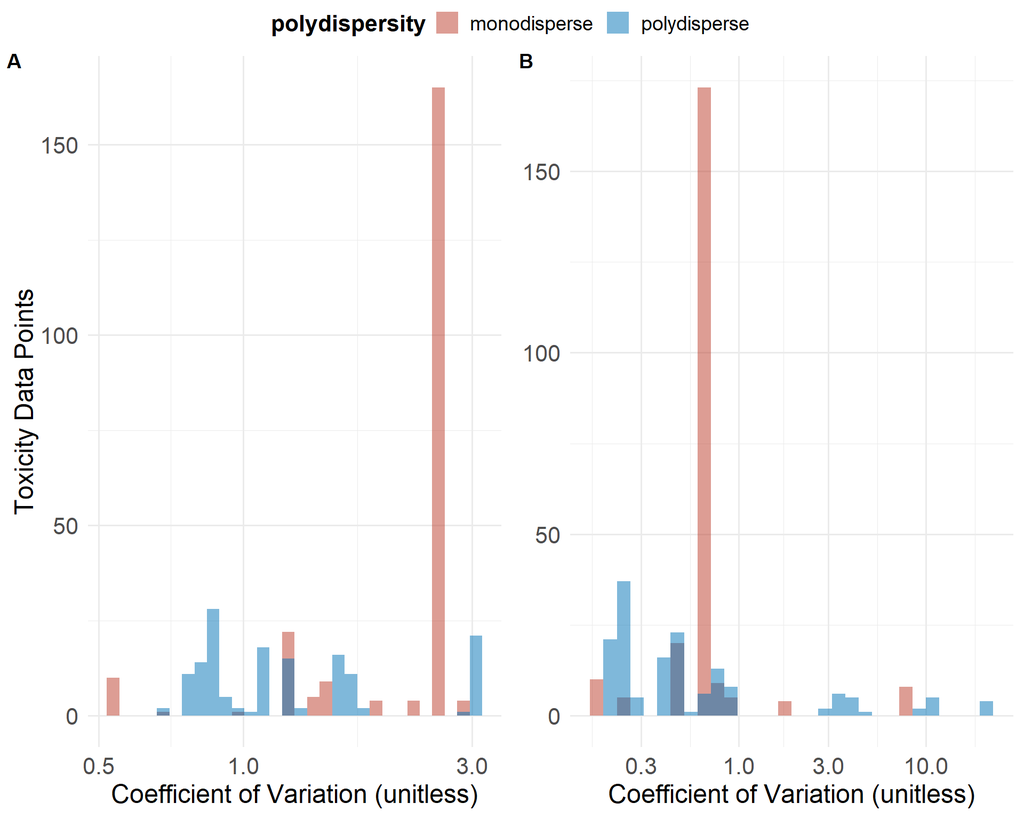

```r
#define limits
min_val <- min(aoc_MC$CoV_food_dilution, na.rm = TRUE)
max_val <- max(aoc_MC$CoV_food_dilution, na.rm = TRUE)

# You may want to add some padding around the min and max
pad <- (max_val - min_val) * 0.05
xlims <- c(min_val - pad, max_val + pad)

hist_cv_food <- aoc_MC %>%
   filter(ingestible %in% c("ingestible", "ingestible (all)", "ingestible (some)"),
         Group != "Algae") %>%
  filter(particles_L_food_dilution_deterministic > 0) %>%
  drop_na(particles_L_food_dilution_deterministic) %>%
  ggplot(aes(x = CoV_food_dilution, fill = polydispersity)) +
  geom_histogram(position = "identity", alpha = 0.5) +
 # xlim(xlims) +  # Set x limits
  scale_x_log10() +
  xlab("Coefficient of Variation (unitless)") +
  ylab("Toxicity Data Points") +
  fill.type +
  theme.light #+
  #theme(axis.title.x = element_blank())

hist_cv_ox <- aoc_MC %>%
   filter(translocatable %in% c("translocatable", "translocatable (all)", "translocatable (some)")) %>%
  filter(particles_L_ox_stress_deterministic > 0) %>%
  drop_na(particles_L_ox_stress_deterministic) %>%
  ggplot(aes(x = CoV_ox_stress, fill = polydispersity)) +
  geom_histogram(position = "identity", alpha = 0.5) +
  fill.type +
  scale_x_log10() +
 # xlim(xlims) +  # Set x limits
  xlab("Coefficient of Variation (unitless)") +
  ylab("Toxicity Data Points") +
  theme.light +
  theme(legend.position = "none",
        axis.title.y = element_blank())

CoV_plots <- ggarrange(hist_cv_food, hist_cv_ox,
                       labels = c("A", "B"),
                       ncol = 2,
                       common.legend = TRUE, legend = "top")

ggsave(filename = "CoV_plots.jpg",
       dpi = 300,
       path = "../output/Manuscript_Figs/",
       plot = CoV_plots, width = 10, height = 8, units = "in")

CoV_plots
```

##### 2.3.5.1.1 CoV Distributions

```r
food_CoV_summary <- aoc_MC %>%
   filter(ingestible %in% c("ingestible", "ingestible (all)", "ingestible (some)"),
         Group != "Algae") %>%
  filter(particles_L_food_dilution_deterministic > 0) %>%
  drop_na(particles_L_food_dilution_deterministic) %>%
  group_by(environment) %>%
  summarize(min = min(CoV_food_dilution, na.rm = T),
            max = max(CoV_food_dilution, na.rm = T),
            median = median(CoV_food_dilution, na.rm = T),
            sd = sd(CoV_food_dilution, na.rm = T)) %>%
  mutate(ERM = "Food Dilution")

tissue_CoV_summary <- aoc_MC %>%
   filter(translocatable %in% c("translocatable", "translocatable (all)", "translocatable (some)")) %>%
  filter(particles_L_ox_stress_deterministic > 0) %>%
  drop_na(particles_L_ox_stress_deterministic) %>%
  group_by(environment) %>%
  summarize(min = min(CoV_ox_stress, na.rm = T),
            max = max(CoV_ox_stress, na.rm = T),
            median = median(CoV_ox_stress, na.rm = T),
            sd = sd(CoV_ox_stress, na.rm = T)) %>%
  mutate(ERM = "Tissue Translocation")

CoV_distribution_summary <- bind_rows(food_CoV_summary, tissue_CoV_summary) %>%
  mutate_if(is.numeric, ~signif(., 2))

write.csv(CoV_distribution_summary, "../data/output/CoV_distribution_summary.csv")

CoV_distribution_summary
```

```
## # A tibble: 4 × 6
##   environment   min   max median    sd ERM
##   <fct>       <dbl> <dbl>  <dbl> <dbl> <chr>
## 1 Freshwater   0.54   1.6   1.1   0.29 Food Dilution
## 2 Marine       0.67   3.1   2.6   0.44 Food Dilution
## 3 Freshwater   0.17  21     0.29  4    Tissue Translocation
## 4 Marine       0.37   4.1   0.66  0.67 Tissue Translocation
```

```r
#define limites
#define limits
min_val <- aoc_MC %>%
  select(contains("CoV_")) %>%
  min(na.rm = T)%>%
  round(0)

max_val <- aoc_MC %>%
  select(contains("CoV_")) %>%
  max(na.rm = T) %>%
  round(0)

# min_val <- min(aoc_MC$CoV_food_dilution, na.rm = TRUE)
# max_val <- max(aoc_MC$CoV_food_dilution, na.rm = TRUE)

# You may want to add some padding around the min and max
pad <- (max_val - min_val) * 0.05
xlims <- c(min_val - pad, max_val + pad)

points_cv_food <- aoc_MC %>%
  ggplot(aes(y = CoV_food_dilution, x = size.length.um.used.for.conversions, color = polydispersity)) +
  geom_point(size = 3, alpha = 0.8) +
  xlim(xlims) +  # Set x limits
  color.type +
  theme_minimal(base_size = 12)

points_cv_ox <- aoc_MC %>%
  ggplot(aes(y = CoV_ox_stress, x = size.length.um.used.for.conversions, color = polydispersity)) +
  geom_point(size = 3, alpha = 0.8) +
 # xlim(xlims) +  # Set x limits
  color.type +
  theme_minimal(base_size = 12)
  theme(legend.position = "none")
```

```
## <theme> List of 1
##  $ legend.position: chr "none"
##  @ complete: logi FALSE
##  @ validate: logi TRUE
```

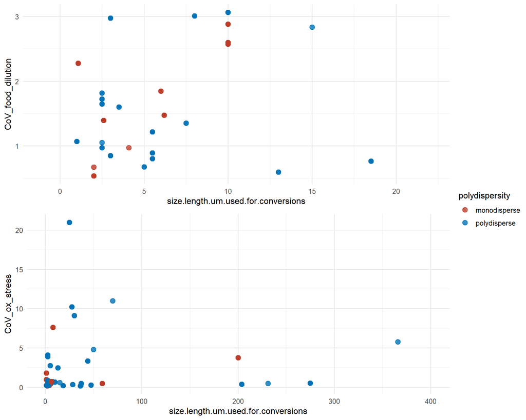

```r
ggarrange(points_cv_food, points_cv_ox,
          nrow = 2,
          common.legend = TRUE, legend = "right")
```

##### 2.3.5.1.2 Statistical Tests

```r
mouth_lm_food <- lm(data = aoc_MC, CoV_food_dilution ~ max.size.ingest.um)

shapiro.test(residuals(mouth_lm_food))
```

```
##
##  Shapiro-Wilk normality test
##
## data:  residuals(mouth_lm_food)
## W = 0.85941, p-value < 2.2e-16
```

```r
summary(mouth_lm_food)
```

```
##
## Call:
## lm(formula = CoV_food_dilution ~ max.size.ingest.um, data = aoc_MC)
##
## Residuals:
##     Min      1Q  Median      3Q     Max
## -0.9741 -0.3925  0.2015  0.3726  1.0445
##
## Coefficients:
##                     Estimate Std. Error t value Pr(>|t|)
## (Intercept)        1.231e+00  3.308e-02   37.21   <2e-16 ***
## max.size.ingest.um 7.453e-04  2.609e-05   28.57   <2e-16 ***
## ---
## Signif. codes:  0 '***' 0.001 '**' 0.01 '*' 0.05 '.' 0.1 ' ' 1
##
## Residual standard error: 0.4477 on 375 degrees of freedom
##   (190 observations deleted due to missingness)
## Multiple R-squared:  0.6852, Adjusted R-squared:  0.6843
## F-statistic: 816.1 on 1 and 375 DF,  p-value: < 2.2e-16
```

```r
# Spearman correlation (for monotonic relationships, non-normal data)
mouth_spearman_food <- cor.test(aoc_MC$CoV_food_dilution, aoc_MC$max.size.ingest.um, method = "spearman")
mouth_spearman_food
```

```
##
##  Spearman's rank correlation rho
##
## data:  aoc_MC$CoV_food_dilution and aoc_MC$max.size.ingest.um
## S = 1339407, p-value < 2.2e-16
## alternative hypothesis: true rho is not equal to 0
## sample estimates:
##       rho
## 0.8500167
```

```r
mouth_lm_ox_stress <- lm(data = aoc_MC,
                         CoV_ox_stress ~ max.size.ingest.um)

shapiro.test(residuals(mouth_lm_ox_stress))
```

```
##
##  Shapiro-Wilk normality test
##
## data:  residuals(mouth_lm_ox_stress)
## W = 0.27973, p-value < 2.2e-16
```

```r
summary(mouth_lm_ox_stress)
```

```
##
## Call:
## lm(formula = CoV_ox_stress ~ max.size.ingest.um, data = aoc_MC)
##
## Residuals:
##     Min      1Q  Median      3Q     Max
## -0.9663 -0.6650 -0.2755 -0.2659 19.8099
##
## Coefficients:
##                      Estimate Std. Error t value Pr(>|t|)
## (Intercept)         1.1463235  0.1684627   6.805 4.02e-11 ***
## max.size.ingest.um -0.0001639  0.0001329  -1.233    0.218
## ---
## Signif. codes:  0 '***' 0.001 '**' 0.01 '*' 0.05 '.' 0.1 ' ' 1
##
## Residual standard error: 2.28 on 375 degrees of freedom
##   (190 observations deleted due to missingness)
## Multiple R-squared:  0.004041,   Adjusted R-squared:  0.001385
## F-statistic: 1.521 on 1 and 375 DF,  p-value: 0.2182
```

Residuals are non-normally distributed, so the spearman correlation test is run instead:

```r
# Spearman correlation (for monotonic relationships, non-normal data)
mouth_spearman_ox_stress <- cor.test(aoc_MC$CoV_ox_stress, aoc_MC$max.size.ingest.um, method = "spearman")
mouth_spearman_ox_stress
```

```
##
##  Spearman's rank correlation rho
##
## data:  aoc_MC$CoV_ox_stress and aoc_MC$max.size.ingest.um
## S = 6560052, p-value = 1.69e-07
## alternative hypothesis: true rho is not equal to 0
## sample estimates:
##       rho
## 0.2654226
```

##### 2.3.5.1.3 CoV vs. Mouth Size

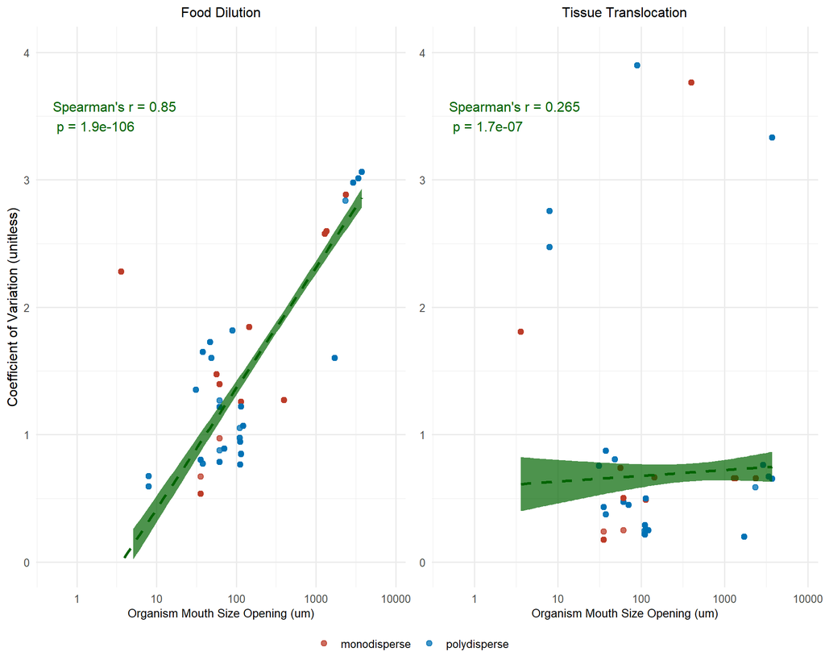

```r
mouth_cv_food <- aoc_MC %>%
    ggplot(aes(y = CoV_food_dilution, x = max.size.ingest.um,
               color = polydispersity,
               text = paste0("Species:", Species, "<br>",
                            "Polydispersity:",  polydispersity, "<br>",
                            "Particles/L Food Dilution:",  signif(particles_L_food_dilution_deterministic,2), "<br>",
                            "Particle size:", signif(size.length.um.used.for.conversions,2), " um<br>",
                            "CoV:", signif(CoV_food_dilution,2), "<br>",
                            "Mouth size opening:", signif(max.size.ingest.um,2), "um"
               )
                 )) +
  geom_point(alpha = 0.75, size = 2.1) +
  geom_smooth(method = "lm", se = T, aes(group = 1), alpha = 0.7, color = "darkgreen", fill = "darkgreen", linetype = "dashed") +
    annotate("text", x = 0.5, y = 3.5,
           label = paste("Spearman's r =", round(mouth_spearman_food$estimate,3),
                         "\n p =", signif(mouth_spearman_food$p.value, 2)),
           hjust = 0, color = "darkgreen") +
  ylab("Coefficient of Variation (unitless)") +
  xlab("Organism Mouth Size Opening (um)") +
  scale_y_log10() +
  scale_x_log10() +
  ylim(c(0,4)) +  # Set x limits
 # xlim(c(0, 10000)) +
  color.type +
  theme_minimal(base_size = 12) +
  theme(legend.position = "none",
        plot.title = element_text(hjust = 0.5,
                                  size = 12),
        axis.title.y = element_text(size = 12),
        axis.title.x = element_text(size = 10)
        ) +
  ggtitle("Food Dilution") +
   guides(fill = guide_legend(title = NULL), color = guide_legend(title = NULL))  # Remove legend titles

mouth_cv_ox <- aoc_MC %>%
  ggplot(aes(y = CoV_ox_stress, x = max.size.ingest.um, color = polydispersity,
             text = paste0("Species:", Species, "<br>",
                            "Polydispersity:",  polydispersity, "<br>",
                            "Particles/L Tissue Trans.:",  signif(particles_L_ox_stress_deterministic,2), "<br>",
                            "Particle size:", signif(size.length.um.used.for.conversions,2), " um<br>",
                            "CoV:", signif(CoV_ox_stress,2), "<br>",
                            "Mouth size opening:", signif(max.size.ingest.um,2), "um"
               ))) +
   geom_point(alpha = 0.75, size = 2.1) +
  annotate("text", x = 0.5, y = 3.5,
           label = paste("Spearman's r =", round(mouth_spearman_ox_stress$estimate,3),
                         "\n p =", signif(mouth_spearman_ox_stress$p.value, 2)),
           hjust = 0, color = "darkgreen") +
  geom_smooth(method = "lm", se = T, aes(group = 1), alpha = 0.7, color = "darkgreen", fill = "darkgreen", linetype = "dashed") +  # A single regression line for all data
  scale_y_log10() +
  scale_x_log10() +
  ylab("Coefficient of Variation (unitless)") +
  xlab("Organism Mouth Size Opening (um)") +
  ylim(c(0,4)) +  # Set x limits
 # xlim(c(0, 10000)) +
  color.type +
  theme_minimal(base_size = 12) +
  theme(legend.position = "none",
        plot.title = element_text(hjust = 0.5,
                                  size = 12),
        axis.title.y = element_blank(),
        axis.title.x = element_text(size = 10)) +
  theme(legend.title = element_blank()) +
  ggtitle("Tissue Translocation") +
   guides(fill = guide_legend(title = NULL), color = guide_legend(title = NULL))  # Remove legend titles

CoV_mouth_plots <- ggarrange(mouth_cv_food, mouth_cv_ox,
                     #  labels = c("Food Dilution", "Tissue Translocation"),
                       ncol = 2,
                       common.legend = TRUE, legend = "bottom")

ggsave(filename = "CoV_mouth_plots.jpg",
       dpi = 300,
       path = "../output/Manuscript_Figs/",
       plot = CoV_mouth_plots, width = 7, height = 5, units = "in")

CoV_mouth_plots
```

```r
# Convert individual ggplots to plotly objects
plot1 <- ggplotly(mouth_cv_food, tooltip = "text")
plot2 <- ggplotly(mouth_cv_ox, tooltip = "text")

# Combine with subplot, setting the legend at the bottom
CoV_mouth_plotly <- subplot(plot1, plot2, nrows = 1, shareY = TRUE, titleX = TRUE, titleY = TRUE) %>%
  layout(legend = list(orientation = "h", y = -0.2))

require(htmlwidgets)

# delete existing plotly files
# unlink("../output/Manuscript_Figs/CoV_mouth_plotly_files", recursive = TRUE)
# Save the plot as an HTML file
saveWidget(CoV_mouth_plotly, file = "../output/Manuscript_Figs/CoV_mouth_plotly.html")

CoV_mouth_plotly
```

[interactive chart not shown]

check to see if any CoV are negative (should not be!)

### 2.3.6 Fiter data

```r
# ensure ssd functions are loaded
source("utils/ssd_functions.R")

freshwater_MC_data <-  filter_environment_data(data = aoc_MC %>%
                                                 rename(particles.mL.ox.stress = particles.mL.ox.stress.x,
                                                        particles.mL.food.dilution = particles.mL.food.dilution.x) %>%
                                                 mutate(translocatable = ifelse(size.length.um.used.for.conversions > x2M_trans,
                                   "not translocatable",
                                   "translocatable")) %>%
    mutate(ingestible = ifelse(size.length.um.used.for.conversions > x2M_ingest,
                               "not ingestible",
                               "ingestible")),
                                              env_filter =  "Freshwater",
                                              upper.tissue.trans.size.um = upper.tissue.trans.size.um,
                                              x1D_set = x1D_set,
                                              x2D_set = x2D_set
                                              )
```

### 2.3.7 Example MC Results

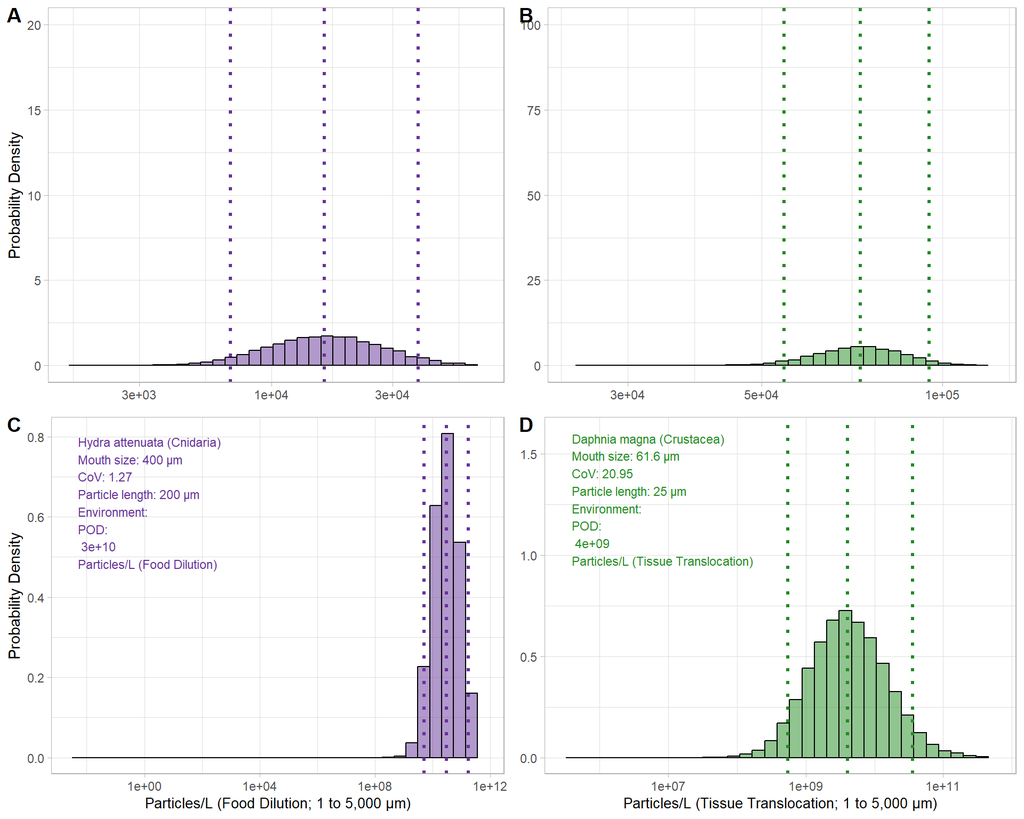

```r
example.df <-  left_join(results_df,
                         aoc_MC %>%
                           mutate(unique_id = as.character(unique_id)) %>%
                           select(c(unique_id,
                     particles_L_food_dilution_deterministic,
                     particles_L_ox_stress_deterministic,
                     environment,
                     CoV_ox_stress, CoV_food_dilution,
                     Species, Group, max.size.ingest.um,
                     size.length.um.used.for.conversions,
                     shape_f,
                     poly_f)),
          by = "unique_id") %>%
  mutate(unique_id = as.character(unique_id))
  #filter(size.length.um.used.for.conversions >= x1D_set)


#get a few rowids to select for plotting
#example.unique_id.ox.stress.max <- example.df.freshwater.tissue %>%
example.unique_id.ox.stress.max <- aoc_MC %>%
   filter(size.length.um.used.for.conversions >= x1D_set,
         particles_L_ox_stress_deterministic > 0
         ) %>%
  arrange(desc(CoV_ox_stress)) %>%
  slice(1) %>%
  pull(unique_id)


#example.unique_id.ox.stress.min <- example.df.freshwater.tissue %>%
example.unique_id.ox.stress.min <- aoc_MC %>%
  filter(size.length.um.used.for.conversions >= x1D_set,
         particles_L_ox_stress_deterministic > 0
         ) %>%
  arrange(CoV_ox_stress) %>%
   slice(1) %>%
  pull(unique_id)

#example.unique_id.food.max <- example.df.freshwater.food %>%
example.unique_id.food.max <- aoc_MC %>%
    filter(Group != "Algae",
           Species == "Hydra attenuata") %>%
    filter(size.length.um.used.for.conversions >= x1D_set,
         particles_L_food_dilution_deterministic > 0
         ) %>%
  arrange(desc(CoV_food_dilution)) %>%
  slice(1) %>%
  pull(unique_id)

#example.unique_id.food.min <- example.df.freshwater.food %>%
example.unique_id.food.min <- aoc_MC %>%
    filter(Group != "Algae") %>%
  filter(size.length.um.used.for.conversions >= x1D_set,
         particles_L_food_dilution_deterministic > 0
         ) %>%
  arrange(CoV_food_dilution) %>%
   slice(1) %>%
  pull(unique_id)


create_ggplot <- function(df_input, unique_id_input, plot_type, metric, metric_label,
                          annotation_x, annotation_y,
                           x_label, color, effect_metric, y_axis_label = TRUE,
                        x_axis_label = T
                        ) {

  # Filter data for the specific plot
  df_example <- df_input %>%
    filter(unique_id == unique_id_input)

  # Check if df_example is empty
  if (nrow(df_example) == 0) {
    message("Warning: No data found for unique_id = ", unique_id_input)
    return(NULL)
  }

  # Extract relevant information for subtitle text box
  example.species <- as.character(df_example$Species[1])
  example.group <- as.character(df_example$Group[1])
  example.particle.length <- comma(df_example$size.length.um.used.for.conversions[1])
  example.max.size.ingest <- round(df_example$max.size.ingest.um[1], 1)
  example.environment <- df_example$environment[1]

  # Determine CoV based on plot_type
  example.CoV <- if (plot_type == "Food") {
    round(df_example$CoV_food_dilution[1], 2)
  } else {
    round(df_example$CoV_ox_stress[1], 2)
  }

  # Calculate percentiles and median for the vertical lines
  median_value <- median(df_example[[metric]], na.rm = TRUE)
  perc_01 <- quantile(df_example[[metric]], 0.001, na.rm = TRUE)
  perc_5 <- quantile(df_example[[metric]], 0.05, na.rm = TRUE)
  perc_95 <- quantile(df_example[[metric]], 0.95, na.rm = TRUE)
  perc_999 <- quantile(df_example[[metric]], 0.999, na.rm = TRUE)

  # Calculate maximum density for y-axis scaling in annotation positioning
  max_density <- max(density(df_example[[metric]], na.rm = TRUE)$y)

   # Calculate symmetric x-limits
  max_distance <- max(median_value - perc_01, perc_999 - median_value)
  lower_limit <- median_value - max_distance
  upper_limit <- median_value + max_distance

  # # Define adjusted x and y positions for annotation to remain within plot bounds
  # annotation_x <- min(df_example[[metric]]) + (max(df_example[[metric]]) - min(df_example[[metric]])) * 0.05
  # annotation_y <- max_density * 0.8  # Position annotation at 80% of max density

  # Plot with raw x-axis data, three vertical lines, and internal subtitle text box
  p <- ggplot(df_example, aes(x = .data[[metric]])) +
    geom_histogram(aes(y = ..density..), fill = color, color = "black", alpha = 0.5, bins = 35) +

    # Median, 5th, and 95th percentile lines
    geom_vline(xintercept = median_value, linetype = "dotted", color = color, linewidth = 1.1) +
    geom_vline(xintercept = perc_5, linetype = "dotted", color = color, linewidth = 1.1) +
    geom_vline(xintercept = perc_95, linetype = "dotted", color = color, linewidth = 1.1) +

    # Annotation positioned using adjusted x and y limits
    annotate("text", x = annotation_x, y = annotation_y,
             label = paste0(example.species, " (", example.group, ")\n",
                            "Mouth size: ", signif(example.max.size.ingest,3), " µm\n",
                            "CoV: ", example.CoV, "\n",
                            "Particle length: ", example.particle.length, " µm\n",
                            "Environment: ", example.environment, "\n",
                            "POD",  ":\n ", scientific(median_value, 2), "\n", metric_label),
             hjust = 0, vjust = 1, color = color, size = 3) +

     # Apply symmetric x-limits
    scale_x_log10(name = x_label,
                  limits = c(lower_limit, upper_limit),
                  labels = scales::label_scientific()) +
    labs(y = if (y_axis_label) "Probability Density" else NULL) +  # Conditional y-axis label
    theme_light() +
    theme(
      plot.title = element_text(size = 12, hjust = 0.5),
      #axis.title.x = element_text(size = 10),
     # axis.text.y = if (!y_axis_label) element_blank() else element_text(),  # Remove y-axis text for right plots
      axis.title.y = if (!y_axis_label) element_blank() else element_text(),
      axis.title.x = if (!x_axis_label) element_blank() else element_text(size = 10)
    )

  return(p)
}







# Generate individual plots, specifying y_axis_label = FALSE for right-hand plots
plot_food_min <- create_ggplot(df_input = example.df,
                               unique_id_input = example.unique_id.food.min,
                               plot_type = "Food",
                               metric = "particles_L_food_dilution",
                               metric_label = "Particles/L (Food Dilution)",
                               x_label = "Particles/L (Food Dilution; 1 to 5,000 μm)",
                               annotation_x = 3.3E7,
                               annotation_y = 20,
                               color = "#663399",
                               effect_metric = aoc_MC$particles_L_food_dilution_deterministic,
                               y_axis_label = TRUE,
                             x_axis_label = F
                             )

plot_food_max <- create_ggplot(df_input = example.df,
                               unique_id_input = example.unique_id.food.max,
                               plot_type = "Food",
                               metric = "particles_L_food_dilution",
                               metric_label = "Particles/L (Food Dilution)",
                               x_label = "Particles/L (Food Dilution; 1 to 5,000 μm)",
                              annotation_x = 5e-3,
                               annotation_y = 0.8,
                               color = "#663399",
                               effect_metric = aoc_MC$particles_L_food_dilution_deterministic,
                               y_axis_label = TRUE)

plot_tissue_min <- create_ggplot(df_input = example.df,
                               unique_id_input = example.unique_id.ox.stress.min,
                               plot_type = "Tissue",
                               metric = "particles_L_ox_stress",
                               metric_label = "Particles/L (Tissue Translocation)",
                               x_label = "Particles/L (Tissue Translocation; 1 to 5,000 μm)",
                               annotation_x = 7.72e7,
                               annotation_y = 100,
                               color = "forestgreen",
                               effect_metric = aoc_MC$particles_L_ox_stress_deterministic,
                               y_axis_label = F,
                             x_axis_label = F
                             )

plot_tissue_max <- create_ggplot(df_input = example.df,
                               unique_id_input = example.unique_id.ox.stress.max,
                               plot_type = "Tissue",
                               metric = "particles_L_ox_stress",
                               metric_label = "Particles/L (Tissue Translocation)",
                               x_label = "Particles/L (Tissue Translocation; 1 to 5,000 μm)",
                               annotation_x = 4e5,
                               annotation_y = 1.6,
                               color = "forestgreen",
                               effect_metric = aoc_MC$particles_L_ox_stress_deterministic,
                               y_axis_label = F)


MC_example_plots <- ggarrange(plot_food_min, plot_tissue_min,
                              plot_food_max, plot_tissue_max,
                              labels = c("A", "B", "C", "D")
                              )

ggsave(filename = "MC_example_plots.jpg",
       dpi = 300,
       path = "../output/Manuscript_Figs/",
       plot = MC_example_plots, width = 9.5, height = 6.5, units = "in")

MC_example_plots
```

#### 2.3.7.1 Filtering for threshold prep

```r
#filter out risk criteria (not done above)#
aoc_risk_paper_MC <- aoc_MC %>%
  drop_na(effect.metric) %>%
   filter(
     tier_zero_tech_f == ("Red Criteria Passed"))  %>%
   mutate(
    ingestible = case_when(
      !is.na(ingestible_poly) ~ ingestible_poly,
      T ~ ingestible),
    translocatable = case_when(
      !is.na(translocatable_poly) ~ translocatable_poly,
      T ~ translocatable))



####---- TISSUE TRANSLOCATION ------#####
filtered.data.small.default_t1.2_MC <- aoc_risk_paper_MC %>%
  filter(translocatable != "not translocatable") %>%
  filter(particles_L_ox_stress_deterministic > 0) %>%
          #mutate(dose_new = particles.L.ox.stress / (af.time * af.noec)) %>% #we should determine if the AFs should be applied, bc I think pSSD does this
         mutate(dose_new_particles_L = mean_particles_L_ox_stress) %>%
         mutate(dose_new_particles_L_sd = sd_particles_L_ox_stress) %>%
         drop_na(dose_new_particles_L) %>%
  filter(size.length.um.used.for.conversions >= x1D_set, # upper size: bioaccessibility labels (partially bioaccessible polydisperse records stay)
         shape_f != "Not Reported",
         poly_f != "Not Reported",
         !environment %in% c("Terrestrial", "Not Reported"),
         Group != "Bacterium",
         Group != "Plant",
         effect.metric != "HONEC")

filtered.data.small.default_t3.4_MC <- filtered.data.small.default_t1.2_MC %>%
 filter(risk.13 != 1,
         bio_f %in% c("Organism", "Population"))

####---- Food Dilution ------#####
filtered.data.large.default_t1.2_MC <- aoc_risk_paper_MC %>%
  filter(particles_L_food_dilution_deterministic > 0) %>%
  filter(ingestible %in% c("ingestible", "ingestible (all)", "ingestible (some)")) %>%
   # remove algae, as food dilution MOE doesn't make sense for algae
  filter(Group != "Algae") %>%
    filter(size.length.um.used.for.conversions >= x1D_set, # upper size: bioaccessibility labels (partially bioaccessible polydisperse records stay)
         poly_f != "Not Reported",
         shape_f != "Not Reported",
         !environment %in% c("Terrestrial", "Not Reported"),
         Group != "Bacterium",
         Group != "Plant",
         effect.metric != "HONEC") %>%
         #mutate(dose_new = particles.L.food.dilution / (af.time * af.noec)) %>%  #we should determine if the AFs should be applied, bc I think pSSD does this
         mutate(dose_new_particles_L = mean_particles_L_food_dilution) %>%
         mutate(dose_new_particles_L_sd = sd_particles_L_food_dilution) %>%
         drop_na(dose_new_particles_L)


filtered.data.large.default_t3.4_MC <- filtered.data.large.default_t1.2_MC %>%
 filter(risk.13 != 1,
         bio_f %in% c("Organism", "Population"))
```

# 3 Probabilistic Species Sensitivity Distribution Plus

### 3.0.1 Data preparatation

The MC Sim dataset prepared in EcoTox_MonteCarlo.Rmd contains aligned tox values for each species/group in the dataset. We can pair these datapoints to their assessement factors for time and effect metric in order to propagate uncertainty associated with that step, as is done in the PSSD. #### Pre-process data for different ERM/Environments/Thresholds

```r
results_df <- readRDS("monte carlo/output/results_df_sobol.rds") %>%
  rename(#poly_f = polymer,
         #shape_f = shape,
         Group = group,
         Species = species
         ) %>%
# global filters for all thresholds
  filter(shape_f != "Not Reported",
          poly_f != "Not Reported",
           Group != "Bacterium",
           Group != "Plant",
           effect.metric != "HONEC") %>%
  mutate(sim_id_numeric  = as.numeric(str_replace(simulation_id, "sim", ""))) #%>%
 # filter(sim_id_numeric < 1001) #just get the first 1,000 sims
#  filter(sim_id_numeric ==1 )

########## food dilution ################
results_df_food <- results_df %>%
  filter(ingestible != "not ingestible",
         particles_L_food_dilution > 0,
         Group != "Algae") %>%
  mutate(dose_new_particles_L = particles_L_food_dilution) %>%
  drop_na(particles_L_food_dilution)

# Tier 3/4
results_df_food_t3_t4 <- results_df_food %>%
  filter(risk.13 != 1, bio_f %in% c("Organism", "Population"))

##### marine food ####
# T1/2
results_df_food_marine <- results_df_food %>%
  filter(environment == "Marine")
# T3/4
results_df_food_t3_t4_marine <- results_df_food_t3_t4 %>%
  filter(environment == "Marine")

##### freshwater food ####
# T1/2
results_df_food_freshwater <- results_df_food %>%
  filter(environment == "Freshwater")

# T3/4
results_df_food_t3_t4_freshwater <- results_df_food_t3_t4 %>%
  filter(environment == "Freshwater")


########## Tissue Translocation ################
results_df_tissue <- results_df %>%
  filter(translocatable != "not translocatable",
         particles_L_ox_stress > 0) %>%
  mutate(dose_new_particles_L = particles_L_ox_stress) %>%
  drop_na(particles_L_ox_stress)

# Tier 3/4
results_df_tissue_t3_t4 <- results_df_tissue %>%
  filter(risk.13 != 1, bio_f %in% c("Organism", "Population"))

##### marine tissue ####
# T1/2
results_df_tissue_marine <- results_df_tissue %>%
  filter(environment == "Marine")
# T3/4
results_df_tissue_t3_t4_marine <- results_df_tissue_t3_t4 %>%
  filter(environment == "Marine")

##### freshwater tissue ####
# T1/2
results_df_tissue_freshwater <- results_df_tissue %>%
  filter(environment == "Freshwater")

# T3/4
results_df_tissue_t3_t4_freshwater <- results_df_tissue_t3_t4 %>%
  filter(environment == "Freshwater")

names(results_df)
```

```
##  [1] "simulation_id"             "unique_id"
##  [3] "particles_L_ox_stress"     "particles_L_food_dilution"
##  [5] "Species"                   "Group"
##  [7] "shape_f"                   "poly_f"
##  [9] "environment"               "effect.metric"
## [11] "bio_f"                     "risk.13"
## [13] "af.time"                   "af.noec"
## [15] "ingestible"                "ingestible_poly"
## [17] "translocatable"            "translocatable_poly"
## [19] "sim_id_numeric"
```

## 3.1 Summarize datasets

```r
### count unique studies, datapoints, and species
#function
summarize_distinct <- function(data, name) {
  summary <- data %>%
    summarize(
      Count_Distinct_Species = n_distinct(Species),
      Count_Distinct_doi = n_distinct(doi),
      Count_Distinct_dp = n_distinct(dose_new_particles_L),
      Count_Distinct_group = n_distinct(Group)
    ) %>%
    mutate(Dataset = name)  # Adding a column to identify the dataframe
  return(summary)
}


tier1_2_food <- readRDS("../data/output/tier1_2_food.RDS")
tier3_4_food <- readRDS("../data/output/tier3_4_food.RDS")
tier1_2_tissue <- readRDS("../data/output/tier1_2_tissue.RDS")
tier3_4_tissue <- readRDS("../data/output/tier3_4_tissue.RDS")
#application
tier1_2_food_summary <- summarize_distinct(tier1_2_food, "Tier 1-2 Food")
tier3_4_food_summary <- summarize_distinct(tier3_4_food, "Tier 3-4 Food")
tier1_2_tissue_summary <- summarize_distinct(tier1_2_tissue, "Tier 1-2 Tissue")
tier3_4_tissue_summary <- summarize_distinct(tier3_4_tissue, "Tier 3-4 Tissue")

tier1_2_food_summary_OG <- summarize_distinct(tier1_2_food %>% filter(source != "ToMEx 2.0"), "Tier 1-2 Food - ToMEx 1")
tier3_4_food_summary_OG <- summarize_distinct(tier3_4_food %>% filter(source != "ToMEx 2.0"), "Tier 3-4 Food - ToMEx 1")
tier1_2_tissue_summary_OG <- summarize_distinct(tier1_2_tissue %>% filter(source != "ToMEx 2.0"),"Tier 1-2 Tissue - ToMEx 1")
tier3_4_tissue_summary_OG <- summarize_distinct(tier3_4_tissue %>% filter(source != "ToMEx 2.0"), "Tier 3-4 Tissue - ToMEx 1")

#combine into single dataframe
final_summary <- bind_rows(tier1_2_food_summary, tier3_4_food_summary,
                           tier1_2_tissue_summary, tier3_4_tissue_summary,
                           tier1_2_food_summary_OG, tier3_4_food_summary_OG,
                           tier1_2_tissue_summary_OG, tier3_4_tissue_summary_OG,)

#display
print(final_summary)
```

```
##   Count_Distinct_Species Count_Distinct_doi Count_Distinct_dp
## 1                     22                 25               119
## 2                     20                 22               100
## 3                     25                 28               125
## 4                     20                 22                96
## 5                     15                 16                88
## 6                     15                 16                83
## 7                     17                 18                90
## 8                     15                 16                79
##   Count_Distinct_group                   Dataset
## 1                    7             Tier 1-2 Food
## 2                    7             Tier 3-4 Food
## 3                    7           Tier 1-2 Tissue
## 4                    7           Tier 3-4 Tissue
## 5                    6   Tier 1-2 Food - ToMEx 1
## 6                    6   Tier 3-4 Food - ToMEx 1
## 7                    6 Tier 1-2 Tissue - ToMEx 1
## 8                    6 Tier 3-4 Tissue - ToMEx 1
```

## 3.2 Functions

### 3.2.1 Data Preparation

```r
#FUnction to process data
# prep_data() function scripted in utils/functions.R
# #example usage
tier1_2_food_matrices <- prep_data(results_df_food_marine)
```

### 3.2.2 Run PSSD

```r
# prepare_plot_data function scripted in utils/functions.R

# Example usage
tier1_2_food_plot_prep <- prepare_plot_data(original_data = results_df_food_marine,
                                            pSSD = tier1_2_food_pssd$pSSD,
                                            data_matrices = tier1_2_food_matrices,
                                            species_data_source = aoc_final,
                                            debug = FALSE
                                            )
tier1_2_food_plot_prep
```

```
## $quantiles_df
## # A tibble: 15,001 × 8
##       iv   min    max   q05   q95   q25   q75    mean
##    <dbl> <dbl>  <dbl> <dbl> <dbl> <dbl> <dbl>   <dbl>
##  1 -5        0 0.0714     0     0     0     0 0.00214
##  2 -5.00     0 0.0714     0     0     0     0 0.00214
##  3 -5.00     0 0.0714     0     0     0     0 0.00214
##  4 -5.00     0 0.0714     0     0     0     0 0.00214
##  5 -5.00     0 0.0714     0     0     0     0 0.00214
##  6 -5.00     0 0.0714     0     0     0     0 0.00214
##  7 -4.99     0 0.0714     0     0     0     0 0.00214
##  8 -4.99     0 0.0714     0     0     0     0 0.00214
##  9 -4.99     0 0.0714     0     0     0     0 0.00214
## 10 -4.99     0 0.0714     0     0     0     0 0.00214
## # ℹ 14,991 more rows
```

[output cut: 51 more lines]

#### 3.2.2.1 PSSD ggplot Function

[output not shown]

```
##     ✅ Stage OK: scales_theme
## ✅ pSSD_plot_fnx() finished for UNKNOWN
```

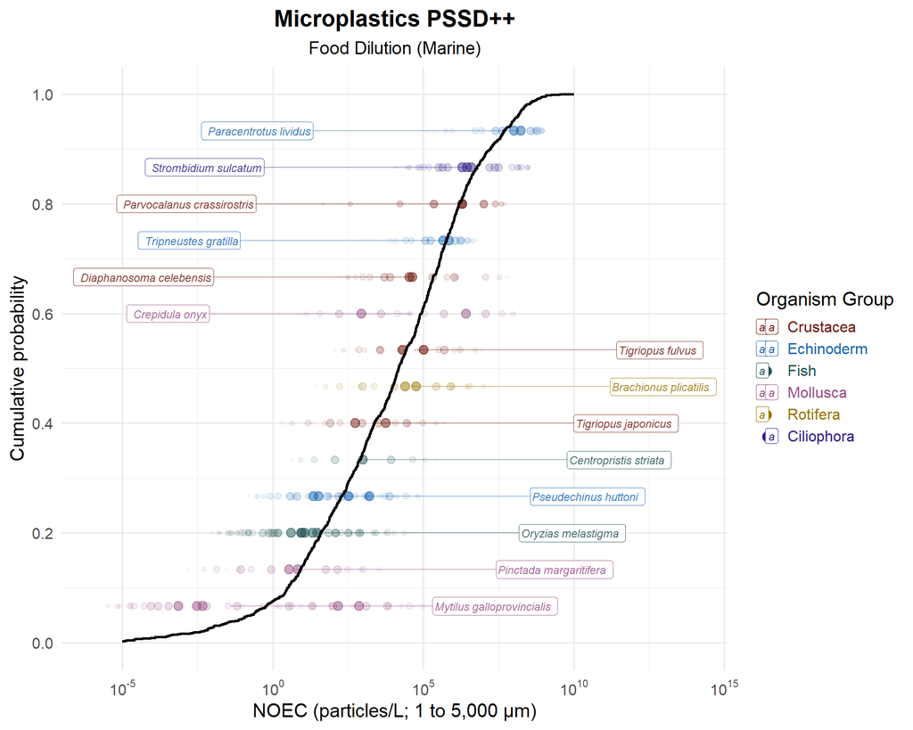

```r
# generate_color_palette function and pSSD_plot_fnx functions scripted in utils/functions.R

# # example usage
all_species <- tier1_2_food_plot_prep$species_data %>%
  distinct(Species, Group, environment) %>%
  arrange(environment, Group, Species)

# Generate a consistent color palette
test_color_palette <- generate_color_palette(all_species)

#beepr::beep(2)

pSSD_plot_fnx(quantiles_df = tier1_2_food_plot_prep$quantiles_df,
          species_data = tier1_2_food_plot_prep$species_data,
          all_NOEC = tier1_2_food_plot_prep$all_NOEC,
          ERM_name = "Food Dilution",
          environment_name = "Marine",
          color_palette = test_color_palette,
          debug = TRUE #optional debugging
          )
```

#### 3.2.2.2 PNEC ggplot Function

```r
# make_PNEC_plot function scripted in utils/functions.R

# #example
# make_PNEC_plot(pssd_results = tier1_2_food_pssd,
#            hcx = 0.05,
#           data_name = "Tier 2 (Food Dilution)")
```

#### 3.2.2.3 PNEC Data Summary

```r
# PNEC_data_summary function scripted in utils/functions.R

# ## example
# tier1_2_food_PNEC <- PNEC_data_summary(pssd_results = tier1_2_food_pssd,
#                                        hcx = 0.05,
#                                        data_name = "Tier 2 (Food Dilution)")
#
# tier1_2_food_PNEC$df
# tier1_2_food_PNEC$stats
```

## 3.3 PSSD++ (using every MC sim aligned tox value as a data point)

The following code attempts to more accurately represent the uncertainty of the alignments through the PSSD by using a distribution of aligned tox values as the data matrix, instead of using a CoV value (which necessarily requires the assumption of a distribution).

Prepare color palette for species

```r
all_species <- results_df %>%
  filter(environment %in% c("Freshwater", "Marine"),
         !Group %in% c("Insect", "Annelida") #not used in this analysis
         ) %>%
  distinct(Species, Group, environment) %>%
  droplevels() %>%
  arrange(environment, Group, Species)

# Generate a consistent color palette
global_color_palette <- generate_color_palette(all_species)

legend_labels <- setNames(
  paste0("<span style='color:", global_color_palette, "'>", names(global_color_palette), "</span>"),
  names(global_color_palette)
)

global_color_palette
```

```
##      Algae   Cnidaria  Crustacea       Fish   Mollusca Echinoderm   Rotifera
##  "#72190E"  "#1965B0"  "#225555"  "#994F88"  "#997700"  "#332288"  "#666633"
## Ciliophora
##  "#663333"
```